# PIC-tutor v0.45

本轮对官方 `test_3d_particle_boundaries` 做了 2-rank 复现，官方 `analysis.py` 以 exit code `0` 结束；独立脚本进一步从初末态按粒子 ID 排序并回代自由飞行轨迹。reflecting 粒子的镜像位置最大绝对误差为 `0`、速度反号归一化误差为 `0`；periodic 粒子的位置回绕最大绝对误差为 `4.4409e-16`、速度保持误差为 `0`；absorbing species 从初始 `3` 个粒子变为最终保留的 `1` 个保底粒子。报告归档于 `runs/stage-c-validation/particle_boundaries_mpi2/contract.{json,md}`。这条证据覆盖的是 domain boundary kernel 的解析几何合同，不等同于 EB scraping 或 transition-zone route-count 验证。

RZ PICMI 镜面反射 case 也已完成真实 Python-enabled WarpX 2-rank 复现。此前 `build_full` 的 `WarpX_PYTHON=OFF` 只允许记录环境边界；本轮使用现有 `build_py` 配置完成 `WarpX_PYTHON=ON`、RZ pybind bindings 和 `amrex.space2d` import smoke test，再运行 `inputs_test_rz_particle_boundary_interaction_picmi.py`。官方 `analysis.py` 与独立脚本均通过：末态数值坐标为 `(x,y,z)=(0.03307856,0,-0.20299489)`，解析镜面反射坐标为 `(0.03321447,0,-0.20668779)`，x/z 相对误差分别为 `0.4092%` 和 `1.7867%`。这条证据直接闭合了“EB buffer -> Python after-step callback -> 法向镜像 -> 剩余 `dt-delta_t` 重注入”的运行链；运行时依赖、Python-enabled build 和报告归档于 `runs/stage-c-validation/particle_boundary_interaction_rz_mpi2/`。

同一 Python-enabled build 还完成了 `test_2d_particle_reflection_picmi` 的 1-rank 运行。官方输入脚本在 `sim.step(10)` 后直接通过 `ParticleBoundaryBufferWrapper` 断言：`z_hi` buffer 有 `63` 个粒子且每个 `stepScraped=4`，`z_lo` buffer 有 `67` 个粒子且每个 `stepScraped=8`；脚本以 exit code `0` 结束。由于上游 CMake 对这条路径保持 `analysis=OFF`，这里的强证据是 input-level Python assertion，不能把 final plotfile checksum 误写成同等级的解析物理 analysis。报告归档于 `runs/stage-c-validation/particle_reflection_picmi_2d/contract.{json,md}`。

官方 `test_rz_flux_injection_from_eb` 也已完成当前 checkout 的 2-rank 复现。上游 analysis 检查总注入量、EB 外侧位置和法向/两切向速度分布，全部通过；独立 reader-side contract 从同一末态 plotfile 重新计算，得到 `75347` 个电子宏粒子、总权重相对误差 `0.2156% < 1%`、最小 `r/R=0.997896 > 0.98`，三组加权 histogram 的 residual 也分别低于上游阈值。该证据闭合的是“sphere EB surface emission -> RZ particle reconstruction -> distribution/weight consumer”组合链，不等同于 secondary-emission callback 或 transition-zone route-count 证明。报告归档于 `runs/stage-c-validation/rz_flux_injection_from_eb_mpi2/contract.{json,md}`。

同一 `flux_injection_from_eb` family 的 3D sibling 也已用 2-rank producer 复现。官方 analysis 与独立 `scripts/analyze_3d_flux_injection_from_eb_contract.py` 均通过：`801308` 个电子宏粒子、总权重相对误差 `0.3655% < 1%`、最小 `r/R=0.996380 > 0.98`，法向和两条切向速度 histogram 均低于对应阈值。RZ 和 3D 两条结果共同支持 sphere EB surface-emission 的权重/几何/分布组合合同，但不等同于粒子边界 buffer route-count 验证。报告归档于 `runs/stage-c-validation/3d_flux_injection_from_eb_mpi2/contract.{json,md}`。

2D cylinder sibling 随后也完成 2-rank 复现。官方 analysis 与独立 `scripts/analyze_2d_flux_injection_from_eb_contract.py` 均通过：`50235` 个电子宏粒子、总权重相对误差 `0.0606% < 1%`、最小 `r/R=0.998653 > 0.98`，法向和两条切向速度 histogram 均通过。至此 `flux_injection_from_eb` 的 RZ sphere、3D sphere 和 2D cylinder 三条几何路径都有同等级的 producer/analysis/reader-side 证据；这仍不等同于 transition-zone route-count 或 secondary-emission callback 证明。报告归档于 `runs/stage-c-validation/2d_flux_injection_from_eb_mpi2/contract.{json,md}`。

官方 `test_rz_spacecraft_charging_picmi` 也已完成 Python-enabled 2-rank 复现。1000 步 producer 通过 `ParticleBoundaryBufferWrapper` 跨 species 汇总 EB 收集电荷，并在 `afterEsolve` callback 中修正场、更新 `set_potential_on_eb`；官方 `analysis.py` 和独立 `scripts/analyze_spacecraft_charging_contract.py` 对同一 `101` 个 openPMD 时间样本拟合出 `v0=-145.9723`、`tau=3.63045e-6 s`，相对参考误差分别为 `3.551%` 和 `16.561%`，均在 gate 内。该证据支持当前 charging callback/application workflow 的组合合同，不等同于长期浮动电势收敛或一般 EB route-count 证明。报告归档于 `runs/stage-c-validation/spacecraft_charging_rz_mpi2/contract.{json,md}`。

RZ Silver–Mueller 开放边界也已完成官方 2-rank 复现。500 步 Yee/RZ 激光脉冲 producer 后，官方 `analysis.py` 与独立 `scripts/analyze_rz_silver_mueller_contract.py` 都检查末态 covering grid 的 `Er/Et/Ez`；最大绝对值分别为 `6.690e-3`、`3.043e-3`、`8.990e-4 V/m`，均低于 `0.01 V/m`。这条证据支撑的是 RZ Silver–Mueller field boundary 的短时低残余场合同，不替代 PML 反射率、长期吸收效率或不同入射角的系统扫描。报告归档于 `runs/stage-c-validation/rz_silver_mueller_z_mpi2/contract.{json,md}`。

Cartesian 2D x 向 sibling 也已完成官方 2-rank、500 步复现。官方 `silver_mueller/analysis.py` 与独立 `scripts/analyze_silver_mueller_cartesian_contract.py` 在 `diag1000500` 上均通过：`max|Ex|=9.1492743e-4`、`max|Ey|=3.5158070e-3`、`max|Ez|=3.9117365e-3 V/m`，最大值 `3.9117365e-3 < 0.01 V/m`。这条结果把同一短时残余场合同扩展到 Cartesian x 向双侧开放边界；仍不替代 2D z 向、1D sibling 的逐一复现，也不等同于长期反射率或入射角扫描。报告归档于 `runs/stage-c-validation/silver_mueller_2d_x_mpi2/contract.{json,md}`。

Cartesian 2D z 向 sibling 随后按同一 2-rank、500 步配置完成复现。官方 analysis 与独立 contract 均通过：`max|Ex|=3.9117365e-3`、`max|Ey|=3.5158069e-3`、`max|Ez|=9.1492744e-4 V/m`，最大值 `3.9117365e-3 < 0.01 V/m`。x/z 两个 case 的分量峰值呈置换对称，说明当前短时 residual-field consumer 对法向方向切换保持一致；这仍不是长期反射率、不同入射角或 1D sibling 的系统扫描。报告归档于 `runs/stage-c-validation/silver_mueller_2d_z_mpi2/contract.{json,md}`。

Cartesian 1D sibling 也完成了官方 2-rank、500 步复现。官方 `silver_mueller/analysis.py` 与同一独立 Cartesian contract 在 `diag1000500` 上均通过：`max|Ex|=3.8865209e-8`、`max|Ey|=3.8865209e-8`、`max|Ez|=0 V/m`，最大值远低于 `0.01 V/m`。至此 1D、2D x/z 与 RZ 都有同一量纲阈值下的短时 residual-field evidence；这仍不等于长期吸收效率或角度/频率扫描。报告归档于 `runs/stage-c-validation/silver_mueller_1d_mpi2/contract.{json,md}`。

3D PEC field sibling 也已完成 2-rank 复现。官方 `analysis_pec.py` 与独立 `scripts/analyze_3d_pec_field_contract.py` 在 `diag1000125` 上均通过：`Ey_max=1.988811e5 V/m`、`Ey_min=-1.987356e5 V/m`，相对理论 `+/-2e5 V/m` 的误差为 `0.559%/0.632%`。独立脚本另外记录 z 两端 cell-centered field 的边界最大值，但不把它当成额外 pass gate，因为上游合同实际检查的是站波振幅。该证据支撑的是 3D Yee + PEC 反射组合，不等同于 PEC 粒子 gather/deposition 或 PECInsulator implicit 能量合同。报告归档于 `runs/stage-c-validation/pec_field_3d_mpi2/contract.{json,md}`。

PEC+MR sibling 随后完成 2-rank 复现。官方 `analysis_pec_mr.py` 与独立 `scripts/analyze_3d_pec_field_mr_contract.py` 均通过：两层 AMR 的 `Ey_max=1.917992e5 V/m`、`Ey_min=-1.928917e5 V/m`，相对 `+/-2e5 V/m` 的误差为 `4.100%/3.554%`，在上游放宽后的 `5%` gate 内。producer 同时报告 `Projection Div Cleaner` 只清理 first AMR level 的 warning；本书把它保留为实现适用边界，不将其误写成 PEC reflection analysis 失败。报告归档于 `runs/stage-c-validation/pec_field_mr_3d_mpi2/contract.{json,md}`。

PMC sibling 也已完成 2-rank 复现。官方 `analysis_pec.py` 与独立 `scripts/analyze_3d_pmc_field_contract.py` 在 `diag1000134` 上均通过：`Ey_max=1.987693e5 V/m`、`Ey_min=-1.986197e5 V/m`，相对 `+/-2e5 V/m` 的误差为 `0.615%/0.690%`。这条结果说明当前 PMC 配置下同一 standing-wave amplitude consumer 处于官方 gate 内；由于上游 analysis 不直接断言独立磁场边界分量，本书不把它升级为完整 PMC 分量级证明。报告归档于 `runs/stage-c-validation/pmc_field_3d_mpi2/contract.{json,md}`。

2D PECInsulator implicit case 也已完成 2-rank 复现。官方 `analysis_pec_insulator_implicit.py` 与独立 `scripts/analyze_pec_insulator_implicit_contract.py` 从 `diags/reducedfiles/fieldenergy.txt` 和 `poyntingflux.txt` 重建同一能量账本，21 个样本的最大归一化差为 `1.2678e-15`，通过 `1e-13` gate。该证据支持“局部 PECInsulator 边界注入的场能由 Poynting flux 精确闭合”的当前隐式短时合同，不等同于 restart continuation、长期稳定性或一般 PEC field amplitude 证明。报告归档于 `runs/stage-c-validation/pec_insulator_implicit_2d_mpi2/contract.{json,md}`。

对应的 restart sibling 也已从 `chk000010` 接续完成 2-rank 运行。官方 analysis 与独立 contract 对 continuation 的 10 个 ledger 样本均通过，场能从 `3.633236e-5` 延续到 `8.551785e-5 J`，最大归一化能量差仍为 `1.2678e-15`。这条证据支持 checkpoint 恢复后 PECInsulator implicit energy/Poynting ledger 的连续性，但不替代完整 restart 前后逐字段一致性审计。报告归档于 `runs/stage-c-validation/pec_insulator_implicit_restart_2d_mpi2/contract.{json,md}`。

同一 Python-enabled build 还运行了官方 `test_rz_secondary_ion_emission_picmi`。producer 正常完成 3 步并在最终 openPMD iteration 生成 `2` 个电子，说明 `ParticleBoundaryBufferWrapper` 到 Python secondary-emission callback 的调用链已被触发；但官方 `analysis.py` 和独立 `scripts/analyze_rz_secondary_ion_emission_contract.py` 都拒绝几何 gate：第一个电子回溯到最近离子 impact point 的相对距离为 `3.6038%`，超过 `2%`，第二个为 `0.8237%`。隔离 debug 输入进一步显示，失败 parent ion 的 EB buffer 交点在电子回溯前已经相对解析球面交点偏离约 `3.1%` 半径，当前网格为 `dr=0.03125`、`dz=0.0625`、球半径 `0.2`。因此本书把这条记录为“producer/count 通过、EB impact-point geometry 失败”的负向证据，不把它升级为 secondary-emission 物理验证。报告归档于 `runs/stage-c-validation/secondary_ion_emission_rz/contract.{json,md}`，诊断归档于同目录 `geometry-diagnosis.md`；后续需要先解释当前 checkout 与官方 tolerance 的偏差，再决定是否修复测试输入、构建版本或实现路径。

为区分实现错误与网格分辨率效应，又在不修改上游输入的前提下把同一 RZ PICMI case 的 `nr/nz` 从 `64/64` 提高到 `128/128`。官方 analysis 与独立 contract 均通过：两个电子的最大回溯相对误差降为 `0.9977% < 2%`，相对 64×64 基线的最大误差下降约 `3.61` 倍。该对照支持“当前失败主要受 EB 交点离散分辨率控制”的诊断，但不能把 64×64 baseline 改写成通过，也不能替代对默认测试分辨率和上游容差的正式决策。对照报告归档于 `runs/stage-c-validation/secondary_ion_emission_rz_resolution/resolution-comparison.{json,md}`。

再增加 `256x256` 后，最大回溯相对误差为 `0.6646%`，官方和独立 gate 继续通过；三档结果为 `64x64: 3.6038%`、`128x128: 0.9977%`、`256x256: 0.6646%`。相邻分辨率的经验误差阶约为 `1.85` 和 `0.59`，这里只作为描述性趋势，不能包装成正式 convergence order：样本只有三档，且粒子事件、callback 和分析容差均未改变。趋势报告归档于 `runs/stage-c-validation/secondary_ion_emission_rz_resolution/resolution-trend.{json,md}`。

thermal boundary 也已完成官方 2-rank、2000 步复现。官方 `analysis.py` 和独立 reduced-ledger 脚本均通过：`EF/EN` 各有 `201` 个样本，按上游语义以第 10 步场能作为参考，末态场能比值为 `9.0906979`、末态场能 `9.8450169e-6 < 5e-5`，粒子能从 `0.0138667572` 变为 `0.0141029132`，相对漂移 `1.7030369% < 2%`。这支持“当前短时 thermal boundary workflow 的能量注入处于官方 gate 内”，不支持“系统已达到热平衡”或“长期统计收敛”。报告归档于 `runs/stage-c-validation/particle_thermal_boundary_mpi2/contract.{json,md}`。

同一轮还运行了 `particle_boundary_process` 的 3D absorption 分支。当前 checkout 的 2-rank producer 与官方 `analysis_absorption.py` 均以 exit code `0` 结束，step 40 保留 `612` 个电子，step 60 主容器为 `0`。它与前面的 `particle_boundary_scrape` 使用相同的 cubic EB 粒子推进几何，但把 domain field boundary 固定为 PEC，因此本书将其作为“PEC 场边界 + EB 吸收”的组合 workflow 单独记录，而不把两个 case 合并成一个更强的单项物理结论。运行目录为 `runs/stage-c-validation/particle_boundary_process_absorption_mpi2/`。

此外，官方 `test_1d_particle_absorbing_boundary` 已用当前重建 binary 完成 1-rank、8000 步复现，官方 `analysis.py` 通过。独立脚本从实际生成的 `warpx_used_inputs` 读取 `ParticleHistogram2D` bin 定义，再计算末态 `iteration=8000` 的关注窗口 `z=[0,50] um`、`uz=[-5,-1]`；输出 shape 为 `1000x1000`，选择 bin 为 `uz=[250,317), z=[667,1000)`，尾部总权重 `2.1509559e20 < 3.2e20`。这条证据支持 thermalizer 对指定反向高速电子尾部的短时压制，不等于完整 Maxwellian 分布或长期热化收敛证明。报告归档于 `runs/stage-c-validation/particle_absorbing_boundary_1d/contract.{json,md}`。

本轮又对官方 `test_3d_particle_scrape` 做了当前 checkout 的 2-rank 复现。producer 和官方 `analysis_scrape.py` 均以 exit code `0` 结束；独立 reader-side 脚本 `scripts/analyze_particle_scrape_contract.py` 进一步读取 `diag1000020/40/60`，得到电子数 `612/612/0`，第 20 到 40 步总宏粒子权重相对差 `0.0`，第 40 步 `z_max=-8.6943652e-5 m` 仍低于 EB 下边界 `-8.65e-5 m`，且所有粒子仍在 domain 内。该证据把“中间态未撞击、预撞击权重不变、末态主容器为空”收成一条可重放的时间序列合同，但由于该官方 case 没有把 scraped buffer 作为独立 plotfile species 暴露出来，不能升级为 scraped particle ID 集合守恒证明。报告归档于 `runs/stage-c-validation/particle_boundary_scrape_mpi2/contract.{json,md}`。

官方 `test_2d_particles_in_pml` 也已按当前 checkout 的 2-rank 配置完成 180 步复现。输入打开 `warpx.pml_has_particles=1`、`warpx.do_pml_in_domain=1` 和 `warpx.do_pml_j_damping=1`，两个反向运动的单粒子在域内 PML 中被吸收；官方 `analysis_particles_in_pml.py` 在 `diag1000180` 上给出 `max_Efield=2.5542538436684726e-4`，通过 2D 单层 `<3e-4` 的残余场 gate。独立脚本 `scripts/analyze_particles_in_pml_contract.py` 不复用上游脚本的有符号 `max(Ex,Ey,Ez)`，而是对 `Ex/Ey/Ez` 分别取绝对值最大，得到 `max|Ex|=2.5542538436684726e-4`、`max|Ey|=0`、`max|Ez|=1.225051864499787e-4`，同样通过。该证据直接支持“粒子进入 PML 后，PML current damping 与 split-field 更新没有在主域留下超阈值残余电场”的当前 2D 单层合同；不等同于 3D/AMR sibling、粒子轨迹逐粒子守恒或 upstream checksum benchmark。

对应的 3D 单层输入也已完成 2-rank、120 步复现。官方 analysis 给出 `max_Efield=4.325973103094924 < 10`，扩展后的独立 contract 在 `128x64x64` finest covering grid 上得到 `max|Ex|=4.325973103094924`、`max|Ey|=1.9812378771324655`、`max|Ez|=1.9812378771325192`，同样通过。这里仍然验证的是粒子离开域后主域残余场，而不是粒子逐轨迹或 PML 反射率。

3D AMR sibling 的结果需要单独保留判据边界。官方 `test_3d_particles_in_pml_mr` 运行 200 步、两层 AMR 后，官方脚本按有符号 `max(Ex,Ey,Ez)` 得到 `106.43539539129057 < 110` 并通过；但同一 `256x256x256` finest covering grid 上，独立绝对值 contract 得到 `Ex_min=-110.3993781372607`、`Ex_max=106.43539539129057`，所以 `max|E|=110.3993781372607 > 110`。这说明当前上游 consumer 对负向峰值不敏感，不能把“官方 gate 通过”直接升级成全场残余场强合同；本书将 AMR sibling 记为可运行、官方判据通过但强化审计失败的边界证据，后续再决定是否需要上游 analysis 修正或专门的 AMR 容差解释。

PEC 粒子 case 原本只有 checksum consumer；本轮用同一官方输入复制出一个仅将 `boundary.field_lo/hi` 从 `pec periodic periodic` 改为 `periodic periodic periodic` 的 local control，并以 2 ranks 运行到 step 20。独立脚本 `scripts/analyze_pec_particle_contract.py` 比较两个末态 plotfile：PEC 的全场 `max|E|=4.459437205311129 V/m`，periodic control 为 `632.622746012735 V/m`，比值 `0.0070491<0.01`；切向 `Ey` 的比值为 `0.0022796<0.01`。electron/proton 各保留 1 个，末态位置和动量差的最大绝对值为 `8.94e-18`，说明对照主要改变的是近边界场，而不是粒子推进状态。该合同提升了原 checksum-only case 的可解释性，但由于 plotfile 不暴露粒子 gather 时刻的局部 `E` 样本，仍不应写成直接的 gather/deposition kernel 证明。报告归档于 `runs/stage-c-validation/pec_particle_3d_mpi2/contract.{json,md}`，periodic control 输入和报告在同级 `pec_particle_3d_periodic_control/`。

显式 `PECInsulator` baseline 也已完成当前 checkout 的 2-rank、10 步复现。输入在 `x_hi` 边界只对 `2.25e-2 <= z <= 2.75e-2` 的局部段施加 `By_x_hi(y,z,t)`，并在 `x_lo` 使用 Neumann、z 方向使用 periodic。官方 CMake 没有 analysis，独立脚本 `scripts/analyze_pec_insulator_explicit_contract.py` 从初末两个 plotfile 直接读取场：初态六个 E/B 分量全为零；末态 `By` 在上边界 active 的 16 个 cell-centered z 单元中最大为 `3.249284802456277e-3`，相对 ramp 饱和值 `3.3e-3` 的误差为 `1.5368%`，低于 `5%` gate；下边界对应行 `max|By|=0`。该证据支撑的是显式局部 PECInsulator boundary-drive 的空间定位和幅值响应，不是 implicit case 中 `FieldEnergy + PoyntingFlux` 的机器精度能量闭合；两者必须分开引用。报告归档于 `runs/stage-c-validation/pec_insulator_explicit_2d_mpi2/contract.{json,md}`。

### 7.5.2 v0.10 四条强 analysis 路径的正文化

第一条强路径是 `boundaries/inputs_test_3d_particle_boundaries` 对粒子 domain boundary 的闭合检查。输入卡把几何盒设为 `[-1,1]^3`，并故意把三类粒子边界拆到三个方向：`x` 方向 reflecting，`y` 方向 absorbing，`z` 方向 periodic。`analysis.py` 不是只看最终 plotfile checksum，而是同时读取初始 `diag1000000` 和最终 `diag1000008`，先从初态粒子位置、动量和相对论速度外推自由飞行轨道，再分别套用镜像、删除和周期回绕规则。最终断言也对应三种语义：absorbing 分支只剩一个没有越界的保底粒子；reflecting 分支的速度符号反转并且位置满足

$$x_{\mathrm{after}} = 2 x_{\min/\max} - x_{\mathrm{free}},$$

periodic 分支的速度保持不变，位置按盒长回绕；两个位置误差都要求小于 `1e-15`。这条 regression 因而直接覆盖 `ParticleBoundaries_K.H::apply_boundary()` 中 `Absorbing -> particle_lost`、`Reflecting -> mirror + change_sign_u` 和周期边界由 AMReX geometry 处理后的最终轨道结果。写作时可以把它作为 domain particle boundary 的最小物理合同：不是“边界参数被解析了”，而是越界粒子的生死、镜像和回绕都被解析轨道重新计算过。

第二条强路径是 `pec/analysis_pec.py` 和 `pec/analysis_pec_mr.py` 对 PEC/PMC 场反射的站波振幅检查。输入卡发射一个正弦波打到物理边界；脚本在反射后读取 `Ey`，把理论阈值设为 `E_th = 2 E_in`，然后分别比较 `Ey_max` 与 `+E_th`、`Ey_min` 与 `-E_th`。单层 3D PEC/PMC 的容差是 `1%`，MR 版本在 level-0 covering grid 上放宽到 `5%`。这个判据的要点是，它并不把“边界类型字符串为 pec/pmc”当作结论，而是要求反射波和入射波叠加出正确的站波振幅。源码上，`WarpXFieldBoundaries.cpp` 会把 PEC/PMC 映射到 `PEC::ApplyPECtoEfield()` 与 `PEC::ApplyPECtoBfield()` 的不同角色组合：PEC 对切向电场施加导体边界，PMC 则通过 E/B 角色互换实现磁导体边界。MR 路径额外说明同一物理合同在 coarse/fine patch 和物理边界同时存在时仍能保持到较宽容差内。

第三条强路径是 `particles_in_pml/analysis_particles_in_pml.py`。这组输入卡打开 `warpx.pml_has_particles=1`、`warpx.do_pml_in_domain=1` 和 `warpx.do_pml_j_damping=1`，让一对带相反电荷、相反动量的粒子从中心向两侧穿出。脚本不检查粒子本身是否存在于 PML，而是在粒子离开后读取 finest level covering grid，取

$$\max(E_x, E_y, E_z)$$

作为上游残余场判据：2D 单层要求 `< 3e-4`，2D MR 要求 `< 6e-4`，3D 单层要求 `< 10`，3D MR 要求 `< 110`。这不是全场范数，负向峰值可能被忽略。项目脚本 `scripts/analyze_particles_in_pml_contract.py` 另取每个分量的绝对值最大值作为更严格的 reader-side 审计；2D 单层、2D MR 和 3D 单层均同时通过，但 3D MR 的 `E_x` 负向峰值使强化 gate 失败。这些阈值看起来不统一，但它们对应的是不同维度和 refinement 下同一件事：粒子电流进入 in-domain PML 后，PML split-field 电流注入和 `DampJPML()` 必须把伪电荷留下的残余场压到可接受范围内。源码链条是 `WarpX.cpp` 解析三个 PML 粒子开关，`WarpXEvolve.cpp` 在有 PML 粒子的路径中执行 `CopyJPML()` 和 `DampJPML()`，随后 `DampPML()` 衰减 split fields；`PML_current.H` 则把 `J_x/J_y/J_z` 分摊到对应 split components。因而这条 test 应写成“粒子穿出 PML 后的残余场合同”，而不是普通 PML 平面波吸收率合同。

2D AMR sibling 也已完成当前 checkout 的 2-rank、300 步复现。官方 analysis 在 `diag1000300` 上给出 `max_Efield=3.661057413095795e-4 < 6e-4`；独立脚本在 `256x256x1` finest covering grid 上对 `Ex/Ey/Ez` 取绝对值最大，得到 `max|Ex|=3.661057413095795e-4`、`max|Ey|=0`、`max|Ez|=3.2881867835369167e-4`，同样通过。该结果把 2D 单层和 MR 的残余场证据闭合；3D MR 仍因 signed-vs-absolute 差异保留为边界案例。

本轮又对这条 signed-vs-absolute 差异做了源码级审计。`scripts/audit_particles_in_pml_analysis_contract.py` 对上游 `analysis_particles_in_pml.py` 的 `max(Ex_array.max(), Ey_array.max(), Ez_array.max())`、阈值断言和缺少 `abs()` 的事实逐项通过，同时确认项目独立脚本确实执行 `np.max(np.abs(...))`。因此 3D AMR 的 `Ex_min=-110.3993781372607` 不是读取器把符号弄反，而是上游 consumer 没有把负向峰值纳入 gate。最小上游修正建议是把官方 consumer 改成逐分量绝对值最大值，但本项目不直接修改 `../warpx`；在重新运行并决定阈值前，该 case 仍只能写成“官方 gate 通过、强化 absolute gate 失败”的判据边界。源码报告归档于 `runs/stage-c-validation/particles-in-pml-analysis-source-contract/`，详细说明见 `notes/code-reading/particles/51-particles-in-pml-signed-vs-absolute-contract.md`。

第四条强路径是 RZ embedded-boundary scraping。`scraping/inputs_test_rz_scraping` 在 RZ 几何中用 `eb_implicit_function = "-(x**2-0.1**2)"` 构造半径 `0.1` 的圆柱 EB，把电子初始化在 `0.15 < r < 0.2` 并给负径向动量，同时打开 `electron.save_particles_at_eb=1` 和 `BoundaryScraping` openPMD 诊断。`analysis_rz.py` 的主断言有两层：最终主容器必须剩 `512` 个粒子；每个输出 iteration 都满足 `remaining + scraped = initial`，最终还要把 scraped buffer 和主容器里的粒子 id 合并、排序，与初始 id 集合完全一致。`analysis_rz_filter.py` 进一步打开 `diag3.electron.plot_filter_function = "z > 0"`，于是强合同变成 `2 * scraped + remaining = initial`，并且 scraped 输出里不能出现 `z <= 0` 的粒子。源码上，`ParticleBoundaryBuffer.cpp::gatherParticlesFromEmbeddedBoundaries()` 负责把穿过 EB 的粒子转入边界 buffer 并附加 `stepScraped/timeScraped/nx/ny/nz` 等属性；`BoundaryScrapingDiagnostics.cpp` 负责按 interval 写出 `particles_at_eb` 并 flush buffer；`ParticleDiag.cpp` 解析 per-species `plot_filter_function`。因此 RZ scraping 的正文重点应是主容器删除、scraped buffer 记录和诊断过滤三者的守恒关系。

粒子边界处理位于 `WarpXEvolve.cpp` 行 713-766。主要步骤是连续通量注入、`particlescraper` callback、`mypc->ApplyBoundaryConditions()`、domain boundary buffer 收集、粒子重分布、嵌入边界刮擦和排序。对 laser-solid、TNSA/RPA、moving window、open boundary 等案例，这一段决定了粒子是否会在边界产生非物理堆积或丢失。

本轮又运行了官方 RZ `test_rz_scraping` 与 `test_rz_scraping_filter`，均使用当前 checkout 对应的 `warpx.rz` binary 和 2 MPI ranks；两个官方 `analysis_rz*.py` 均以 exit code `0` 结束。独立脚本 `scripts/analyze_rz_scraping_contract.py` 从 `diags/diag2` 与 `diags/diag3/particles_at_eb` 的 openPMD series 逐 iteration 重建守恒账本：完整 case 初始 `6656` 个粒子，末态剩 `512`、scraped `6144`，每个 iteration 都满足 `remaining + scraped = 6656`，初始权重与末态剩余加 scraped 权重的相对误差为 `0.0`，初末粒子 ID 并集完全一致；过滤 case 末态仍剩 `512`，记录 `3072` 个 `z>0` scraped 粒子，每个 iteration 满足 `2*scraped + remaining = 6656`，且 scraped 输出没有 `z<=0` 粒子。过滤 case 的 ID 集合守恒不宣称，因为被过滤掉的另一半 scraped buffer 没有出现在该输出 series 中。报告分别归档于 `runs/stage-c-validation/rz_scraping_mpi2/contract.{json,md}` 和 `runs/stage-c-validation/rz_scraping_filter_mpi2/contract.{json,md}`。

这里还要特别区分两类“边界参数”。`boundary.particle_lo/hi` 控制的是粒子越界后是否 `Open/Absorbing/Reflecting/Thermal/Periodic`，真正执行在 `../warpx/Source/Particles/ParticleBoundaries_K.H` 的 `apply_boundaries()` 中；而 `particles.crop_on_PEC_boundary` 并不在这里直接删粒子，它只是在 `WarpXParticleContainer::DepositCurrent()`、`DepositCharge()` 和 `ImplicitPushPX.cpp` 里生成 `do_cropping` 标志，告诉 Villasenor / implicit suborbit 这些轨道恢复与沉积 kernel：当 field boundary 是 `PEC` 或 `PECInsulator` 时，边界外那段轨迹要不要在几何上截断。也就是说，一个参数决定“粒子是否还活着”，另一个参数决定“活着或刚越界的粒子，其轨迹是否还允许继续穿过 PEC 外侧参与沉积”。

这也解释了为什么 `analysis_vandb_jfnk_2d_cropping.py` 要把 PEC 场边界、absorbing 粒子边界、`particles.crop_on_PEC_boundary = 1`、`implicit_evolve.particle_suborbits = 1` 和 `algo.current_deposition = villasenor` 一起打开：它不是在测单个参数，而是在测 `ApplyBoundaryConditions -> do_cropping -> suborbit Villasenor deposition -> boundary buffer -> deleteInvalidParticles()` 这整条组合链还能不能维持局部 Gauss 定律。

### 7.5.3 v0.21 PSATD PML 源码闭环：普通 PML、RZ PML 与 regression 边界

v0.21 继续把 PSATD PML 从“表格里的一个验证项”扩成源码闭环。先看主时间步顺序。`WarpX::PushPSATD()` 在 `Source/FieldSolver/WarpXPushFieldsEM.cpp:791-899` 先处理 current correction、Vay deposition 或普通 J/rho spectral transform；随后在 `:901-902` 对主域 `E/B` 做 forward transform。RZ 几何有一个特殊插入点：`Source/FieldSolver/WarpXPushFieldsEM.cpp:904-907` 会在主域 `F/G` transform 和 `PSATDPushSpectralFields()` 之前调用

```cpp
if (pml_rz[lev0]) {
    pml_rz[lev0]->PushPSATD(lev0, m_fields, get_spectral_solver_fp(lev0));
}
```

普通 Cartesian/2D/3D PML 则不同：主域 `E/B/F/G` 在 `:913-926` 完成 spectral push 和 backward transform 之后，`Source/FieldSolver/WarpXPushFieldsEM.cpp:928-940` 才逐 level 调 `pml[lev]->PushPSATD(m_fields, lev)`，然后再施加物理 `E/B` 边界条件。因此本书后续不能把 PML PSATD 写成“主域 PSATD 公式多乘一个阻尼因子”。更准确的说法是：主域 PSATD、RZ PML spectral push、普通 PML spectral push 和物理边界条件是四个相邻但不同的 runtime stage。

普通 PML 的分配阶段也说明它是一套独立 spectral 子域。`Source/BoundaryConditions/PML.cpp:785-817` 在 `algo.maxwell_solver = psatd` 时先把 PML field guard cells 提升到 FFT stencil 所需范围；`Source/BoundaryConditions/PML.cpp:913-936` 随后为 PML box 单独构造 `SpectralSolver`。传给这套 PML spectral solver 的关键 flags 是：

| flag | PML 构造时的值 | 含义 |
| --- | --- | --- |
| `in_pml` | `true` | `SpectralSolver.cpp:60-65` 会优先选择 `PsatdAlgorithmPml`，不再走普通 comoving/Galilean/JRhom 分派树 |
| `periodic_single_box` | `false` | PML 子域不是全局 periodic single-box spectral solve |
| `update_with_rho` | `false` | PML spectral push 不走普通主域 rho update 语义 |
| `fft_do_time_averaging` | `false` | PML 子域不生成主域 time-averaged field 输出 |
| `v_galilean` | 继承 `WarpX::m_v_galilean` | Galilean PML 不是另一个 solver 类，而是 `PsatdAlgorithmPml` 内部的相位因子分支 |
| `v_comoving` | `{0,0,0}` | PML 子域不走 comoving PSATD |

这组 flags 解释了一个容易误读的地方：`inputs_test_2d_pml_x_galilean` 虽然打开了 `psatd.v_galilean = 0. 0. 0.99`，但 PML 子域仍由 `PsatdAlgorithmPml` 处理；`Source/FieldSolver/SpectralSolver/SpectralAlgorithms/PsatdAlgorithmPml.cpp:56-60` 只把非零 Galilean velocity 记录成 `m_is_galilean`，然后在更新式中使用 `T2` 相位因子。它不是把 PML 子域改派到普通主域的 `PsatdAlgorithmGalilean`。

`PML::PushPSATD()` 的实际工作也不是直接推进整体 `Ex/Ey/Ez/Bx/By/Bz`。`Source/BoundaryConditions/PML.cpp:1310-1325` 先取 `pml_E_fp/pml_B_fp`，可选取 `pml_F_fp/pml_G_fp`，再分别对 fine patch 和 coarse patch 调 `PushPMLPSATDSinglePatch()`。该函数在 `Source/BoundaryConditions/PML.cpp:1329-1365` 对 split components 做 forward transform，例如 `Ex` 会被拆成 `Exy` 与 `Exz`，`By` 会被拆成 `Byx` 与 `Byz`；开启 `warpx.do_pml_dive_cleaning` 时还会额外 transform `Exx/Eyy/Ezz` 和 `Fx/Fy/Fz`。后面的 `PsatdAlgorithmPml.cpp:142-180` 再根据是否同时开启 `dive_cleaning/divb_cleaning` 来重组 `E/B/F/G` 并选择不同公式分支。

普通 PML PSATD 的核心系数仍来自真空 spectral wave propagator。`Source/FieldSolver/SpectralSolver/SpectralAlgorithms/PsatdAlgorithmPml.cpp:195-215` 先构造

$$k^2 = k_x^2+k_y^2+k_z^2,\qquad
C=\cos(c|k|\Delta t),\qquad
S_{ck}=\frac{\sin(c|k|\Delta t)}{c|k|},$$

再用 `C1-C9` 组织 longitudinal/transverse 投影；无 divergence cleaning 时，`Source/FieldSolver/SpectralSolver/SpectralAlgorithms/PsatdAlgorithmPml.cpp:217-283` 继续构造 `C10-C22` 并更新 split `E/B` components；有 `do_pml_dive_cleaning` 和 `do_pml_divb_cleaning` 时，`Source/FieldSolver/SpectralSolver/SpectralAlgorithms/PsatdAlgorithmPml.cpp:285-320` 开始走 `C23-C25` 与 `F/G` 耦合分支。这说明 PML PSATD 里的 split-field 更新仍是 spectral Maxwell update，只是状态变量不再是主域整体场，而是 PML 子域的 split components。

RZ PML 是另一条更窄的专用路径。`Source/BoundaryConditions/PML_RZ.cpp:39-69` 只分配 `Er/Et` 和 `Br/Bt` 的 PML fields；`Source/BoundaryConditions/PML_RZ.cpp:195-216` 对这四个 PML fields 做 RZ spectral forward transform、`spec_solver.pushSpectralFields(doing_pml=true)` 和 backward transform。真正的 RZ PML algorithm 在 `Source/FieldSolver/SpectralSolver/SpectralAlgorithms/PsatdAlgorithmPmlRZ.cpp:19-34` 分配 `C_coef` 与 `S_ck_coef`，在 `:115-159` 按

$$|k|=\sqrt{k_r^2+k_z^2},\qquad
C=\cos(c|k|\Delta t),\qquad
S_{ck}=\frac{\sin(c|k|\Delta t)}{c|k|}$$

生成系数；更新式在 `:100-109` 只耦合 `Er/Et` 的 PML components 与主域 `Bz`、`Br/Bt` 的 PML components 与主域 `Ez`。同一文件 `:161-172` 明确把 RZ PML 中的 current correction 与 Vay deposition 设为未实现。这也是为什么 `inputs_test_rz_pml_psatd` 显式固定 `psatd.current_correction = 0`。

把源码放回 regression，证据等级应写成三层：

| regression | 输入侧真实分支 | analysis 消费面 | 自动断言 | 证据等级 |
| --- | --- | --- | --- | --- |
| `test_2d_pml_x_psatd` | `inputs_base_2d` 上覆写 `algo.maxwell_solver = psatd`、`warpx.cfl = 0.7071067811865475`、`do_pml_divb/dive_cleaning = 0`、`psatd.current_correction = 0`、`psatd.update_with_rho = 1` | `analysis_pml_psatd.py` 先读 `diags/diag1000050`，再读 `diags/diag1000300`；只消费 `Ex/Ey/Ez/Bx/By/Bz` | 第 50 步能量与 `7.282940112203595e-08` 的相对误差 `< 1e-14`；末态反射率 `< 1e-6` | 2D plain PSATD PML 的强低反射率 gate |
| `test_2d_pml_x_galilean` | 同一 base 上覆写 `psatd.v_galilean = 0. 0. 0.99`、`warpx.grid_type = collocated`，并打开 `do_pml_divb/dive_cleaning = 1` | 同一 `analysis_pml_psatd.py`，但根据 cwd 中的 `galilean` 切到能量 oracle `4.439376202529614e-08` | 第 50 步能量 oracle `< 1e-14`；末态反射率 `< 1e-6` | 2D Galilean PSATD + collocated + PML div-cleaning 的强低反射率 gate |
| `test_rz_pml_psatd` | RZ 几何、`boundary.field_hi = pml periodic`、`warpx.pml_ncell = 10`、`algo.maxwell_solver = psatd`、单电子从轴上径向外冲 | `analysis_pml_psatd_rz.py` 只读末态 `diags/diag1000500` 的 `Er/Ez` | `max(max(\|Er\|), max(\|Ez\|)) < 2.0` | RZ radial PML 的末态残余场强 gate，不是能量反射率 gate |
| `test_3d_pml_psatd_dive_divb_cleaning` | 3D 全 PML、三束 Gaussian laser、`psatd.nox/noy/noz = 8`、主域和 PML 的 `do_dive/divb_cleaning = 1` | CMake 中 `analysis=OFF`，只跑 `analysis_default_regression.py --path diags/diag1000100` | 只有 checksum | workflow/output baseline，不能写成 divergence-cleaning 强物理断言 |

这张表也解释了 v0.21 对第 7 章的修正：PML PSATD 的强证据目前主要来自 2D plain/Galilean 的低反射率 gate 和 RZ 的残余场 gate；3D cleaning 组合虽然覆盖了更复杂的开关组合，但原始 CMake consumer 只有 checksum，不能支撑“divergence cleaning 在 3D PML 中已被物理强验证”的说法。本轮新增 `scripts/analyze_pml_3d_cleaning_contract.py`，让官方输入额外输出并消费原生 `divE/divB`，并与关闭 `do_pml_dive_cleaning/do_pml_divb_cleaning` 的单进程 control 做同一 plotfile 对照。结果显示 clean case 的 core normalized Gauss residual 为 `0.771579`，control 为 `1.271171`；但 core normalized `divB` 为 `1.863595` 对 `0.146012`，clean/control 比值 `12.7633`，并未呈现单调改善。因而这次 analysis 的价值是把“不能升级为强 gate”的边界变成了可复核负/对照证据，而不是把 `divE/divB` 的存在误写成 cleaning 通过。报告位于 `runs/stage-c-validation/pml_psatd_3d_cleaning_contract.{json,md}`。真正的强结论仍需要 solver-native spectral residual、`F/G` 直接输出或专门 upstream analysis，并需要在可比 MPI 配置下复现。

源码语义审计进一步解释了为什么这条对照不能直接升级为 cleaning 效率结论：PSATD `divE` 由 `WarpX::ComputeDivE()` 调用谱空间 `ComputeSpectralDivE`，而 native `divB` 由 `DivBFunctor` 创建 cell-centered MultiFab 后调用 `warpx_computedivb` 的有限差分路径；`DivEFunctor` 还会按 staggered/nodal 位置先生成临时盒再 coarsen/interpolate。PML 内部真正的 cleaning state 是 `F/G` split fields，但官方 input 没有输出它们。该源码-诊断映射已固化于 `notes/code-reading/fieldsolver/33-pml-cleaning-diagnostic-semantics.md`；因此 clean/control report 的 `divE` 改善与 `divB` 变差应继续作为 reader-side boundary evidence，而不是“cleaning 失败”或“cleaning 通过”。

随后使用本机 MPICH launcher 和 `FI_PROVIDER=tcp` 按官方 2-rank 形状重新运行同一输入，两个 MPI processes 成功写出 `diag1000100`，并新增 `scripts/analyze_pml_3d_mpi_consistency.py` 做 1-rank/2-rank reader-side 对照。`rho` 的相对 L-infinity 差为 `9.31e-13`，但 `Ex/Ey/Ez` 最大相对差分别为 `6.38%/5.43%/3.76%`，`divE` 为 `7.17%`；因此这条证据证明官方 2-rank producer 在当前环境可运行，却不支持把单进程结果直接外推成 rank-invariant field contract。报告位于 `runs/stage-c-validation/pml_psatd_3d_mpi-consistency.{json,md}`，运行命令和 launcher 边界记录在 case-local `run-command.md`。

为避免把上述 rank-dependent 差异混入 cleaning 开关比较，又在同一 2-rank 分解上运行了关闭两个 PML cleaning 开关的 control。`scripts/analyze_pml_3d_cleaning_contract.py` 给出 clean/control core normalized Gauss residual `0.764365/1.274899`，但 core normalized `divB` `1.879771/0.146534`，比值 `12.8282`；这与单进程对照的 `12.7633` 同方向。因此当前最稳妥的结论是：PML cleaning 路径在该官方输入上可运行，且 `divE` 指标有改善，但 native cell-centered `divB` 诊断没有显示改善；强 cleaning physics gate 仍关闭。2-rank clean/control 报告位于 `runs/stage-c-validation/pml_psatd_3d_cleaning_contract_mpi2.{json,md}`。

2D Cartesian PSATD-PML 也已按官方 CMake 的 2-rank 形状复跑。官方 `analysis_pml_psatd.py` 与独立 `scripts/analyze_pml_cartesian_contract.py` 均通过：`diag1000050` 初始能量相对误差为 `1.27e-15 < 1e-14`，`diag1000300` 末态反射率为 `9.4704449758e-7 < 1e-6`。这使 Cartesian 低反射率证据从原先的单进程 project-level summary 扩展到真实 2-rank producer；仍需保留“本地复现不替代上游 CMake checksum”的边界。报告位于 `runs/stage-c-validation/pml_psatd_2d_mpi2/contract.{json,md}`。

随后按官方 `inputs_test_2d_pml_x_psatd_restart` 的兄弟目录布局，从 `chk000150` 以 2 ranks 接续到 `diag1000300`。官方 `analysis_default_restart.py` 与独立 `scripts/analyze_pml_restart_contract.py` 均通过，对 `Bx/By/Bz/Ex/Ey/Ez/divE/rho` 八个 field 的逐数组比较给出最大绝对误差和最大相对误差均为 `0.0`，`1e-12` restart gate 通过。该结果验证的是 PML + PSATD 状态序列化后的恢复一致性，不是新的低反射率判据；命令、输入和报告归档于 `runs/stage-c-validation/test_2d_pml_x_psatd_restart/`。

### 7.5.4 v0.22 PML 理论文献闭环：从 Berenger/APML 到 PSATD split-field 系数

v0.22 继续补 v0.21 留下的理论短板：PML 的“完全匹配”首先是连续介质和离散格式之间的合同，不是源码里某个 `PML` 类名自动保证的性质。WarpX 官方理论文档 `Docs/source/theory/boundary_conditions.rst` 的 PML 小节给出了这条合同的最小推导。它先从 Berenger 1994 的 2D TE split-field 写法开始：

$$\epsilon_0 \frac{\partial E_x}{\partial t} + \sigma_y E_x =
\frac{\partial H_z}{\partial y},\qquad
\epsilon_0 \frac{\partial E_y}{\partial t} + \sigma_x E_y =
-\frac{\partial H_z}{\partial x},$$

$$\mu_0 \frac{\partial H_{zx}}{\partial t} + \sigma_x^* H_{zx} =
-\frac{\partial E_y}{\partial x},\qquad
\mu_0 \frac{\partial H_{zy}}{\partial t} + \sigma_y^* H_{zy} =
\frac{\partial E_x}{\partial y},\qquad H_z=H_{zx}+H_{zy}.$$

这组式子解释了 WarpX 代码里为什么有 `Exy/Exz`、`Eyx/Eyz`、`Bxy/Bxz` 这样的 split component：它们不是新的物理分量，而是把某个场分量按 curl 驱动方向拆开。普通场求解器只需要 `E_x/E_y/E_z` 和 `B_x/B_y/B_z`；PML 内部要记住“这个分量来自哪个方向的导数”，才能对入射方向相关的吸收剖面施加阻尼。

WarpX 文档随后把 Berenger PML 推广成 APML 形式，引入 `c_x/c_y/c_x^*/c_y^*` 和广义电导。连续平面波分析的要点是：若

$$c_x=c_x^*,\quad c_y=c_y^*,\quad
\bar\sigma_x=\bar\sigma_x^*,\quad \bar\sigma_y=\bar\sigma_y^*,\quad
\frac{\sigma_x}{\epsilon_0}=\frac{\sigma_x^*}{\mu_0},\quad
\frac{\sigma_y}{\epsilon_0}=\frac{\sigma_y^*}{\mu_0},$$

则 PML 介质的阻抗与真空阻抗匹配，连续极限下任意频率和入射角都不反射。这个条件对应的是“perfectly matched”四个字真正的含义：波进入一层各向异性的吸收介质，而不是在边界上被强行截断。文档也直接提醒，离散化后这种无反射性质不会自动保持，所以才需要后面的指数型 leapfrog 更新和 regression 反射率检查。

WarpX `Docs/source/refs.bib` 为这条谱系提供了四个重要锚点：

| key | 作用 | 对本书当前用途 |
| --- | --- | --- |
| `Berengerjcp94` | 原始 PML 论文，给出电磁波吸收的 split-field 思路 | 解释 `PMLComp` 和 FDTD PML split-field 的理论起点 |
| `Vay2002` / `Vaycpc04` | asymmetric PML 与 mesh refinement 中的 PML 应用 | 连接 APML、AMR 边界和 WarpX 文档中的 generalized PML 推导 |
| `LeeCPC2015` | 高阶有限差分和 pseudo-spectral Maxwell solver 中的 PML 效率 | 连接第 6/7 章的 PSATD PML 和 `PsatdAlgorithmPml.cpp` |
| `Vay2000` | 波方程吸收层边界条件 | 作为 PML/ABC 早期理论支线，辅助区分 open boundary 与 PML |

本次还新增了 `references/08_boundaries_pml_geometry/2016_LeeVayACP2016_Efficiency_of_the_PML_with_high-order_FD_and_pseudo-spectral_Maxwell_solvers/` 作为 Lee/Vay PML 文献取证目录。AIP 官方页面给出题名、作者、DOI 和会议记录；但本机在 2026-06-29 访问官方 PDF 端点时返回 HTTP 403，所以该目录只保存 `README.md`、`download-log.md` 和中文讲解骨架，尚未保存 PDF 或 MinerU Markdown。这里的写作边界必须写清：v0.22 已经建立“应读哪篇文献”和“它应该解释哪段源码”的索引，但还没有完成 Lee/Vay 论文的逐段公式抽取。

把理论放回当前源码，最容易混淆的是两套系数。FDTD PML 的阻尼系数来自 `Source/BoundaryConditions/PML.cpp` 的 `SigmaBox`。`pml_delta`、`pml_ncell`、`sigma/sigma_star`、`sigma_fac`、`sigma_cumsum_fac` 决定 split components 在实空间里如何按方向衰减。第 6 章已经把这条链写成 `SigmaBox -> ComputePMLFactors* -> DampPML_Cartesian() -> PML::Exchange()`。

`PsatdAlgorithmPml.cpp` 中的 `C1-C25` 属于另一层：它们是 PML 子域内部的 pseudo-spectral Maxwell propagator。该文件的初始化函数先在谱空间为每个模式计算

$$C=\cos(c|\mathbf{k}|\Delta t),\qquad
S_{ck}=\frac{\sin(c|\mathbf{k}|\Delta t)}{c|\mathbf{k}|},\qquad
K^{-2}=\frac{1}{|\mathbf{k}|^2}.$$

在 `pushSpectralFields()` 内，`C1-C9` 由 `k_x^2`、`k_y^2`、`k_z^2` 和 `1-C` 组成，作用是把 split components 重新投影到 longitudinal/transverse 耦合结构中。例如 `C1=(k_x^2 C+k_y^2+k_z^2)/k^2`，`C4=k_x^2(C-1)/k^2`，`C9=k_x k_y(1-C)/k^2`。这些系数只告诉谱空间 Maxwell 解在一个时间步内如何旋转/投影，不包含 PML 的空间吸收剖面。

`C10-C22` 继续把 `S_ck` 和 `dt-S_ck` 与磁场/电场交叉耦合项组合起来。例如 `C10` 含有 `i c^2 k_x k_y k_z (dt-S_ck)/k^2`，而 `C17-C22` 含有某一方向的 `k` 乘以“一个方向平方乘 `dt`、另外两个方向平方乘 `S_ck`”的组合。它们只在未开启 PML divergence cleaning 时用于 split `E/B` 更新。开启 `dive_cleaning && divb_cleaning` 后，源码改走 `C23=i c^2 k_x S_ck`、`C24=i c^2 k_y S_ck`、`C25=i c^2 k_z S_ck`，并把 `F/G` split components 纳入同一谱推进。

因此 v0.22 的结论可以精确写成三层：

| 层 | 主要文件 | 本层回答的问题 | 不应混写成 |
| --- | --- | --- | --- |
| 连续 PML 理论 | `Docs/source/theory/boundary_conditions.rst`、`refs.bib` 中 Berenger/Vay/Lee 条目 | 什么条件下 PML 与真空阻抗匹配，为什么需要 split fields | WarpX 当前具体输入参数的默认值 |
| 实空间 PML profile/damping | `PML.cpp`、`SigmaBox`、`WarpXEvolvePML.cpp`、`PML_current.H` | PML 层数、sigma profile、场/电流阻尼如何在网格上生成和应用 | PSATD 谱推进中的 `C1-C25` |
| PSATD PML 谱推进 | `PML::PushPSATD()`、`PsatdAlgorithmPml.cpp`、`PsatdAlgorithmPmlRZ.cpp` | PML split components 如何在 pseudo-spectral 子域中推进，Galilean 相位和 cleaning 分支如何进入 | FDTD PML 的 `sigma_fac` 或普通主域 `PsatdAlgorithmGalilean` |

这也给下一轮工作定了一个更具体的边界：要完成真正的 PSATD PML 文献闭环，不是再读一遍 `PML.cpp`，而是取得 Lee/Vay 论文 PDF 后，把高阶有限差分与 pseudo-spectral solver 的 PML 反射率/效率公式和 `PsatdAlgorithmPml.cpp` 的 split-field propagator 一一对照；若论文公式和当前 WarpX 源码已有偏离，还要标明这是实现演化、符号约定差异，还是本书理解仍不完整。

### 7.5.5 v0.23 LeeCPC2015 获取审计与公式映射准备

v0.23 先处理一个出版级写作问题：计划里写“取得 Lee/Vay CPC 或 AIP 论文授权 PDF，执行 MinerU 转换”，但当前环境不能把这一步伪装成已经完成。对技术书稿来说，这不是小问题。如果正文声称“根据论文逐段推导”，而项目里只有 DOI、摘要页或元数据，那么后续审校会无法复查公式来源。

本轮把 Lee/Vay 主引用从 v0.22 的 AIP 会议版线索中拆出来，单独建立 `references/08_boundaries_pml_geometry/2015_LeeCPC2015_Efficiency_of_the_PML_with_high-order_FD_and_pseudo-spectral_Maxwell_solvers/`。理由很简单：WarpX `Docs/source/refs.bib` 真正引用的是 CPC 2015 论文 `LeeCPC2015`，DOI 为 `10.1016/j.cpc.2015.04.004`；AIP Conference Proceedings 2016 版本 DOI `10.1063/1.4965625` 是相关会议版，但不是 WarpX `refs.bib` 里的主键。

获取审计的结果如下：

| 来源 | v0.23 检查结果 | 写作结论 |
| --- | --- | --- |
| WarpX `Docs/source/refs.bib` | `LeeCPC2015` 指向 Computer Physics Communications 194, 1-9，DOI `10.1016/j.cpc.2015.04.004` | 这是本书应优先采用的主引用 |
| OpenAlex | 标记 CPC 文章为 `green OA`，OA URL 指向 OSTI `1246488` | 说明理论上存在 accepted-manuscript 线索，但还不等于项目已拿到 PDF |
| Crossref | 记录 Elsevier TDM 链接，并显示 accepted-manuscript license 在 2016-05-21 后生效 | 可作为授权状态线索，但不是可直接转换的全文 |
| OSTI 页面/API | `https://www.osti.gov/pages/biblio/1246488` 和 API 返回书目信息、`Publisher's Accepted Manuscript` 类型、citation links | 当前没有直接暴露 PDF/full text 文件 |
| OSTI purl 猜测 | `servlets/purl/1246488` 及 `.pdf` 变体返回 HTTP 404 | 不能把 OSTI 记录当成已下载全文 |
| ScienceDirect PDF | 本机 `curl` PDF 端点返回 HTTP 403 | 需要机构访问或浏览器授权会话 |
| Elsevier API PDF | 无授权请求返回 406/最小元数据 | 不能绕过授权取全文 |
| AIP 会议版 PDF | AIP PDF 端点本机仍返回 HTTP 403 | 只能作为官方元数据线索，暂不能作为 MinerU 输入 |

因此，v0.23 对 LeeCPC2015 的状态定义为：书目已核实、开放获取线索已定位、全文尚未取得。项目 manifest 中对应记录使用 `metadata_only`，而不是 `downloaded`。这条边界要保持到后续真的有 PDF、MinerU Markdown、图片和逐段中文讲解为止。

在全文未到位前，本书仍可以先做“公式映射准备”。映射准备不是替代论文阅读，而是定义拿到全文后要验证什么：

| 后续论文段落应核查的主题 | 当前 WarpX 源码锚点 | 需要回答的问题 |
| --- | --- | --- |
| 高阶 finite-difference Maxwell solver 与 PML 反射率 | `EvolveBPML.cpp`、`EvolveEPML.cpp`、`PML.cpp` | 论文中的 FDTD/高阶 FD 结论是否对应 WarpX Yee/CKC/nodal PML regression |
| pseudo-spectral Maxwell solver 的 PML 处理 | `PML::PushPSATD()`、`PsatdAlgorithmPml.cpp` | 论文是否给出和当前 `C1-C25` 同构的 split-field spectral propagator |
| PML 厚度、profile、入射角和反射率 | `Examples/Tests/pml/analysis_pml_*.py` | WarpX regression 的 final reflectivity gate 是否覆盖论文关心的参数空间 |
| Galilean / moving-frame 情况 | `PsatdAlgorithmPml.cpp` 的 `T2=exp(i w_c dt)` | 论文若未覆盖 Galilean PML，本书不能把 Galilean 分支归因给 LeeCPC2015 |
| divergence cleaning 进入 PML spectral update | `C23-C25` 与 `F/G` split components | 论文是否讨论 cleaning；若没有，应明确这是 WarpX 实现扩展而非论文公式 |

这让 v0.23 的下一步变得很具体。拿到 PDF 后，不能只做“论文已下载”的资产提交，而要核对四件事：第一，论文是否真的推导 pseudo-spectral PML 更新式；第二，论文使用的符号和当前 WarpX `C1-C25` 是否同构；第三，论文效率/反射率实验是否能解释 WarpX `analysis_pml_psatd.py` 的 `< 1e-6` gate；第四，论文没有覆盖的 WarpX 分支，例如 Galilean 相位和 divergence-cleaning `F/G`，要在正文里单独标成实现侧扩展。

### 7.5.6 v0.24 `PsatdAlgorithmPml.cpp` 的 `C1-C25` 系数图谱

v0.24 在全文仍不可下载的条件下继续推进源码侧闭环。新增的 `notes/code-reading/fieldsolver/16-psatd-pml-coefficient-atlas.md` 把 `PsatdAlgorithmPml.cpp` 中的系数拆成三组，并把每组和 regression 证据对应起来。这个笔记的用途很明确：它不是 LeeCPC2015 的替代品，而是后续拿到全文后检查论文公式与 WarpX 实现是否同构的源码底稿。

所有 `C1-C25` 都只在 `knorm != 0` 的谱模式上定义。共享谱量是：

$$k^2 = k_x^2+k_y^2+k_z^2,\qquad
C=\cos(c|\mathbf{k}|\Delta t),\qquad
S_{ck}=\frac{\sin(c|\mathbf{k}|\Delta t)}{c|\mathbf{k}|},\qquad
K^{-2}=\frac{1}{k^2}.$$

若 `psatd.v_galilean` 非零，还会在 `InitializeSpectralCoefficients()` 中计算

$$T_2 = \exp\left(i \mathbf{k}_c\cdot\mathbf{v}_{gal}\Delta t\right),$$

并在每个 split component 更新外层整体相乘。这里的 `T2` 是 Galilean 相位，不是 PML 阻尼因子；PML 的 `sigma` profile 仍来自 `PML.cpp` / `SigmaBox`。

第一组是 `C1-C9`，负责投影和 split-component 几何耦合：

| 系数 | 源码表达式 | 作用 |
| --- | --- | --- |
| `C1` | `(kx2*C + ky2 + kz2)/k^2` | x 加权的对角投影 |
| `C2` | `(kx2 + ky2*C + kz2)/k^2` | y 加权的对角投影 |
| `C3` | `(kx2 + ky2 + kz2*C)/k^2` | z 加权的对角投影 |
| `C4-C6` | `k_i^2(C-1)/k^2` | 同轴修正项 |
| `C7` | `ky*kz(1-C)/k^2` | yz 交叉投影 |
| `C8` | `kx*kz(1-C)/k^2` | xz 交叉投影 |
| `C9` | `kx*ky(1-C)/k^2` | xy 交叉投影 |

第二组是 `C10-C22`，只在 `!dive_cleaning && !divb_cleaning` 分支中存在。它们把 `dt-S_ck` 或 `S_ck` 与电磁交叉耦合项组合起来：

| 系数段 | 结构 | 用途 |
| --- | --- | --- |
| `C10` | `i c^2 kx ky kz (dt-S_ck)/k^2` | 三方向对称交叉项，反复出现在 split `E/B` 更新中 |
| `C11-C16` | `i c^2` 乘一个平方波数、一个线性波数和 `dt-S_ck` | 方向特定的交叉项；磁场更新使用相应 `/c^2` 版本 |
| `C17-C22` | `i c^2 k_i [k_j^2 dt + (k_l^2+k_i^2)S_ck]/k^2` | 更强的方向耦合项，连接某一 split 电场/磁场与横向整体场 |

第三组是 `C23-C25`，只在 `dive_cleaning && divb_cleaning` 分支中存在：

| 系数 | 源码表达式 | 用途 |
| --- | --- | --- |
| `C23` | `i c^2 kx S_ck` | x 方向 `F/G` 与 `E/B` split components 的 coupling |
| `C24` | `i c^2 ky S_ck` | y 方向 `F/G` 与 `E/B` split components 的 coupling |
| `C25` | `i c^2 kz S_ck` | z 方向 `F/G` 与 `E/B` split components 的 coupling |

这三组系数和 regression 的关系也要分清：

| regression | 命中的系数组 | analysis 证据 | 当前不能推出的结论 |
| --- | --- | --- | --- |
| `test_2d_pml_x_psatd` | no-cleaning 分支，`C1-C22` | `analysis_pml_psatd.py` 检查第 50 步能量 oracle 和最终反射率 `< 1e-6` | 不能证明每个系数逐项正确，只能证明组合后的低反射率结果 |
| `test_2d_pml_x_galilean` | cleaning 分支，`T2`、`C1-C9`、`C23-C25` | 同一 analysis，切换 Galilean energy oracle，最终反射率 `< 1e-6` | 不能单独证明 `F/G` 残差，因为脚本只读 `E/B` 能量 |
| `test_3d_pml_psatd_dive_divb_cleaning` | 3D cleaning 分支 | CMake 中 `analysis=OFF`，只有默认 checksum | 不能写成 3D PML cleaning 的强物理验证 |
| `test_rz_pml_psatd` | RZ 专用 `PsatdAlgorithmPmlRZ.cpp`，不是 Cartesian `C1-C25` | `max(\|Er\|, \|Ez\|)<2.0` | 不能拿来证明 Cartesian `PsatdAlgorithmPml.cpp` |

这样一来，即使 LeeCPC2015 全文暂时不可得，第 7 章也已经具备一个可审校的源码判据：以后论文到位时，若论文给出 pseudo-spectral PML 更新公式，就逐项对照 `C1-C25`；若论文只给反射率和效率曲线，就把论文作为性能/精度证据，把 `C1-C25` 保持为 WarpX 实现公式，二者不能混为一谈。

### 7.5.7 v0.25 LeeCPC2015 的论文-源码公式核对清单

v0.25 继续尝试 Lee/Vay PML 论文的全文路径。CPC DOI、OSTI、eScholarship、ScienceDirect 和 AIP 直接 PDF 端点仍没有给出本机可下载的授权 PDF；AIP `pubs.aip.org` 的直接 PDF URL 在浏览器 UA 下也返回 Cloudflare HTTP 403。因此，本版仍不执行 MinerU，也不写逐段论文讲解。新增的价值在于把后续全文到位后的核对任务从“读论文”拆成具体、可验收的条目：

| 核对层 | 论文到位后要找的内容 | 当前 WarpX/PIC-tutor 锚点 | 当前可写结论 |
| --- | --- | --- | --- |
| PML profile | `sigma` 剖面、PML 厚度、入射波和反射率测量方式 | `PML.cpp`、`SigmaBox.*`、`inputs_base_2d` | 只能说明 WarpX PML profile 的实现位置，不能假定论文参数完全同构 |
| 高阶 FD PML | finite-difference 阶数、stencil 和 PML 离散处理 | `EvolveBPML.cpp`、`EvolveEPML.cpp`、Yee/CKC regression | 可写 WarpX 有 FDTD/CKC PML regression，论文参数空间仍待全文确认 |
| PSATD PML 更新 | 是否推导 split-field spectral propagator | `PML::PushPSATD()`、`PsatdAlgorithmPml.cpp:195-370` | 若论文不给等价更新式，`C1-C25` 必须继续标为 WarpX 实现公式 |
| `C1-C9` | longitudinal/transverse 投影或矩阵块 | `16-psatd-pml-coefficient-atlas.md` | 当前由源码证明，等待论文符号对照 |
| `C10-C22` | no-cleaning split `E/B` cross coupling | plain PSATD PML 分支和 `test_2d_pml_x_psatd` | regression 证明组合低反射率，不证明逐系数 |
| `C23-C25` | divergence-cleaning `F/G` 是否进入论文公式 | cleaning 分支和 `test_2d_pml_x_galilean` | 若论文未覆盖，应写为 WarpX 实现扩展 |
| Galilean `T2` | moving/Galilean frame PML 是否在论文中出现 | `T2=exp(i k_c dot v_gal dt)` | 若论文未覆盖，不能归因给 LeeCPC2015 |
| RZ PML | 是否讨论 cylindrical geometry | `PsatdAlgorithmPmlRZ.cpp`、`test_rz_pml_psatd` | RZ regression 不能证明 Cartesian `C1-C25` |

这个清单已经落到论文专属目录：

`references/08_boundaries_pml_geometry/2015_LeeCPC2015_Efficiency_of_the_PML_with_high-order_FD_and_pseudo-spectral_Maxwell_solvers/2015_LeeCPC2015_Efficiency_of_the_PML_with_high-order_FD_and_pseudo-spectral_Maxwell_solvers-公式核对清单.md`

写作上要遵守一个很硬的边界：论文全文没到位时，最多只能写“WarpX 当前源码如何实现 PSATD PML，以及 regression 如何间接验证组合效果”；不能写“LeeCPC2015 推导了 `C1-C25`”。等 PDF 到位后，真正的完成标准不是把 PDF 放进目录，而是逐项填完上面的表：论文符号、源码变量、测试证据、正文结论四者必须同列出现。

### 7.5.8 v0.40 LeeCPC2015 accepted-manuscript 资产与源码映射

截至 2026-07-11，eScholarship `49m2k3vj` 已提供可下载的 7 页 accepted/submitted manuscript。本项目已将 PDF、MinerU Markdown、13 张抽取图片和中文讲解放入该论文专属目录，论文内容因此从 `metadata_only` 推进到 **accepted-manuscript-backed + source-grounded**。当前本地全文明确覆盖四条可回写主线：

| 论文内容 | 本地可引用的结论 | WarpX 对应层 | 当前限制 |
| --- | --- | --- | --- |
| PML split-field medium | 电/磁 conductivity 按 `sigma/epsilon0 = sigma*/mu0` 匹配，连续极限保持真空阻抗 | `PML.cpp`、`Evolve*PML.cpp` 的 split-field/damping | 论文的二维 TE 代表式不能直接覆盖 WarpX 所有几何 |
| 高阶 FDTD 到 PSTD 极限 | PML 反射率随波长、入射角和 stencil 阶数变化；PSTD 可视为高阶 FDTD 的无限阶极限 | FDTD PML 与 `PML::PushPSATD()` 的 solver 分层 | 论文讨论的是 PSTD/高阶 solver，不等于当前 `C1-C25` 每一项 |
| staggered-grid PSTD | Fourier 导数外的 `exp(-ik Delta/2)` 因子负责 staggered-grid shift | `PML::PushPSATD()` 和谱空间 split-field 更新 | 需要继续按当前 WarpX 字段布局核对相位约定 |
| reflection recurrence | 用相邻切片的 `r_j/t_j` 递推整层 PML 反射系数，数值结果与解析积分比较 | `analysis_pml_psatd.py` 的能量/反射率消费 | regression 证明组合反射率，不证明 `C1-C25` 逐系数正确 |

这一步允许第 7 章把 LeeCPC2015 从“只有获取审计”升级为“有全文支撑的第一轮 PML 理论解释”，但仍保留版本边界：本地 PDF 是 eScholarship accepted/submitted manuscript，不是 publisher-formatted CPC PDF；`C1-C25`、Galilean `T2`、PML divergence-cleaning `F/G` 和 RZ PML 仍需分别标成 WarpX 实现侧或专用扩展，不能直接归因给论文原始公式。

### 7.5.9 v0.40 PSATD-PML 的 Cartesian/RZ 并列复现

为了把上面的源码和 regression 地图推进到可复查的运行证据，项目又对官方 `pml` 输入做了单进程复现。Cartesian `inputs_test_2d_pml_x_psatd` 使用 `warpx.2d` 运行，官方 `analysis_pml_psatd.py` 与独立脚本 `scripts/analyze_pml_psatd_contract.py` 都通过：`diag1000050` 初始场能量相对参考值误差为 `1.45e-15`，末态总场能量与初始能量之比，即反射率，为 `9.4704e-7 < 1e-6`。这条结果支持“主域 PSATD 与普通 Cartesian PML 组合满足低反射率合同”，但不证明 `C1-C25` 每个系数逐项正确。

同一份独立报告还读取官方 `inputs_test_rz_pml_psatd` 的 RZ 末态 plotfile。历史 1-rank 项目级结果为 `max|Er|=1.4793`、`max|Ez|=0.4841`；本轮进一步按官方 CMake 的 2-rank 注册复现，`analysis_pml_psatd_rz.py` 与独立 `scripts/analyze_rz_pml_psatd_contract.py` 均通过，得到 `max|Er|=1.0316`、`max|Ez|=0.5695`，合并残余场最大值 `1.0316 < 2`。这条证据测的是径向脉冲离域后的 `PML_RZ` 残余场衰减，不应与 Cartesian 反射率数值直接比较；2-rank 报告归档于 `runs/stage-c-validation/pml_rz_psatd_mpi2/contract.{json,md}`。

## 7.6 Embedded boundary 先是几何初始化和辅助标记系统

前面讨论的 PML、PEC、PMC、Silver-Mueller 都作用在计算域外边界上，而 embedded boundary 的第一步不是“给某个边界类型分派更新公式”，而是先把几何对象嵌入到 AMReX cut-cell 数据结构。

运行时总开关在 `EmbeddedBoundary/Enabled.cpp`：

```cpp
std::string eb_implicit_function;
bool eb_enabled = pp_warpx.query("eb_implicit_function", eb_implicit_function);

std::string eb_stl;
eb_enabled |= pp_eb2.query("geom_type", eb_stl);
```

源码位置：`../warpx/Source/EmbeddedBoundary/Enabled.cpp:25-30`。

这说明 EB 的启用条件不是单一布尔量，而是：

1. 编译时必须有 `AMREX_USE_EB`；
2. 运行时必须提供 `warpx.eb_implicit_function`，或者走 `eb2.geom_type` / `eb2.stl_file` 的 AMReX EB2 参数路径。

几何真正初始化在 `WarpX::InitEB()`：

```cpp
if (! impf.empty()) {
    auto eb_if_parser = utils::parser::makeParser(impf, {"x", "y", "z"});
    ParserIF const pif(eb_if_parser.compile<3>());
    auto gshop = amrex::EB2::makeShop(pif, eb_if_parser);
    amrex::EB2::Build(gshop, Geom(maxLevel()), maxLevel(), maxLevel()+20);
} else {
    amrex::ParmParse pp_eb2("eb2");
    if (!pp_eb2.contains("geom_type")) {
        std::string const geom_type = "all_regular";
        pp_eb2.add("geom_type", geom_type);
    }
    amrex::EB2::Build(Geom(maxLevel()), maxLevel(), maxLevel()+20);
}
```

源码位置：`../warpx/Source/WarpXInitEB.cpp:78-95`。

这里的结构很清楚：

- 若给出 `warpx.eb_implicit_function`，WarpX 自己负责把解析函数包装成 `ParserIF` 再交给 `AMReX EB2::GeometryShop`；
- 若没有隐式函数，就沿用 `eb2.*` 参数，由 AMReX EB2 直接构几何；
- `maxLevel()+20` 是为了让 EB2 尽量向粗层 coarsen，服务 multigrid，而不是某个物理精度参数。

EB 几何建立后，WarpX 还会把 signed distance 场填进 field registry：

```cpp
const amrex::EB2::IndexSpace& eb_is = amrex::EB2::IndexSpace::top();
for (int lev=0; lev<=maxLevel(); lev++) {
    const amrex::EB2::Level& eb_level = eb_is.getLevel(Geom(lev));
    auto const eb_fact = fieldEBFactory(lev);
    amrex::FillSignedDistance(*m_fields.get(FieldType::distance_to_eb, lev), eb_level, eb_fact, 1);
}
```

源码位置：`../warpx/Source/WarpXInitEB.cpp:106-112`。

所以 `distance_to_eb` 不是附加诊断，而是后续 scraping、近壁沉积和 cut-cell 处理可以直接复用的几何辅助场。

更关键的是，`EmbeddedBoundaryInit.*` 在初始化阶段就为后续 solver / deposition 准备了几类辅助标记：

- `MarkReducedShapeCells`：若高阶 shape 可能覆盖到部分或完全 cut cell，就强制降成一阶沉积；
- `MarkUpdateCellsStairCase`：对非 ECT solver，只要 field 自由度邻接到非 regular cell，就停止更新；
- `MarkUpdateECellsECT` / `MarkUpdateBCellsECT`：ECT solver 不看 stair-case 邻域，而是直接看对应 edge length 或 face area 是否为零。

例如 `MarkReducedShapeCells()` 的混合区域逻辑是：

```cpp
if ( !flag(i_cell, j_cell, k_cell).isRegular() ) {
    reduce_shape = 1;
}
```

源码位置：`../warpx/Source/EmbeddedBoundary/EmbeddedBoundaryInit.cpp:98-103`。

而 `MarkUpdateCellsStairCase()` 的核心是：

```cpp
if ( !flag(i_cell, j_cell, k_cell).isRegular() ) {
    eb_update_flag = 0;
}
```

源码位置：`../warpx/Source/EmbeddedBoundary/EmbeddedBoundaryInit.cpp:206-210`。

这说明 EB 在 WarpX 里的第一层实现不是“直接改 Maxwell 更新式”，而是先把 cut-cell 几何转换成：

1. 粒子沉积是否降阶；
2. 场自由度是否允许更新；
3. edge/face 几何量是否还存在。

当前这一层已经单独整理在 `notes/code-reading/embedded-boundary/00-eb-initialization.md`，而 `WarpXFaceExtensions.cpp` 的 face extension 稳定性标志、intrusion 判据和 cut-face 修正则继续整理在 `notes/code-reading/embedded-boundary/01-face-extensions.md`。

## 7.7 Embedded boundary 的 face extension：把不稳定 cut face 变成 enlarged face

对 ECT solver 来说，仅仅知道某个 face 被 cut 还不够，因为部分 cut face 的有效面积可能小到破坏稳定性。WarpX 的处理不是简单禁用这些 face，而是尝试把它们扩成 enlarged face。

初始化侧先在 `MarkExtensionCells()` 中定义两个标志：

```cpp
flag_ext_face_data(i, j, k) = int(S(i, j, k) < S_stab && S(i, j, k) > 0);
if(flag_ext_face_data(i, j, k)){
    flag_info_face_data(i, j, k) = 0;
}
if(int(S(i, j, k) > 0 && !flag_ext_face_data(i, j, k))) {
    flag_info_face_data(i, j, k) = 1;
}
```

源码位置：`../warpx/Source/EmbeddedBoundary/EmbeddedBoundaryInit.cpp:426-433`。

其中：

- `flag_ext_face = 1` 表示这个 cut face 本身不稳定，必须扩展；
- `flag_info_face = 0` 表示它当前是借方面；
- `flag_info_face = 1` 表示它是可出借面积的稳定面；
- 在 extension 过程中，被别人侵入的 lender 会再改成 `2`。

真正的 extension 在 `WarpX::ComputeFaceExtensions()` 里按三步进行：

```cpp
::init_borrowing(m_borrowing[maxLevel()], Bfield);
ComputeOneWayExtensions();
ComputeEightWaysExtensions();
::shrink_borrowing(m_borrowing[maxLevel()], Bfield);
```

源码位置：`../warpx/Source/EmbeddedBoundary/WarpXFaceExtensions.cpp:514-529`。

第一步是 one-way extension，只允许从一个正交邻居一次性借满所需面积 `S_ext`。如果存在这样的 lender，就直接把 lender 的 `S_mod` 扣掉 `S_ext`，把 borrower 的 `S_mod` 增加 `S_ext`，并把 lender 标成 `2`。见 `../warpx/Source/EmbeddedBoundary/WarpXFaceExtensions.cpp:653-697`。

第二步是 eight-ways extension。若单邻居借不满，就在 `3x3` 邻域内筛选所有可用 lender，按原始 face 面积比例分摊：

```cpp
const amrex::Real patch = S_ext * ::GetNeigh(S, i, j, k, i_n, j_n, idim) / denom;
```

源码位置：`../warpx/Source/EmbeddedBoundary/WarpXFaceExtensions.cpp:830-831`。

但 WarpX 还会反复剔除那些按该比例借出后会把自己 `S_mod` 减成非正的邻居，因此 eight-ways 不是机械加权，而是“保正性的面积分摊”。见 `../warpx/Source/EmbeddedBoundary/WarpXFaceExtensions.cpp:820-846`。

如果 one-way 和 eight-ways 都失败，就进入 BCK fallback：

```cpp
if (flag_ext_face_max_lev_idim(i, j, k)) {
    S(i, j, k) = ::ComputeSStab<idim>(i, j, k, lx, ly, lz, dx, dy, dz);
    flag_info_face_max_lev_idim(i, j, k) = -1;
}
```

源码位置：`../warpx/Source/EmbeddedBoundary/WarpXFaceExtensions.cpp:196-200`。

源码注释说明这是 Benkler-Chavannes-Kuster correction，精度低于常规 ECT extension，但仍优于纯 staircasing。

extension 的借用关系不会散落在若干数组里，而是统一压进 `FaceInfoBox`：

```cpp
struct FaceInfoBox {
    amrex::Gpu::DeviceVector<Neighbours> neigh_faces;
    amrex::Gpu::DeviceVector<amrex::Real> area;
    amrex::Gpu::DeviceVector<int> inds;
    amrex::BaseFab<int> size;
    amrex::BaseFab<int*> inds_pointer;
```

源码位置：`../warpx/Source/EmbeddedBoundary/WarpXFaceInfoBox.H:15-28`。

它记录的是“这个 enlarged face 向哪些邻居借了多少面积”。后续 ECT `B` 更新时，`WarpX::EvolveB()` 把 `m_flag_info_face` 和 `m_borrowing` 直接送进 solver：

```cpp
m_fdtd_solver_fp[lev]->EvolveB( m_fields,
                                lev,
                                patch_type,
                                m_flag_info_face[lev], m_borrowing[lev], a_dt );
```

源码位置：`../warpx/Source/FieldSolver/WarpXPushFieldsEM.cpp:971-975`。

在 `FiniteDifferenceSolver::EvolveBCartesianECT()` 中，不稳定 face 会先聚合 enlarged face 的有效电荷：

```cpp
Venl_dim(i, j, k) = Rho(i, j, k) * S(i, j, k);
...
Venl_dim(i, j, k) += Rho(ip, jp, kp) * borrowing_dim_area[ind];
...
rho_enl = Venl_dim(i, j, k) / S_mod(i, j, k);
```

源码位置：`../warpx/Source/FieldSolver/FiniteDifferenceSolver/EvolveB.cpp:307-339`。

因此，WarpX 的 face extension 不是“把几何修漂亮一点”，而是直接决定 ECT solver 如何构造 enlarged face 的有效 `rho` 并推进 `B`。

## 7.8 Embedded boundary 的粒子侧：signed-distance 判定、默认吸收与 scraped buffer

对粒子来说，embedded boundary 的关键并不是 face extension，而是“什么时候认定粒子已经撞进了 EB，以及撞进去之后怎样处理”。

`ParticleScraper.H` 的核心逻辑非常直接：

```cpp
ablastr::particles::compute_weights<amrex::IndexType::NODE>(
    xp, yp, zp, plo, dxi, i, j, k, W);
amrex::Real const phi_value = ablastr::particles::interp_field_nodal(i, j, k, W, phi);

if (phi_value < 0.0)
{
    ...
    amrex::RealVect normal = DistanceToEB::interp_normal(i, j, k, W, ic, jc, kc, Wc, phi, dxi);
    DistanceToEB::normalize(normal);
    ...
    f(ptd, ip, pos, normal, engine);
}
```

源码位置：`../warpx/Source/EmbeddedBoundary/ParticleScraper.H:181-208`。

这说明 WarpX 的粒子撞墙检测并不是拿粒子坐标去直接查解析几何，而是：

1. 在 nodal `distance_to_eb` 上插值；
2. 若 `phi_value < 0`，认定粒子进入了需要刮擦的 EB 区域；
3. 再用 `DistanceToEB::interp_normal()` 从 signed-distance 的离散梯度重建法向。

`DistanceToEB.H` 本身也只做这件事。它的 `interp_normal()` 对 `phi` 做差分加权，`normalize()` 再把法向单位化。也就是说，粒子侧法向来自 signed-distance 场，而不是 STL 面片直接投影。

默认处理器在 `ParticleBoundaryProcess.H` 里只有两个最小版本：

```cpp
struct NoOp { ... };

struct Absorb {
    ...
    amrex::ParticleIDWrapper{ptd.m_idcpu[i]}.make_invalid();
}
```

源码位置：`../warpx/Source/EmbeddedBoundary/ParticleBoundaryProcess.H:12-33`。

因此，当前主源码链上的默认 EB 粒子边界语义其实很朴素：不是复杂反射模型，而是“把撞进 EB 的粒子标成 invalid”。真正删除发生在后续 `deleteInvalidParticles()` 或 `Redistribute()`，而不是 `Absorb()` 本身立即擦除数据。

这一逻辑会在多处触发：

- `WarpXParticleContainer` 在 `Redistribute()` 后立刻做一轮 EB 吸收；
- `MultiParticleContainer::ScrapeParticlesAtEB()` 可以对所有 species 统一刮擦；
- `AddParticles.cpp` 在新增粒子或 flux 注入后，也会先对临时容器做 `scrapeParticlesAtEB(..., Absorb())`。

因此 WarpX 的策略是“新粒子一旦进入容器，就尽快排除已经落在 EB 内部的非法粒子”。

如果用户想把这些 scraped 粒子保留下来做诊断，就可以设置：

- `<species_name>.save_particles_at_eb = 1`

官方文档说明这会把撞到 EB 的粒子复制到 scraped particle buffer，可供 `BoundaryScrapingDiagnostic` 或 Python 接口使用。见 `../warpx/Docs/source/usage/parameters.rst:1890-1924`。

更重要的是，`ParticleBoundaryBuffer.cpp` 在把粒子放进 EB buffer 时，不是简单复制当前状态，而是用二分法沿粒子轨迹回溯到 `phi = 0` 的真实交点：

```cpp
amrex::Real const dt_fraction = amrex::bisect( 0.0, 1.0,
    [=] (amrex::Real dt_frac) {
        ...
        UpdatePosition(x_temp, y_temp, z_temp, ux, uy, uz, -dt_frac*dt, mass);
        ...
        amrex::Real const phi_value = ablastr::particles::interp_field_nodal(i, j, k, W, phiarr);
        return phi_value;
    } );
```

源码位置：`../warpx/Source/Particles/ParticleBoundaryBuffer.cpp:92-104`。

随后它还会记录 scraping 发生的 step、时间偏移、真实时间和表面法向。也就是说，scraped particle buffer 保存的不是“死前最后一帧粒子”，而是“与 EB 表面交点处的粒子诊断样本”。

因此，embedded boundary 的粒子侧主链可以概括为：

1. `distance_to_eb` 判定粒子是否进入 EB；
2. `DistanceToEB` 重建边界法向；
3. 默认 `Absorb` 仅把粒子标成 invalid；
4. 后续删除逻辑真正清除粒子；
5. 若启用 `save_particles_at_eb`，则 `ParticleBoundaryBuffer` 回溯到 `phi=0` 交点并记录 scraped 事件。

`Examples/Tests/embedded_circle/` 给这条链提供了一个很实用但证据层级较弱的本地入口。它不是 `electrostatic_sphere_eb` 那类解析 `phi/Er` 强基准，也不是 `point_of_contact_eb` 那类直接检查交点几何的强 analysis，而是一个 2D circular EB workflow baseline：

- `eb_implicit_function` 定义圆形导体
- `eb_potential = -10` 进入电静求解
- 电子/氩离子都先 `initialize_self_fields = 1`
- 双物种 `background_mcc` 持续运行
- 两个 species 都打开 `save_particles_at_eb = 1`
- `diag3` 用 `BoundaryScraping` openPMD 写出 scraped 粒子

当前 `CMakeLists.txt` 中这条 test 没有独立 `analysis.py`，只保留 checksum helper。因此它在本章里更适合承担：

- EB geometry + electrostatic + MCC + BoundaryScraping 的联合工作流基线

而不是承担解析电势或表面碰撞物理的强验证。

domain boundary buffer 的收集时机也要一起记住。`WarpXEvolve.cpp` 里先执行 `mypc->ApplyBoundaryConditions()`，随后立刻调用 `m_particle_boundary_buffer->gatherParticlesFromDomainBoundaries(*mypc, cur_time)`，最后才在 EB 路径后统一 `deleteInvalidParticles()`。因此 buffer 记录依赖的是“粒子还在容器里、但已经越界或即将失效”的中间态，而不是从被删除后的粒子列表回溯出来。对 `save_particles_at_xlo/.../eb`、`BoundaryScrapingDiagnostic` 和 Python buffer 接口来说，这个顺序决定了 scraped 数据为什么能同时保留 step、时间偏移和边界法向。

周期边界有一个关键规则：如果某个方向的场边界是 periodic，该方向粒子边界也必须 periodic。这个规则在过去本机验证中已经用本地运行、源码和文档确认过；非周期边界则不要求 field 和 particle 边界字面一致。正式章节需要把对应源码错误消息和参数验证写入本章。

AMR 的目标是把计算资源集中在物理上需要高分辨率的区域。但 PIC 的 AMR 比流体 AMR 更难，因为宏粒子穿过 refinement interface 时会看到不同网格上的插值场，容易产生 self-force、短波反射和电荷/电流不一致。WarpX 官方 `Docs/source/theory/amr.rst` 特别强调两个问题：mesh refinement interface 附近的 spurious self-force，以及电磁波在粗细网格界面处的反射和放大。

在真正进入 coarse-fine interface 之前，还必须先把并行层的 guard-cell 通信模型看清。WarpX 不是“所有字段都统一 FillBoundary 一次”这么简单，而是把通信语义分成两类：

- E/B/F/G/Aux 这类场变量：guard cells 用 `FillBoundary` 风格的复制/同步；
- J/rho 这类源项：重叠区域必须做 `SumBoundary` / `ParallelAdd` 风格的累加，因为粒子靠近 box 边缘时，同一 `(i,j,k)` 可能同时被沉积到一个 box 的 guard 区和另一个 box 的 valid 区。

这一层的统一预算由 `Parallelization/GuardCellManager.*` 管理。它先区分：

- `ng_alloc_*`：每类 MultiFab 实际分配多少 guard cells；
- `ng_FieldSolver`、`ng_FieldGather`、`ng_UpdateAux`、`ng_MovingWindow` 等：PIC 循环不同阶段真正交换多少。

这些配额不是拍脑袋常数，而是共同受以下因素控制：

- 粒子 shape 阶数与 subcycling；
- moving window 位移；
- Galilean / comoving 修正；
- NCI / bilinear filter；
- FDTD stencil 或 PSATD 局部 FFT stencil。

例如 `SyncCurrent()` 的源码注释就明确说明，多层 AMR 下不能简单把 finer coarse-patch current 直接 `ParallelAdd` 到当前 level 的 fine patch，因为 nodal overlap 会双计数；WarpX 为此引入临时 `fine_lev_cp` 和 `OwnerMask` 去重。也就是说，coarse-fine current 同步本身就已经是 AMR 物理一致性的一部分，而不是纯粹 MPI 细节。

当前这一层已经单独整理在 `notes/code-reading/parallelization/00-guard-cell-model.md`。

继续往下看 `Parallelization/WarpXComm.cpp`，会发现 WarpX 对 current / rho 的 coarse-fine 同步并不是简单的“restrict 一下再加回去”。`SyncCurrent()` 的大段注释明确说明：

- finest level 先把 fine-patch current restriction 到同层 coarse patch；
- 若有 current buffer，则 coarse-patch current 先并入 buffer，再把 buffer 当作更粗层的通信源；
- 更粗层接收 finer 数据时，先写到临时 `fine_lev_cp`；
- 由于 nodal 点可能在多个 box 中重叠，不能直接加回 `J_fp`，而要借助 `OwnerMask` 只让 owner box 接管该点数据。

因此，WarpX 的 coarse-fine source 同步真实更接近：

`restriction -> optional buffer merge -> temporary receive -> owner-mask de-dup -> same-level SumBoundary`

而不是单一的 restriction/prolongation 二步法。

rho 路径在 `SyncRho()` 中基本平行，只是 bilinear filter 与 `SumBoundary` 被折叠成 `ApplyFilterandSumBoundaryRho()`。这意味着 J 和 rho 虽然共享 AMR 同步框架，但在 filter 实现上仍有细微差异。

这一层已经单独整理在 `notes/code-reading/parallelization/01-current-rho-sync-paths.md`。继续顺着 `WarpXRegrid.cpp` 往下读时，问题就不再是“数据如何同步”，而会转成“`DistributionMapping` 改变后，fields、particles、EB、boundary buffer 和 diagnostics 如何整体重建”。

`WarpXRegrid.cpp` 的顶层入口是：

```cpp
void
WarpX::CheckLoadBalance (int step)
{
    if (step > 0 && load_balance_intervals.contains(step+1))
    {
        LoadBalance();
        ResetCosts();
    }
    if (!costs.empty())
    {
        RescaleCosts(step);
    }
}
```

源码位置：`../warpx/Source/Parallelization/WarpXRegrid.cpp:49-63`。

这说明 WarpX 的 load balance 不是“到点直接重分布”，而是：

1. 周期性检查当前 step 是否命中 `load_balance_intervals`；
2. 若命中，则执行 `LoadBalance()`；
3. 之后清零 costs；
4. timer 模式下还会继续对 costs 做 running-average 式重标定。

`LoadBalance()` 内部先按 level 构造候选 `DistributionMapping`，支持：

- SFC
- knapsack

然后比较 `currentEfficiency` 和 `proposedEfficiency`，只有满足：

```cpp
proposedEfficiency > load_balance_efficiency_ratio_threshold*currentEfficiency
```

时才真正采纳新映射。源码位置：`../warpx/Source/Parallelization/WarpXRegrid.cpp:82-143`。

因此，WarpX 当前策略更接近“收益足够大才搬”，而不是粗暴地按固定周期强制改 rank 图。

更关键的是 `RemakeLevel()` 的边界。它当前只支持：

- `BoxArray` 不变；
- `DistributionMapping` 改变。

因为函数内部直接写着：

```cpp
if (ba == boxArray(lev)) {
    ...
} else
{
    WARPX_ABORT_WITH_MESSAGE("RemakeLevel: to be implemented");
}
```

源码位置：`../warpx/Source/Parallelization/WarpXRegrid.cpp:174-176,283-286`。

这意味着当前这里讨论的还不是“任意 AMR regrid”，而是“同一 patch 拓扑下的 rank 重映射”。

一旦某个 level 真的采纳新映射，WarpX 重建的远不只是粒子容器。`RemakeLevel()` 里会依次重做：

- `m_fields.remake_level(lev, dm)`：field registry 的 level 场数据；
- EB 相关的 `m_eb_reduce_particle_shape`、`m_eb_update_E/B`、ECT `m_borrowing`；
- `m_field_factory[lev]` 与 `InitializeEBGridData(lev)`；
- PSATD 的 fine/coarse spectral solver real-space 容器；
- `m_accelerator_lattice[lev]->InitElementFinder(...)`；
- `current_buffer_masks` / `gather_buffer_masks` 与 `BuildBufferMasks()`；
- `multi_diags->InitializeFieldFunctors(lev)`。

源码范围：`../warpx/Source/Parallelization/WarpXRegrid.cpp:178-290`。

随后若至少有一个 level 完成了 load balance，WarpX 才统一做：

```cpp
mypc->Redistribute();
mypc->defineAllParticleTiles();
m_particle_boundary_buffer->redistribute();
reduced_diags->LoadBalance();
```

源码位置：`../warpx/Source/Parallelization/WarpXRegrid.cpp:149-159`。

因此，WarpX 的 load balance 不是“先搬粒子再说”，而是一次多子系统一致提交：

`candidate DM -> efficiency check -> remake field/EB/solver/masks -> redistribute particles -> redistribute boundary buffer -> refresh diagnostics`

这一层现在已经单独整理在 `notes/code-reading/parallelization/02-regrid-and-load-balance.md`。

### 7.7.1 v0.11 guard-cell、通信和 regrid 的闭环

把上面的源码入口连起来看，AMR 章节最容易误读的一点是：`guard_cells` 不是一个单独的“安全余量”，而是一份同时约束内存分配、通信宽度和 regrid 重建的合同。`GuardCellManager.H` 明确把它拆成两组字段：`ng_alloc_EB/J/Rho/F/G` 表示各类 `MultiFab` 实际分配的 guard cells；`ng_FieldSolver`、`ng_FieldGather`、`ng_UpdateAux`、`ng_MovingWindow`、`ng_afterPushPSATD` 等则表示 PIC 循环不同阶段真正需要交换的宽度。也就是说，分配量回答“数组能容纳多少”，阶段量回答“这一次通信应该交换多少”。

`GuardCellManager.cpp::Init()` 的计算顺序体现了这个区别。它先从粒子 shape 阶数 `nox` 起步；若多层 AMR 且开启 subcycling，则因为 fine level 粒子在重分布前会做两次 push，先额外加一层；若使用 Galilean 或 comoving PSATD，再额外加一层；随后把 E/B guard cells 取成偶数，便于 coarse-fine 插值。J/rho 则先允许非偶数，因为 J 只需要 fine-to-coarse 插值。之后，moving window 会用 refinement ratio 把所有相关方向的 guard cells 抬高；显式电磁路径还会按 `ceil(c dt / dx)` 给 rho 和 J 追加粒子位移距离，JRhom/time-averaging 会把等效位移时间从 `0.5 dt`、`dt` 推到 `2 dt`。隐式路径则不再用光速 Courant 估算，而是用 `particle_max_grid_crossings` 给 J/rho 定界。

这说明 guard-cell 预算本身已经含有物理时间尺度：rho 要覆盖一个 PIC iteration 前后两次 charge 状态，J 要覆盖半步或 JRhom 特例下的一整步/两步位移。后面的 filter 和 solver 又继续加约束：bilinear filter 会扩展 J/rho 分配；F/G 为 moving window、CKC 和 div cleaning 保留自己的 guard cells；PSATD 则按 FFT stencil 计算 `ngFFT`，并允许用户用 `psatd.nx_guard/ny_guard/nz_guard` 覆盖。进入 PSATD 分支后，WarpX 为了避免临时 parallel copy，会把 `ng_alloc_EB/J/Rho/F/G` 统一抬到所有字段所需 guard cells 的最大值。这样做牺牲了一些内存，但换来后续 field solver、deposition 和 FFT stencil 在同一组 box 上可直接通信。

通信层 `WarpXComm.cpp` 消费的是这些阶段量，而不是重新推导 guard cells。`FillBoundaryE()` 与 `FillBoundaryB()` 对每个 level 都先处理 fine patch；若 `lev > 0`，再处理 coarse patch。每个 patch 内部先让 PML 与 valid domain 做 `Exchange()`，再填 PML 自己的 guard cells；RZ+FFT PML 还有独立的 `pml_rz->FillBoundaryE/B()`。随后才轮到 valid-domain field 的 `FillBoundary`。如果启用 single-precision communications，WarpX 会显式断言 `ng <= nGrowVect()`，然后在 safe mode 下把 `nghost` 提升到整个已分配 `nGrowVect()`；否则只交换调用者传入的阶段量 `ng`。如果不走 single-precision wrapper，则根据 `nodal_sync` 选择 AMReX 的 `FillBoundaryAndSync` 或普通 `FillBoundary`。因此，`m_safe_guard_cells` 的含义不是“分配更多 guard cells”，而是“每次通信都交换所有已分配 guard cells”；真正的分配量早在 `GuardCellManager` 里定好了。

source 项的同步是另一套语义。`SyncCurrent()` 的源码注释把单层和多层路径分得很清楚：单层时，先可选 filter，再 `SumBoundary`，使 box 边缘或周期边界上的重复沉积回到“好像只有一个 box”的结果；多层时，从 finest level 往 coarse level 走，fine-patch J 先 coarsen 到同层 coarse patch，若有 current buffer 就先并入 buffer，再把 buffer 或 coarse patch 作为通信源送到更粗 level。更粗 level 接收时不能直接 `ParallelAdd` 到 `J_fp`，因为 nodal 点可能属于多个 box；WarpX 先建临时 `fine_lev_cp`，再用 `OwnerMask` 只让 owner box 把该点加回主 `J_fp`。`SyncRho()` 复用同一套 owner-mask 思路，只是把 rho 的 filter 和 `SumBoundary` 收在 `ApplyFilterandSumBoundaryRho()` 里。

因此，AMR 里的 field 通信和 source 同步可以按下面的最小图式理解：

```
flowchart LR
    A["GuardCellManager Init"] --> B["ng_alloc_*: allocated ghost cells"]
    A --> C["ng_FieldSolver / ng_FieldGather / ng_UpdateAux"]
    C --> D["WarpXComm FillBoundary E/B/F/G/Aux"]
    B --> E["nGrowVect checks and safe mode full exchange"]
    D --> F["PML Exchange and valid-domain FillBoundary"]
    A --> G["ng_depos_J / ng_depos_rho"]
    G --> H["SyncCurrent / SyncRho"]
    H --> I["coarsen, optional buffer merge, OwnerMask de-dup, SumBoundary"]
    B --> J["WarpXRegrid RemakeLevel"]
    J --> K["remake fields, EB factory, spectral solvers, masks, diagnostics"]
```

`WarpXRegrid.cpp::RemakeLevel()` 则是这份合同在 load balance 后的重建端。它在 `BoxArray` 不变、`DistributionMapping` 改变时才工作；若 patch 拓扑真的改变，当前代码直接 `WARPX_ABORT_WITH_MESSAGE("RemakeLevel: to be implemented")`。对已有 `MultiFab`，局部 lambda 会读取旧对象的 `nGrowVect()`，再用新 `DistributionMapping` 调 `AllocInitMultiFab()`，这保证重建后字段仍保留原有 guard-cell 分配宽度。EB 路径进一步用 `guard_cells.ng_FieldSolver.max()` 创建 `EBFabFactory` 的几何 ghost 宽度，并重新初始化 EB grid data。PSATD 路径会把 real-space box 转成 cell-centered，按 `getngEB()` 增长后重建 fine/coarse spectral solver；buffer mask、accelerator lattice、diagnostic field functor 也都重新绑定到新的 `ba/dm`。

这一层给 v0.11 的成书结论是：WarpX 的 AMR/load-balance 不是“换一个 MPI rank 分布”这么窄。它必须同时保持三类一致性：guard-cell 分配和阶段交换的一致性，PML/valid-domain field communication 与 source `SumBoundary` 语义的一致性，以及 regrid 后 field registry、EB factory、spectral solver、buffer mask、particle boundary buffer 和 diagnostics 的指针/布局一致性。后续讲 coarse-fine substitution 公式时，只有先承认这三层 runtime 合同，读者才不会把 AMR 误解成单纯的插值公式。

但 `regrid` 仍然没有回答 refinement interface 最关键的物理问题：粒子在 coarse-fine 界面附近到底应该看哪套场，patch 内外源项的粗细解又如何合成。WarpX 在 `Docs/source/theory/amr.rst` 里给出的主公式是：

$$F(a)=F(r)+I[F(s)-F(c)].$$

这里：

- `r` 是 refined patch 上的 fine 解；
- `c` 是与 refined patch 对应的 coarse patch 解；
- `s` 是 parent grid 上对应区域的 coarse subset；
- `a` 是粒子最终 gather 的 auxiliary grid；
- `I` 是 coarse-to-fine 插值算子。

物理含义不是“粗细解做平均”，而是：

1. parent coarse grid 的 `F(s)` 已经包含 patch 内外全部源的粗网格响应；
2. coarse patch `F(c)` 只包含 patch 内源在粗网格上的响应；
3. `F(s)-F(c)` 提供 patch 外源的 coarse 背景场；
4. 再把这部分插值到 fine 网格，加到 patch 内源的 fine 解 `F(r)` 上；
5. 得到粒子真正应该看的 full solution `F(a)`。

这条理论公式在 `WarpX.H` 中直接被写成源码注释：

```cpp
// This function does aux(lev) = fp(lev) + I(aux(lev-1)-cp(lev)).
// Caller must make sure fp and cp have ghost cells filled.
void UpdateAuxilaryData ();
```

源码位置：`../warpx/Source/WarpX.H:649-652`。

也就是说，WarpX 的 substitution strategy 不是某个隐藏在 solver 内部的后处理，而是显式通过 `UpdateAuxilaryData*()` 构造 `E/Bfield_aux`，然后让粒子从 `aux` gather。

在 `PhysicalParticleContainer::Evolve()` 里，粒子真正读取的是：

```cpp
amrex::MultiFab & Ex = *fields.get(FieldType::Efield_aux, Direction{0}, lev);
amrex::MultiFab & Ey = *fields.get(FieldType::Efield_aux, Direction{1}, lev);
amrex::MultiFab & Ez = *fields.get(FieldType::Efield_aux, Direction{2}, lev);
amrex::MultiFab & Bx = *fields.get(FieldType::Bfield_aux, Direction{0}, lev);
amrex::MultiFab & By = *fields.get(FieldType::Bfield_aux, Direction{1}, lev);
amrex::MultiFab & Bz = *fields.get(FieldType::Bfield_aux, Direction{2}, lev);
```

源码位置：`../warpx/Source/Particles/PhysicalParticleContainer.cpp:479-484`。

这说明 `aux` 不是诊断容器，而是粒子-场耦合的实际工作场。

`UpdateAuxilaryDataSameType()` 中最核心的电磁路径可以概括成三步：

1. `ParallelCopy` 把 `aux(lev-1)` 拷到临时 `dE/dB`；
2. `MultiFab::Subtract` 减去 `cp(lev)`；
3. `warpx_interp(...)` 把残差插值到 fine grid，并加到 `fp(lev)` 上得到 `aux(lev)`。

所以源码上的真实结构就是：

`parent full solution -> subtract coarse patch -> interpolate residual -> add onto fine patch`

而 `WarpXComm_K.H` 的 kernel 最终确实写成了：

```cpp
arr_aux(j,k,l) = arr_fine(j,k,l) + res;
```

或在 momentum-conserving gather 的 nodal 版本里写成：

```cpp
arr_aux(j,k,l) = tmp + (fine - coarse);
```

源码位置：`../warpx/Source/Parallelization/WarpXComm_K.H:83,238`。

这两种形式本质上是同一条 substitution 公式，只是后一种还要先把 staggered fine/coarse 场转成 nodal 量。

理论文档里另一个同样重要的思想是 transition zone。WarpX 并没有要求 patch 边缘的粒子始终从 fine patch gather、也不要求它们始终在 fine patch 上 deposit。相反，`WarpX.H` 明确提供了两个控制量：

```cpp
//! With mesh refinement, particles located inside a refinement patch, but within
//! #n_field_gather_buffer cells of the edge of the patch, will gather the fields
//! from the lower refinement level instead of the refinement patch itself
static int n_field_gather_buffer;
//! With mesh refinement, particles located inside a refinement patch, but within
//! #n_current_deposition_buffer cells of the edge of the patch, will deposit their charge
//! and current onto the lower refinement level instead of the refinement patch itself
static int n_current_deposition_buffer;
```

源码位置：`../warpx/Source/WarpX.H:340-347`。

这就是 `amr.rst` 里“extra transition cells are added around the effective refined area”的运行时入口。

对应的运行时数据结构不是抽象开关，而是 `gather_buffer_masks` 与 `current_buffer_masks` 两组 `iMultiFab`。`BuildBufferMasksInBox()` 的逻辑要求一个 cell 的 `ngbuffer` 邻域必须完全留在 patch interior，mask 才为 `1`；否则记为 `0`。因此：

- `1` 表示足够远离 coarse-fine 边界的 interior；
- `0` 表示进入 transition zone，需要按 buffer 规则处理。

最后，`PhysicalParticleContainer::Evolve()` 并不是在 gather kernel 内即时判断这些 masks，而是先调用 `PartitionParticlesInBuffers()` 重新排列粒子。该函数先按较大的 buffer 宽度做一次稳定分区，再按较小的 buffer 宽度做第二次稳定分区，从而分别得到：

- `nfine_gather`
- `nfine_current`

也就是说，WarpX 允许：

- 某些粒子仍在 fine patch 上 gather；
- 但已经切换到 lower level 上 deposit；

或者相反。这正是 coarse-fine transition zone 可控化的关键。

因此，WarpX 当前的 refinement interface 方案不是单一插值步骤，而是三层配合：

1. `UpdateAuxilaryData*()` 负责 substitution，构造 full solution；
2. `gather/current buffer masks` 把界面附近显式定义为 transition zone；
3. `PartitionParticlesInBuffers()` 把粒子按 fine / lower-level gather-deposit 路径稳定分区。

这一层现在已经单独整理在 `notes/code-reading/parallelization/03-amr-coarse-fine-substitution.md`。

不过，只把 substitution 公式和 transition zone 讲清，还不够解释 WarpX 为什么能同时在 CPU 和 GPU 上复用同一套 coarse-fine 通信逻辑。真正支撑它的，是 `WarpXComm.cpp` 与 `WarpXComm_K.H` 的分层执行模型。

`WarpXComm_K.H` 并不是一个“大而全”的通信模块，而更像一组只负责单点算术的 device kernels。例如 coarse-fine same-type substitution 的最终形式就是：

```cpp
arr_aux(j,k,l) = arr_fine(j,k,l) + res;
```

而 stag-to-nodal 的 substitution / gather 版本则写成：

```cpp
arr_aux(j,k,l) = tmp + (fine - coarse);
```

源码位置：`../warpx/Source/Parallelization/WarpXComm_K.H:83,238`。

这说明 `WarpXComm_K.H` 的角色不是遍历 `MultiFab`，而是只定义“一个点上该怎么算”。外层的 box/tile 遍历、通信和 launch 语义全部留在 `WarpXComm.cpp`。

`WarpXComm.cpp` 在这方面的骨架非常统一。无论是 current centering、`UpdateAuxilaryData*()`，还是 coarse-fine owner-mask 去重，基本都沿着同一模式组织：

1. `MFIter(..., TilingIfNotGPU())` 遍历 FAB / tile；
2. 用 `array(mfi)` / `const_array(mfi)` 取出 `Array4` 轻量视图；
3. 再通过 `amrex::ParallelFor(...)` launch device lambda。

例如最早的 nodal-to-staggered current centering 就是：

```cpp
for (MFIter mfi(dst, TilingIfNotGPU()); mfi.isValid(); ++mfi)
{
    const Box bx = mfi.growntilebox();
    auto const& src_arr = src.const_array(mfi);
    auto const& dst_arr = dst.array(mfi);
    amrex::ParallelFor(bx, [=] AMREX_GPU_DEVICE (int j, int k, int l) noexcept
    {
        warpx_interp(...);
    });
}
```

源码位置：`../warpx/Source/Parallelization/WarpXComm.cpp:95-112`。

这里 `TilingIfNotGPU()` 的含义很直接：

- 在 CPU 路径上启用 tiling，改善缓存局部性；
- 在 GPU 路径上通常不再额外 tile，而是直接按 box launch。

外面再套一层：

```cpp
#pragma omp parallel if (Gpu::notInLaunchRegion())
```

就形成了 WarpX/AMReX 非常典型的双栈执行壳：

- 非 GPU launch 区域：OpenMP 并行外层 tile 循环；
- GPU 路径：由 `ParallelFor` 驱动 device kernel，不再主机侧重复并行。

因此，WarpX 的 GPU portability 不是“把 kernel 改成 CUDA”这么简单，而是靠

`MFIter -> Array4 -> ParallelFor`

这一层稳定抽象撑起来的。

通信层本身也有执行策略分叉。`FillBoundaryE/B` 中，若 `do_single_precision_comms` 为真，WarpX 走 `ablastr::utils::communication::FillBoundary(...)` 的包装路径；否则直接走 AMReX 原生：

```cpp
amrex::FillBoundaryAndSync_nowait(vec_mf, period);
amrex::FillBoundaryAndSync_finish(vec_mf);
```

或

```cpp
amrex::FillBoundary_nowait(vec_mf, period);
amrex::FillBoundary_finish(vec_mf);
```

源码位置：`../warpx/Source/Parallelization/WarpXComm.cpp:811-834,893-916`。

这里 `nodal_sync` 不是装饰参数，而是决定是否在 fill 之后继续对 nodal overlap 做同步；`m_safe_guard_cells` 则决定只交换调用者要求的 `ng`，还是直接把所有已分配 guard cells 都交换掉。

也就是说，WarpX 的并行层执行模型在工程上可以概括为：

1. `WarpXComm_K.H` 负责点值 kernel；
2. `WarpXComm.cpp` 负责 `MFIter`/`Array4`/`ParallelFor` 组织；
3. `FillBoundary` / `ParallelCopy` / `ParallelAdd` 再按通信精度、nodal sync 和 guard-cell 安全策略分支。

这一层现在已经单独整理在 `notes/code-reading/parallelization/04-warpxcomm-kernel-execution-model.md`。

### 7.7.2 v0.12 coarse-fine substitution 与 transition zone 的证据图

把 v0.11 的 runtime 合同再往读者侧收一步，可以把 AMR coarse-fine 路径画成下面这张图。它的目的不是替代源码，而是把 `UpdateAuxilaryData*()`、`WarpXComm_K.H`、buffer masks 和 particle gather/deposition 分区放到同一个视图里。

```
flowchart TD
    A["Parent full solution F(s): E/Bfield_aux on level lev-1"] --> B["ParallelCopy into dE/dB on coarse patch boxes"]
    C["Coarse-patch solution F(c): E/Bfield_cp on lev"] --> D["MultiFab::Subtract: d = F(s)-F(c)"]
    B --> D
    E["Fine-patch solution F(r): E/Bfield_fp on lev"] --> F["WarpXComm_K warpx_interp"]
    D --> F
    F --> G["Fine full solution F(a): E/Bfield_aux on lev"]
    G --> H["Fine interior particles gather from lev"]
    G --> I["Optional copy to E/Bfield_cax for lower-level gather"]
    J["gather_buffer_masks / current_buffer_masks"] --> K["PartitionParticlesInBuffers"]
    K --> H
    K --> L["Transition-zone particles gather from lev-1 cax"]
    K --> M["Fine interior particles deposit to current_fp/rho_fp"]
    K --> N["Transition-zone particles deposit to current_buf/rho_buf"]
    N --> O["AddCurrent/AddRho from fine level and SumBoundary"]
```

这张图里最核心的方向是从左到右：先构造 parent full solution 与 coarse patch 的差，再把这份“patch 外源的 coarse 背景”插值到 fine patch，最后加到 fine patch 自己的解上。`UpdateAuxilaryDataSameType()` 对 E/B 都按这条路走：level 0 直接把 `fp` 或 time-averaged `fp` 拷到 `aux`；level > 0 时，用 `ParallelCopy()` 从 `aux(lev-1)` 取 parent full solution 到临时 `dE/dB`，可选复制一份到 `E/Bfield_cax`，再减去 `E/Bfield_cp`，最后通过 `warpx_interp()` 加回 `E/Bfield_fp` 得到 `E/Bfield_aux`。如果 momentum-conserving gather 需要 staggered-to-nodal，`UpdateAuxilaryDataStagToNodal()` 会进入 `WarpXComm_K.H` 的另一组 kernel，但数学骨架仍是 `tmp + (fine - coarse)`。

transition zone 则决定粒子是否真的使用这套 fine-level full solution。`PhysicalParticleContainer::Evolve()` 开头先取 `current_buffer_masks` 与 `gather_buffer_masks`，再判断是否存在 `current_buf/rho_buf` 或 `E/Bfield_cax`。如果存在 buffer，它调用 `PartitionParticlesInBuffers()`，先按较大的 buffer 宽度稳定分区，再在较大 buffer 内按较小 buffer 二次稳定分区，得到 `nfine_gather` 与 `nfine_deposit`。随后：

- 前 `nfine_gather` 个粒子从 `E/Bfield_aux` gather，`gather_lev = lev`；
- 后面的 gather-buffer 粒子从 `E/Bfield_cax` gather，`gather_lev = lev-1`；
- 前 `nfine_deposit` 个粒子把 charge/current 沉积到 `rho_fp/current_fp`；
- 后面的 deposition-buffer 粒子沉积到 `rho_buf/current_buf`，并把 deposit level 标成 `lev-1`。

这解释了为什么 `n_field_gather_buffer` 和 `n_current_deposition_buffer` 必须分开。一个粒子可以因为离 refinement edge 太近而从 lower level gather，但仍在 fine patch 上 deposit；也可以反过来。源码上这不是概念描述，而是由同一批粒子数组重新排序后用不同的 `[offset, count)` 区间喂给 `PushPX()`、`DepositCharge()` 和 `DepositCurrent()`。

v0.12 还要把 regression 证据分层记录下来。当前可直接支撑 AMR/coarse-fine 叙述的入口可以先分成四类：

| 证据入口 | 覆盖的 AMR 机制 | analysis 强度 | 适合写入正文的结论 |
| --- | --- | --- | --- |
| `langmuir/inputs_test_2d_langmuir_multi_mr`、`..._mr_anisotropic`、`..._mr_maxlevel2` | CKC + MR refinement、coarse-fine field gather、`E/Bfield_aux` 对解析 Langmuir 场的闭合 | 强 analysis：`analysis_2d.py` 在 level-0 covering grid 上比较 `Ex/Ez` 解析场，主误差 `< 0.0503`，并按路径叠加 charge conservation | 可以作为 MR coarse-fine field solution 没有破坏 Langmuir 主模的正文证据 |
| `langmuir/inputs_test_2d_langmuir_multi_mr_momentum_conserving` | momentum-conserving gather 下的 staggered-to-nodal substitution kernel | 强 analysis：同样使用 `analysis_2d.py` 与 checksum；输入显式设置 `algo.field_gathering = momentum-conserving` | 可以支撑 `WarpXComm_K.H` 中 `tmp + (fine - coarse)` 这条 kernel 不是孤立代码，而是被 MR Langmuir 路径覆盖 |
| `particles_in_pml/inputs_test_{2d,3d}_particles_in_pml_mr` | MR patch + in-domain PML + particle current damping 后的 finest-level residual field | 强 analysis：`analysis_particles_in_pml.py` 在 finest covering grid 上取 `max(Ex,Ey,Ez)`，MR 容差为 2D `< 6e-4`、3D `< 110` | 可以作为 AMR/PML/particle-current 组合路径的残余场证据，但不是 coarse-fine substitution 的专门 benchmark |
| `subcycling/inputs_test_2d_subcycling_mr` | `do_subcycling=1`、`deposit_on_main_grid`、`n_current_deposition_buffer=0`、`n_field_gather_buffer=0` 的 MR workflow | `analysis=OFF` + checksum；独立 `scripts/analyze_subcycling_mr_contract.py` | 两层 AMR `64x256`、E/B/J finite、moving-window shift error `7.617e-8 m <= coarse dz=7.8125e-8 m`、最终四 species 存在；仍不能写成 transition-zone 物理强断言 |

这张表的边界很重要：`langmuir` MR 系列可以支持“MR 下解析场仍在容差内”；`particles_in_pml_mr` 可以支持“MR+PML+粒子离域后残余场在阈值内”；`subcycling_mr` 现在可以进一步支持“两层 AMR + moving window workflow 的输出完整性和几何位移与光速时间一致到一个 coarse cell”，但仍不能写成 transition-zone 物理强断言。如果后续要把 transition zone 写成更强的物理验证，需要新增或找到直接检查 `n_field_gather_buffer/n_current_deposition_buffer` 分区结果、`E/Bfield_cax` gather 路径和 `current_buf/rho_buf` 回灌结果的 analysis，而不是只引用 checksum。

### 7.7.3 v0.14 transition-zone validation 应该直接检查什么

v0.14 先把上面那句“需要更强 validation”落成可执行的检查清单。当前本地 `../warpx` 里，transition-zone 不是一个单独 diagnostics 名称，而是四段源码合同叠在一起：

1. startup 根据 `n_current_deposition_buffer`、`n_field_gather_buffer` 和 `particles.deposit_on_main_grid` 决定是否分配 buffer 资源；
2. `BuildBufferMasks()` 把 fine patch 的 interior / buffer zone 写成 `current_buffer_masks` 与 `gather_buffer_masks`；
3. `PartitionParticlesInBuffers()` 根据两张 mask 改写 `nfine_deposit` 与 `nfine_gather`，并重新排列粒子数组；
4. `PhysicalParticleContainer::Evolve()` 根据这两个分界，把粒子分别送入 `E/Bfield_aux`、`E/Bfield_cax`、`current_fp/rho_fp` 和 `current_buf/rho_buf`。

源码第一段在 `WarpX.cpp::AllocLevelData()` 与 `AllocLevelMFs()`。若有 species 打开 `deposit_on_main_grid` 且 `n_current_deposition_buffer == 0`，源码会先把 current buffer 强制补到 `1`，目的只是激活 buffer 路径；注释同时说明这个 `1` 并不代表真实几何宽度，因为 `deposit_on_main_grid` 会把所有相关粒子都送到主网格沉积。随后，负的 `n_current_deposition_buffer` 会回退到 `guard_cells.ng_alloc_J.max()`，负的 `n_field_gather_buffer` 会回退到 `n_current_deposition_buffer + 1`。资源分配则更硬：只要 `lev > 0` 且 gather buffer、current buffer 或 species gather-from-main-grid 任一条件成立，WarpX 就会先 coarsen fine-level `BoxArray`；其中 gather 分支分配 `Efield_cax/Bfield_cax` 与 `gather_buffer_masks`，current 分支分配 `current_buf/rho_buf` 与 `current_buffer_masks`。

第二段在 `WarpX.cpp::BuildBufferMasks()`。函数对每个 level 的 current pass 与 gather pass 分别取 `ngbuffer`，先用 AMReX `BuildMask()` 建出 guard mask，再在 `BuildBufferMasksInBox()` 中检查每个 cell 周围 `[-ngbuffer,+ngbuffer]` 邻域：只要邻域里有一个 guard-mask cell 是 `0`，当前 cell 的 buffer mask 就写成 `0`；只有整个邻域都留在 interior 时才写成 `1`。因此 validation 不能只看“是否有 refined patch”，而应直接检查 mask 的 `0/1` 拓扑是否随 `n_current_deposition_buffer` 与 `n_field_gather_buffer` 改变。

第三段在 `Particles/Sorting/Partition.cpp::PartitionParticlesInBuffers()`。函数先选较大的 buffer mask 做第一次 stable partition，把较大 buffer 外的粒子放到前段；如果两个 buffer 宽度不同，再在较大 buffer 内用较小 mask 做第二次 stable partition。最终得到两个可以不同的分界：

- `nfine_gather`：前段粒子从 fine-level `E/Bfield_aux` gather；
- `nfine_deposit`：前段粒子向 fine-level `current_fp/rho_fp` 沉积。

这里还有两条会覆盖 mask 结果的强制路由：`m_deposit_on_main_grid && lev > 0` 会把 `nfine_current` 直接压成 `0`；`m_gather_from_main_grid && lev > 0` 会把 `nfine_gather` 直接压成 `0`。这意味着 dedicated validation 至少要分三类 case：普通 buffer-width case、`deposit_on_main_grid` case、`gather_from_main_grid` case。把这三类混成一条 MR checksum，会掩盖真正的分支行为。

第四段在 `PhysicalParticleContainer::Evolve()`。源码先读 `CurrentBufferMasks()` 和 `GatherBufferMasks()`，再由 `has_J_buf`、`has_E_cax` 得到 `has_buffer`。若 `has_buffer && !do_not_push`，才调用 `PartitionParticlesInBuffers()`。之后，真正写网格和 gather 的调用都以 `[offset, count)` 体现分界：

| 路径 | 源码动作 | validation 应直接观测的量 |
| --- | --- | --- |
| fine charge deposition | `DepositCharge(..., rho_fp, 0, 0, np_to_deposit, lev, lev)` | `rho_fp` 只接收前 `nfine_deposit` 段 |
| coarse-buffer charge deposition | `DepositCharge(..., rho_buf, 0, np_to_deposit, np-np_to_deposit, lev, lev-1)` | `rho_buf` 接收尾段粒子，目标 level 是 `lev-1` |
| fine gather/push | `PushPX(..., 0, np_gather, lev, lev)` | 前 `nfine_gather` 段从 `E/Bfield_aux` 读场 |
| coarse gather/push | `PushPX(..., nfine_gather, np-nfine_gather, lev, lev-1)` | 尾段粒子从 `E/Bfield_cax/Bfield_cax` 读场 |
| fine current deposition | `DepositCurrent(..., 0, np_to_deposit, lev, lev)` | `current_fp` 只接收前 `nfine_deposit` 段 |
| coarse-buffer current deposition | `DepositCurrent(..., current_buf, np_to_deposit, np-np_to_deposit, lev, lev-1)` | `current_buf` 接收尾段粒子，随后参与 coarse-level sync |

最后，`current_buf/rho_buf` 不是沉积终点。subcycling 路径在 `WarpXEvolve.cpp` 里会把 `current_buf` 和 `rho_buf` 交给 `AddCurrentFromFineLevelandSumBoundary()`、`AddRhoFromFineLevelandSumBoundary()`；常规同步路径也会在 `WarpXComm.cpp::SyncCurrent()` 中把 coarse patch current 与 `current_buf` 相加，再把别名 `mf_comm` 传入跨层通信。`SyncRho()` 同理把 `rho_buf` 作为第三个 multilevel scalar field 传入。

把这些源码合同放回当前 regression，可以得到一个更严格的证据边界：

| 现有入口 | 能证明什么 | 不能证明什么 | v0.14 结论 |
| --- | --- | --- | --- |
| `langmuir/*multi_mr*` | MR 后 `Ex/Ez` 解析场仍在容差内，并有部分路径叠加 charge conservation | 不直接输出 mask、`nfine_*` 或 `*_buf/*_cax` 分支命中情况 | 仍是强 AMR 场解证据，但不是 transition-zone branch test |
| `particles_in_pml/*_mr` | MR+PML+粒子离域后的 finest-level residual field 在阈值内 | 不区分 residual field 来自 PML damping、particle current damping 还是 buffer routing | 是组合路径强检查，不是专门的 buffer 分区检查 |
| `subcycling/inputs_test_2d_subcycling_mr` | `do_subcycling=1`、moving window、`deposit_on_main_grid` 与 CKC MR workflow | 独立完整性 contract：final level/dimensions、E/B/J finite、moving-window shift 和 species presence；输入仍显式 `n_current_deposition_buffer=0`、`n_field_gather_buffer=0` | 可当 workflow/geometry baseline；仍不能当 transition-zone 物理强断言 |

因此，若后续要补一条真正的 transition-zone validation，最小方案应当不是再加一条末态 checksum，而是新增一个可观测分区的测试面。一个可执行的设计是：

1. 使用 2D MR 小盒子，固定一个 level-1 patch，并把一组单粒子放在 patch interior、gather buffer、current buffer 和 patch 外侧的已知位置；
2. 分别运行 `n_field_gather_buffer > n_current_deposition_buffer`、`n_current_deposition_buffer > n_field_gather_buffer`、二者相等、`deposit_on_main_grid`、`gather_from_main_grid` 五类输入；
3. 在 diagnostics 或测试专用输出中记录每类粒子的场采样结果与沉积目标，至少能区分 `E/Bfield_aux` vs `E/Bfield_cax`、`rho/current_fp` vs `rho/current_buf`；
4. analysis 不只检查最终 plotfile checksum，而应断言每组粒子的 `gather_lev`、`depos_lev` 或等价可观测结果与预期一致；
5. 若不希望修改 WarpX 诊断接口，可以先用构造场策略：让 fine aux 与 cax 上的某个场分量取明显不同的常数或解析值，再用单粒子动量变化反推出它到底从哪张场 gather；沉积侧则用空间上隔离的单粒子权重，在 coarse-level sync 后检查对应 cell 的 `rho/J` 是否只出现在预期 coarse/fine 面。

这条路线的价值是把 validation 从“AMR 组合案例跑通”提高到“每个 transition-zone branch 被直接命中”。它也给后续写作设了边界：在这类 dedicated test 出现之前，本章只能把 `nfine_gather/nfine_deposit`、`E/Bfield_cax` 和 `current_buf/rho_buf` 写成源码审计结论，不能把现有 MR regression 夸写成已经逐项验证这些分支。

### 7.7.4 v0.15 dedicated transition-zone 测试草案

v0.15 把上一节的检查清单继续推进到测试草案层。这里的目标不是在 `PIC-tutor` 里修改 WarpX，而是给后续 WarpX regression 提供一个足够具体的设计：输入卡应如何最小化，粒子应如何放置，analysis 应该断言哪些路由，以及现有 diagnostics 到底能观察到哪里。

建议新增一个独立 test family，例如：

```
Examples/Tests/amr_transition_zone/
  inputs_test_2d_transition_zone_buffers
  inputs_test_2d_transition_zone_deposit_on_main_grid
  inputs_test_2d_transition_zone_gather_from_main_grid
  analysis_transition_zone.py
```

对应 CMake wiring 不应只挂 checksum，而应让主 analysis 先执行路由断言，再追加默认 regression checksum。形式上可以是：

```
add_warpx_test(
    test_2d_transition_zone_buffers 2 2
    inputs_test_2d_transition_zone_buffers
    "analysis_transition_zone.py diags/diag1000001 buffers"
    "analysis_default_regression.py --path diags/diag1000001"
    OFF)
```

`deposit_on_main_grid` 与 `gather_from_main_grid` 两条 sibling 也应复用同一个 analysis，只把 mode 参数改成 `deposit_on_main_grid` 或 `gather_from_main_grid`。这样可以避免三条测试各自发展出不同的判据口径。

最小输入卡不需要复杂物理场景。它应像 `single_particle`、`multiple_particles`、`laser_on_fine` 这些 regression 一样，把几何、粒子和 diagnostics 固定到可预测状态：

```
max_step = 1
geometry.dims = 2
amr.n_cell = 32 32
amr.max_level = 1
amr.ref_ratio = 2
amr.blocking_factor = 8
amr.max_grid_size = 16
warpx.fine_tag_lo = -4.0 -4.0
warpx.fine_tag_hi =  4.0  4.0

algo.current_deposition = esirkepov
algo.charge_deposition = standard
algo.field_gathering = energy-conserving
algo.particle_shape = 1

warpx.n_current_deposition_buffer = 1
warpx.n_field_gather_buffer = 2

particles.species_names = p_interior p_gather_only p_both
p_interior.injection_style = MultipleParticles
p_gather_only.injection_style = MultipleParticles
p_both.injection_style = MultipleParticles

diagnostics.diags_names = diag1
diag1.diag_type = Full
diag1.intervals = 1
diag1.fields_to_plot = rho jx jy jz Ex Ey Ez part_per_cell
diag1.particle_fields_to_plot = x y ux uy route_x route_y
diag1.particle_fields_species = p_interior p_gather_only p_both
diag1.particle_fields.route_x(x,y,z,ux,uy,uz) = x
diag1.particle_fields.route_y(x,y,z,ux,uy,uz) = y
```

上面只是骨架，真实输入卡还要按 WarpX 当前 parser 语法补齐 `geometry.prob_lo/hi`、边界条件、粒子 `multiple_particles_pos_x/y`、动量和权重等字段。关键是使用 deterministic `MultipleParticles`，而不是随机分布；粒子坐标要分别落在 fine patch interior、只命中较宽 gather buffer 的区域、只命中较宽 current buffer 的区域、两个 buffer 都命中的区域。`do_not_push` 不适合作为主测试开关，因为 `PhysicalParticleContainer::Evolve()` 只有在 `has_buffer && !do_not_push` 时才调用 `PartitionParticlesInBuffers()`；它最多只能用于额外 control species，不能用于要验证 transition-zone partition 的主粒子。

buffer-width case 至少要三条：

| case | buffer 设置 | 目标 |
| --- | --- | --- |
| gather wider | `n_field_gather_buffer = 2`、`n_current_deposition_buffer = 1` | 产生“coarse gather + fine deposit”的粒子 |
| current wider | `n_field_gather_buffer = 1`、`n_current_deposition_buffer = 2` | 产生“fine gather + coarse-buffer deposit”的粒子 |
| equal width | `n_field_gather_buffer = 1`、`n_current_deposition_buffer = 1` | 确认两个分界一致时不会出现 only-gather 或 only-deposit 中间层 |

再加两条强制路由 case：

| case | 输入开关 | 目标 |
| --- | --- | --- |
| main-grid deposit | `particles.deposit_on_main_grid = p_deposit_main` | 不管 current mask 如何，`nfine_deposit` 应被压成 `0` |
| main-grid gather | `particles.gather_from_main_grid = p_gather_main` | 不管 gather mask 如何，`nfine_gather` 应被压成 `0` |

预期粒子分区可以先写成以下判据表。这里 `M_J` 表示 `current_buffer_masks`，`M_G` 表示 `gather_buffer_masks`；`1` 是 fine-interior，`0` 是 buffer/guard 邻域。

| 粒子组 | `M_G` | `M_J` | 预期 gather | 预期 deposit |
| --- | --- | --- | --- | --- |
| interior | 1 | 1 | fine `E/Bfield_aux` | fine `rho_fp/current_fp` |
| gather-only buffer | 0 | 1 | coarse `E/Bfield_cax` | fine `rho_fp/current_fp` |
| deposit-only buffer | 1 | 0 | fine `E/Bfield_aux` | coarse `rho_buf/current_buf` |
| both-buffer | 0 | 0 | coarse `E/Bfield_cax` | coarse `rho_buf/current_buf` |
| `deposit_on_main_grid` species | 任意 | 任意 | 按 gather mask 或 species 设置 | 强制 coarse/main-grid deposit |
| `gather_from_main_grid` species | 任意 | 任意 | 强制 coarse/main-grid gather | 按 current mask 或 species 设置 |

analysis 可分两层写。第一层完全使用现有 diagnostics：用 `diag1` 读取粒子位置、动量、权重和 `rho/J`，再用已知粒子坐标与权重反推出哪些 coarse/fine cell 收到了沉积。若要反推 gather 路由，应让 fine aux 与 coarse cax 上某个场分量在 transition zone 内产生可区分的解析值，然后通过单步动量变化判断粒子到底从哪张场 gather。这个方案不需要改 diagnostics，但它是间接证据，容易被场插值、同步和最终 plotfile 合并面模糊。

第二层是更干净的 dedicated instrumentation。建议在测试专用路径中输出四类量：

| 输出 | 粒度 | 用途 |
| --- | --- | --- |
| `current_buffer_mask`、`gather_buffer_mask` | level/grid field | 直接断言 mask 拓扑随 buffer width 改变 |
| `nfine_gather`、`nfine_deposit` | species/tile reduced table | 直接断言 stable partition 分界 |
| `gather_route`、`deposit_route` | particle diagnostic 或 route-count table | 直接断言每个粒子组命中的目标层 |
| `rho_buf/current_buf` routed sums | reduced diagnostics | 在 coarse sync 前确认 buffer deposition 没被最终 plotfile 合并掩盖 |

这组 instrumentation 不必变成用户长期依赖的物理诊断。它可以是 regression-only reduced output，或挂在 debug/test 选项后面。关键是主 analysis 要断言 route counts，而不是只比较最终 plotfile checksum。否则即使某个 route 悄悄从 `E/Bfield_cax` 退回 `E/Bfield_aux`，末态场也可能因为同步或数值容差而没有明显漂移。

因此，v0.15 对 dedicated transition-zone validation 的结论是：最小 test 可以用现有输入语法和 Full diagnostics 起步，但完整 branch proof 需要额外暴露 mask、partition 分界或 route id。书稿层面后续应把这条草案作为第 7 章的“测试设计合同”，等真正实现或找到对应 WarpX regression 后，再把它升级成 verified validation。

### 7.7.5 v0.16 transition-zone regression patch 计划

v0.16 继续把上面的草案拆成 WarpX 侧可以实施的 patch 计划。本项目仍不修改 `../warpx`，但计划必须钉到真实源码入口，否则后续实现时很容易把 route-count 做成与粒子实际推进脱节的旁路统计。

先确定扩展点。当前 reduced diagnostics 的类型分派集中在 `../warpx/Source/Diagnostics/ReducedDiags/MultiReducedDiags.cpp`：构造函数读取 `warpx.reduced_diags_names`，再按每个 `<rd_name>.type` 从 `reduced_diags_dictionary` 里创建具体类。所有 reduced diagnostics 继承 `ReducedDiags`，基类负责 `path`、`extension`、`intervals`、`separator`、`precision`、表头文件创建和 `WriteToFile()` 的通用文本输出。`ParticleNumber.cpp` 是一个最小模板：构造时按 species 数量建立列，`ComputeDiags()` 中循环 `MultiParticleContainer` 的 species 并把结果写入 `m_data`。因此，transition-zone route-count 最自然的第一阶段实现不是改 Full diagnostics，而是新增一个 reduced diagnostic，例如：

```
Source/Diagnostics/ReducedDiags/TransitionZoneRoutes.H
Source/Diagnostics/ReducedDiags/TransitionZoneRoutes.cpp
```

并在：

```
Source/Diagnostics/ReducedDiags/MultiReducedDiags.cpp
Source/Diagnostics/ReducedDiags/CMakeLists.txt
```

里注册 `TransitionZoneRoutes` 类型。

route-count 的观测点也必须放对。`PhysicalParticleContainer::Evolve()` 里，源码先取 `current_masks`、`gather_masks`、`has_J_buf`、`has_E_cax`，再对每个 tile 调用 `PartitionParticlesInBuffers()`。这个调用返回后，局部变量里同时存在：

- `np`：该 tile 粒子数；
- `nfine_deposit`：仍向 fine `rho_fp/current_fp` 沉积的前段粒子数；
- `nfine_gather`：仍从 fine `E/Bfield_aux` gather 的前段粒子数；
- `has_J_buf`：是否真的存在 `current_buf/rho_buf`；
- `has_E_cax`：是否真的存在 `E/Bfield_cax/Bfield_cax`；
- species 成员 `m_deposit_on_main_grid` 与 `m_gather_from_main_grid`：是否覆盖 mask 路由。

这一瞬间是 route-count 的唯一强观测点。再往后，`rho_buf/current_buf` 会参与 coarse sync，最终 plotfile 可能已经把 buffer 贡献混到 coarse/fine 输出面里；再往前，`nfine_deposit/nfine_gather` 还不存在。因此，patch 计划应在 `PartitionParticlesInBuffers()` 之后、第一次 `DepositCharge()` 之前插入一个轻量 hook。它不应改变粒子顺序，也不应读取最终场数据。

第一阶段可以新增一个小型运行时累加器，目标不是用户诊断，而是 regression instrumentation。接口形状可以是：

```cpp
TransitionZoneRouteCounter::Record(
    species_name, lev, tile_id, np,
    nfine_gather, nfine_deposit,
    has_E_cax, has_J_buf,
    m_gather_from_main_grid, m_deposit_on_main_grid);
```

如果不希望引入全局单例，也可以把累加器挂到 `MultiReducedDiags` 或 `WarpX` 实例上；但无论挂在哪里，都要满足三条约束：

1. `Record()` 只在对应 reduced diagnostic 被启用时做实际工作，默认运行不能付出额外同步成本；
2. GPU/OMP tile 循环里不能直接做重 I/O，最多写线程本地或 rank-local counters；
3. `ComputeDiags()` 或 `WriteToFile()` 时再做 MPI reduce，并由 IO rank 输出文本表。

建议输出列不要过细到每个粒子 id，先做 species/level 聚合即可：

| 列 | 含义 |
| --- | --- |
| `step`、`time` | 继承 reduced diagnostic 基类口径 |
| `lev` | refinement level，transition-zone validation 主要检查 `lev=1` |
| `<species>_np` | 本 step 该 species 在该 level 被统计的粒子数 |
| `<species>_fine_gather` | `nfine_gather` 累加值 |
| `<species>_coarse_gather` | `np - nfine_gather` 累加值，只有 `has_E_cax` 或 main-grid gather case 应非零 |
| `<species>_fine_deposit` | `nfine_deposit` 累加值 |
| `<species>_coarse_deposit` | `np - nfine_deposit` 累加值，只有 `has_J_buf` 或 main-grid deposit case 应非零 |
| `<species>_forced_gather_main` | `m_gather_from_main_grid` 命中计数 |
| `<species>_forced_deposit_main` | `m_deposit_on_main_grid` 命中计数 |

如果要区分 tile 级 geometry，可以额外输出 `tile_count`、`tiles_with_coarse_gather`、`tiles_with_coarse_deposit`，但不建议第一版输出所有 tile 行。route-count 的 regression 目标是确认分支命中和数量正确，不是做性能诊断。

第二阶段才考虑 mask 输出。`current_buffer_masks` 与 `gather_buffer_masks` 是 `iMultiFab`，当前可通过 `WarpX::CurrentBufferMasks(lev)` 和 `WarpX::GatherBufferMasks(lev)` 取到，但普通 `fields_to_plot` 不会自动暴露它们。若要验证 mask 拓扑，有两条路线：

| 路线 | 修改点 | 优点 | 风险 |
| --- | --- | --- | --- |
| field functor / debug field surface | 在 Full diagnostics 初始化 field functors 时把 mask 转成可输出 MultiFab 名称，如 `current_buffer_mask`、`gather_buffer_mask` | analysis 可直接用 yt 读 mask 图 | 需要处理 `iMultiFab -> MultiFab`、level 命名和非 AMR case |
| reduced mask summary | 在 `TransitionZoneRoutes` 里额外统计 mask interior/buffer cell 数 | 修改小，输出稳定 | 不能直接检查空间拓扑，只能检查数量 |

v0.16 的建议是先做 reduced route-count，再按需要补 reduced mask summary；整张 mask plotfile 可以留到第二个 PR。原因很直接：真正的 branch proof 先要证明粒子是否走了 coarse gather / coarse deposit，而不是先证明 mask 图长得对。

基于这个 instrumentation，后续 WarpX patch 可以拆成五个可 review 的提交：

| patch | 文件范围 | 验证点 |
| --- | --- | --- |
| 1. reduced diagnostic skeleton | `TransitionZoneRoutes.H/.cpp`、`MultiReducedDiags.cpp`、`CMakeLists.txt` | 输入 `warpx.reduced_diags_names = TZR`、`TZR.type = TransitionZoneRoutes` 后能生成带表头的 `TZR.txt` |
| 2. route-count hook | `PhysicalParticleContainer::Evolve()` 附近或独立 helper | 在无 AMR 或未启用 TZR 时无输出变化；启用后 `np = fine_gather + coarse_gather = fine_deposit + coarse_deposit` |
| 3. regression inputs | `Examples/Tests/amr_transition_zone/inputs_*` | 三类 buffer-width case 和两类 main-grid override case 都能稳定命中预期 route |
| 4. analysis | `Examples/Tests/amr_transition_zone/analysis_transition_zone.py` | 读取 `TZR.txt`，断言每个 species 的 route counts 与预期表一致，并追加 plotfile checksum |
| 5. CMake wiring | `Examples/Tests/amr_transition_zone/CMakeLists.txt` 与上级注册 | CI 中新增短程 2D regression，不依赖 slow 标签 |

`analysis_transition_zone.py` 的断言应比 v0.15 草案更具体。对于 `gather wider` case，至少要出现：

```
p_interior: coarse_gather = 0, coarse_deposit = 0
p_gather_only: coarse_gather > 0, coarse_deposit = 0
p_both: coarse_gather > 0, coarse_deposit > 0
```

对于 `current wider` case，至少要出现：

```
p_deposit_only: coarse_gather = 0, coarse_deposit > 0
p_both: coarse_gather > 0, coarse_deposit > 0
```

对于 main-grid override case，强断言应写成：

```
p_deposit_main: fine_deposit = 0, coarse_deposit = np
p_gather_main: fine_gather = 0, coarse_gather = np
```

这比只看 `rho/J` 的最终分布更稳，因为它直接绑定 `PartitionParticlesInBuffers()` 的输出边界。后续若要再加 field-level 物理检查，可以在同一 analysis 里继续读取 `diag1000001`，把 `rho/jx/jy/jz` 的非零 cell 与 route-count 做交叉校验；但那应是第二层检查，不应替代 route-count 主断言。

最后要把 patch 的负面边界也写进计划：这条 instrumentation 不应成为用户长期依赖的物理输出，不应在默认运行中引入 GPU 同步，不应绕过 `m_deposit_on_main_grid/m_gather_from_main_grid` 的真实逻辑，也不应把 `do_not_push` case 作为主 validation。`do_not_push` 会跳过 `PartitionParticlesInBuffers()`，只能当 control，不适合作为 transition-zone branch proof。

因此，v0.16 的接续目标已经从“设计一个测试”变成“写出一组可 review 的 WarpX patch”。下一步若要真正实现，就应在 WarpX 仓库中开独立分支，先做 `TransitionZoneRoutes` skeleton 和 route-count hook，再把 `Examples/Tests/amr_transition_zone` 接入 CI。

源码上，AMR 与 subcycling 的关键入口在 `WarpXEvolve.cpp`：

- `OneStep` 行 469-492：有 mesh refinement 时决定是否进入 subcycling。
- `OneStep_sub1` 行 1060 起：当前 subcycling 只支持两个 level，refinement ratio 为 2。
- `SyncCurrentAndRho` 行 768-837：沉积后做跨层同步和边界处理。
- `Source/Parallelization/`：guard cell、通信、regrid、sum guard cells 等。

本章的实践建议：初学 WarpX 时先用 `amr.max_level = 0` 读懂单层 PIC 主循环，再进入 AMR。否则同一个物理误差可能来自 pusher、deposition、field solver、guard cells、coarse-fine interpolation 或 PML，排查成本会急剧上升。

后续要补的实验是：用 `Examples/Tests/langmuir` 单层案例建立基线，再选择一个 mesh-refinement 测试比较 refinement interface 附近的电荷守恒和场能量变化。

本章下一轮应继续补两块：

1. `WarpX_PEC.cpp` 与 `PEC_Insulator.cpp` 的镜像、置零和 rho/J 反射规则；
2. `BoundaryConditions/` 与 `Parallelization/` 交界处更细的 coarse-fine / guard-cell 例外分支，尤其是 PML、time-averaged fields 与 solver-specific 限制。

### 7.7.6 练习与源码定位

1. **边界分派题**：给定一个 field boundary 和一个 particle boundary，分别沿 `parse_field_boundaries()`、`parse_particle_boundaries()` 定位它们如何进入 solver/particle container；说明 periodic 继承为什么不能只看输入字符串。
2. **PML 证据题**：对照 `pml/analysis_pml_yee.py`、`analysis_pml_psatd.py` 和 RZ analysis，区分反射率强判据、末态 residual 判据和 checksum-only 证据。
3. **AMR route 题**：阅读 `BuildBufferMasks()` 与 `PartitionParticlesInBuffers()`，画出一个粒子分别进入 fine gather、coarse gather、fine deposit 和 coarse deposit 的条件；说明为什么当前没有 dedicated route-count regression 时不能声称每条 route 已被单独验证。

### 7.7.7 v0.40 transition-zone 当前证据状态

为了避免把设计草案写成已完成 regression，本章把当前状态收束成四层：

| 证据层 | 当前状态 | 可以支持的正文表述 | 不能支持的表述 |
| --- | --- | --- | --- |
| 源码合同 | 已按当前 WarpX checkout 核对 `BuildBufferMasks()`、`PartitionParticlesInBuffers()`、`E/Bfield_aux/cax`、`rho/current_fp/buf` 和 coarse-fine sync | 可以解释 gather/deposit buffer 如何分区、如何选择 level、如何回灌同步 | 不能据此声称每个 route 已被专门 analysis 逐项命中 |
| 间接 regression | `langmuir/*multi_mr*`、`particles_in_pml/*_mr` 等已有解析场或残余场强判据 | 可以写 MR/coarse-fine 与 PML 组合路径在现有测试中的整体表现 | 不能把整体末态误差等同于 `nfine_gather/nfine_deposit` route proof |
| dedicated route-count 设计 | v0.15/v0.16 已有 reduced diagnostic、hook、输入卡和 CMake patch 设计，但未进入当前 `../warpx` | 可以作为 WarpX 侧可 review 的测试设计合同 | 不能称为当前 CI 已启用的 transition-zone regression |
| 目标 checkout 状态 | 当前未发现已接入的 `TransitionZoneRoutes` 实现或 `amr_transition_zone` 专门 test family | 可以明确记录下一条实现路径和文件边界 | 不能声称 route-count instrumentation 已实现或已运行 |

本轮又对相邻 WarpX checkout 做了只读的 live source contract audit。新增 `scripts/audit_transition_zone_source_contract.py`，在 commit `8c488b1a9` 上逐项找到 `WarpX.H` 的 buffer-width 控制、`WarpX.cpp` 的 `BuildBufferMasks()`/`BuildBufferMasksInBox()`、`Partition.cpp` 的 `stablePartition`、`PhysicalParticleContainer.cpp` 的 `nfine_deposit/nfine_gather` 与 `Efield_cax/current_buf/rho_buf` 路由，以及 `WarpXComm.cpp` 的 `SyncCurrent/SyncRho` 回灌锚点；五组源码检查全部通过。同时，脚本确认当前 `Source/` 与 `Examples/Tests/` 中仍没有 `TransitionZoneRoutes` 或 `amr_transition_zone`。报告位于 `runs/stage-c-validation/transition-zone-source-contract.{json,md}`。这一步把“源码已核”变成了可重复的 checkout-level audit，但仍明确不是运行级 route-count regression。

因此，v0.40 的第 7 章对 transition zone 应采用“源码已核、间接验证已核、专门 route proof 待实现”的证据等级。下一步真正进入 WarpX 时，应先实现 reduced diagnostic skeleton 和 `PartitionParticlesInBuffers()` 后的轻量 hook，再接入五类最小输入；在此之前，本书不会把现有 MR checksum 或 residual-field analysis 改写成 branch-level validation。

本轮又把这条“下一步”压成可 review 的 implementation packet：`notes/code-reading/particles/50-transition-zone-route-count-implementation-packet.md` 固定了 `PhysicalParticleContainer::Evolve()`、`SyncCurrent/SyncRho` 的插入点，以及 `nfine/nbuffer`、weight、`rho/J`、coarsened-fine、owner-mask 和 post-sync 的最小 reduced schema。该 packet 仍未写入当前 `../warpx`，因此它是接续开发入口，不是已启用的 CI regression。 官方 `test_2d_subcycling_mr` 也已完成当前 checkout 的 2-rank、250 步运行。独立脚本 `scripts/analyze_subcycling_mr_contract.py` 读取初末 `diag1000000/diag1000250`：末态为两层 AMR、`64x256x1`，E/B/J 在 finest covering grid 上全部 finite；moving window 的实际 z 位移为 `1.9453125e-5 m`，而 `c*t=1.9529297e-5 m`，误差 `7.6171875e-8 m`，不超过 coarse `dz=7.8125e-8 m`；最终 `driver/beam/plasma_e/plasma_p` 粒子数分别为 `10000/10000/30218/31872`。初始诊断帧尚未包含连续注入的两个 plasma species，脚本将其记录为初始化时序而非失败。该 contract 只支撑 subcycling+MR+moving-window 的运行完整性和几何时间一致性，不支撑 transition-zone route-count、fine/coarse 电荷守恒或粒子 gather/deposition 分区证明。报告归档于 `runs/stage-c-validation/subcycling_2d_mr_mpi2/contract.{json,md}`。

# 8. 诊断、验证与案例

PIC 程序的可信度来自验证，而不是来自输入文件能跑完。一个最小验证闭环需要回答：

- 初始条件是否表达了目标物理问题；
- 网格、粒子数、时间步是否分辨关键尺度；
- 输出量是否足以检查守恒律和不稳定性；
- 结果是否能和解析解、benchmark、regression 或文献对比；
- 源码路径是否确实是本次运行用到的路径。

本书当前第一批推荐案例是 Langmuir wave、uniform plasma 和 LWFA/PWFA。

在进入具体案例前，可以先记住 Dawson 1983 对 diagnostics 的一个老判断：simulation 的目标是 physics essence，而不是 detail。也就是说，diagnostics 的价值不在于“把所有字段和粒子都写出来”，而在于能否把大规模数值状态压成可解释的 observables、谱、守恒量和 reader-side 证据。对二维和三维模型，这种 diagnostics / visualization / postprocessing 的难度甚至可能不低于模型本身。这条判断和当前 WarpX worktree 的结构很一致：full diagnostics、reduced diagnostics、back-transformed diagnostics、checkpoint 以及 openPMD/plotfile reader-side analysis，都不该只按 writer 类型分类，而应按“是否真正提炼出目标 physics”来理解。

同一篇综述还给了 diagnostics 的另一条很有价值的组织方式：先分 `measurements related to particle motion`，再分 `measurements related to waves`。前者典型的是 distribution function、phase space、drag、velocity diffusion；后者典型的是 field fluctuation level、time correlations、power spectrum 与 nonuniform-plasma normal modes。这种分法比“plotfile/reduced/openPMD/BTD”更接近物理问题本身，因为它直接对应读者真正要问的量：是想测输运系数、相关时间、噪声底、谱线，还是想重建某个本征模的空间结构。后面各案例如果只停在“输出了哪类文件”，而不说明它到底在测哪一类物理量，diagnostics 章节就会失焦。

`Dawson 1983` 后面的统计理论 examples 又把这条 diagnostics 思路压得更具体：这些 drag、diffusion、field-fluctuation 和 correlation measurements，不只是“可以输出的量”，而是 simulation 用来直接检验 subtle plasma statistics 的观测合同。作者甚至特意把一维 electrostatic sheet model 提出来当高精度 benchmark，因为它不需要 grid、可把 point-particle dynamics 跟到近 machine accuracy。于是 diagnostics 章节里有一条很值得保留的边界：reader-side analysis 的对照对象不一定只有解析式，也可以是更 fundamental、近 exact 的 particle model。这一点对后面理解 noisy thermal backgrounds、transport coefficients 和 fluctuation measurements 特别重要。

把这条统计 diagnostics 再压实一点，Dawson 给出的最小测量合同其实已经很完整：

- drag
  - 不是看单粒子轨道，而是固定窄速度窗口后测群体平均速度衰减；
- velocity diffusion
  - 不是任意时段都能读系数，而要先识别 `\tau^2` 的 short-time regime 和 decorrelation 后的近线性 regime；
- field fluctuations
  - 不是先看整张场图，而是先看每个 `k` mode 的 time-averaged modal energy 是否满足热平衡与 shape-modified fluctuation 预期。

这条合同对当前 worktree 的意义很直接：后面不论是 `uniform_plasma` 的 noisy thermal background、Langmuir family 的 fluctuation floor，还是 thermal-plasma energy/stability families，都更应该被组织成“这些 reader-side measurements 能否稳定恢复理论里真正关心的统计量”，而不是“导出了哪些字段文件”。

如果再往前推进一层，Dawson 的 wave-side diagnostics 还要求继续区分：

- power spectrum：
  - 是 Debye-cloud random continuum 还是 collective plasma spike；
- time correlations：
  - 对应的 wave memory / decorrelation time 多长；
- magnetized peaks：
  - 是 Bernstein、upper-hybrid、ion-cyclotron、lower-hybrid，还是 `\omega=0` 的 convective-cell / charged-flux-tube 结构。

这对本章的直接约束是：thermal / noisy plasma diagnostics 不该只停在 field RMS 或总场能量上，而应继续追问谱线形状、linewidth、相关时间和 peak taxonomy。否则我们只能知道“有噪声”，却不知道噪声究竟来自随机 continuum、热平衡模、磁化谐波，还是低频结构化 cells。

对 nonuniform plasma，Dawson 又把这条 diagnostics 合同推进了一步：reader-side analysis 的目标不只是标出某个 `\omega` 上“有一条峰”，而是重建该峰对应的空间波函数。做法是先记录 `\phi(\mathbf r,t)`、`\mathbf E(\mathbf r,t)` 或 `\mathbf B(\mathbf r,t)`；若系统在某个方向上均匀，就先沿该方向 Fourier 分解，再在剩余坐标上分析 `\phi(k_x,y,\omega)` 这类量。对离散谱线 `\omega_1`，可以把信号分别与 `\sin\omega_1 t` 和 `\cos\omega_1 t` 做相关积分，从而恢复 mode amplitude 和 phase profile。这里有个很硬的 measurement boundary：积分窗口 `T` 必须短于该 mode 的 damping time，否则初始 coherent oscillation 衰减后、由随机粒子运动重新激发的任意相位会把空间相位结构洗掉；长运行应拆成多个短窗口再平均，而不是简单延长一次积分。对连续谱也不能一概当噪声处理，因为其中既可能出现局域在某一小块等离子体区域的 localized oscillations，也可能只是 random particle motion 的 continuum；后者就必须继续测 `\delta v(\mathbf v,x,\omega)` 这类 kinetic quantity，而不能只停在势场或电场谱图。

这一点又和 noisy start / quiet start 的工程边界连在一起。Dawson 明确指出，对 weak instability，random start 的主要问题不只是“图更吵”，而是它会直接限制增长率测量的动态范围：给定 `k` 模的初始涨落通常是 `N^{-1/2}` 量级，而弱不稳定最终可能只长到不到百分之一到几个百分点，于是总共可用的指数增长窗口只有有限的 `\gamma t`。作者给出的数量级判断是 `\gamma t \sim \frac{1}{2}\ln N`；即便 `N=10^5`，典型也只有大约 `5` 个 e-foldings，因此增长率往往只能测到二十个百分点量级，对更弱的不稳定性甚至会被 natural noise 直接淹没。更具体地说，纯随机空间加载还会强烈过激发 small-`k` long-wavelength electrostatic modes，因为它没有体现 Debye shielding 和局域电中性；这说明 quiet-start 或 cell-neutral loading 的意义不只是“让初值更平滑”，而是把 weak-effect measurements 的可识别动态范围从噪声底里救出来。

再往实现层压一步，Dawson 给的 quiet-start recipe 也不是抽象建议，而是明确的 phase-space construction：把相空间切成 cells，把每个空间 cell 内的目标速度分布 `P(v)` 归一到该 cell 的粒子数，再把 `P(v)` 分成等面积小区间，每个区间放一个粒子并赋予相应代表速度。对任意目标分布，还可以先构造 cumulative map `y(v)=\int_{-\infty}^{v}P(v')\,dv'`，再用其反函数把 `[0,1]` 上的均匀变量映射成所需速度分布。这说明 diagnostics 一侧讨论 noisy/quiet starts 时，不能只写“quiet start 降噪”，还要看到它真正交换掉了什么：它用更规则的有限粒子 phase-space covering 换取更大的 weak-effect dynamic range，但简单的 equal-area placement 对 tail 或低密度关键区域的分辨能力有限，于是后面才需要 weighted particles / many-size electrons 继续补这条短板。

## Langmuir wave

入口：`../warpx/Examples/Tests/langmuir/inputs_test_1d_langmuir_multi`

关键设置：

- `max_step = 80`
- `geometry.dims = 1`
- `boundary.field_lo = periodic`
- `boundary.field_hi = periodic`
- `algo.field_gathering = energy-conserving`
- `algo.current_deposition = esirkepov`
- 电子和正电子两个 species，密度 `n0 = 2.e24`

这个例子适合检查等离子体振荡频率、沉积和 Gauss 定律误差。输入中定义

$$\omega_p=\sqrt{\frac{2n_0 e^2}{\epsilon_0 m_e}},$$

这里的因子 2 来自电子和正电子两种可动带电粒子的对称贡献。动量微扰用正负相反的三角函数给出，使两个 species 产生相反响应。

图 8-1 给出本地 81 个快照验证树末态的数值电场与解析场对照。两幅图使用同一纵轴尺度：左图为 simulation，右图为 theory。这个图只承担 reader-side 的波形 sanity check；严格的场误差、最终 Gauss-law 误差和频率拟合数值仍以紧随其后的报告和 gate 为准。

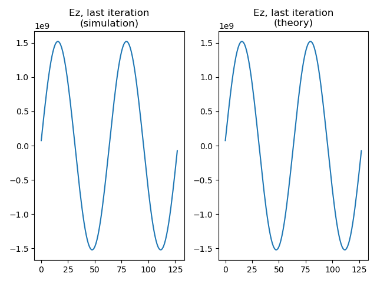

图 8-1 的数据来自 `runs/stage-c-validation/langmuir_frequency_fit/langmuir_multi_1d_analysis.png`，由官方 Langmuir 输入和 `scripts/analyze_langmuir_frequency_fit.py` 生成；图像被复制到书稿专属 `manuscript/assets/figures/` 目录，避免正文依赖运行目录中的临时文件。

当前本地 Langmuir 验证树已经比这个 1D 入口更大。1D/2D/3D/RZ 原生输入族分别复用 `analysis_1d.py`、`analysis_2d.py`、`analysis_3d.py`、`analysis_rz.py`，因此共享同一个“解析场解逐点比较”的主合同；其中 3D 版本还额外检查 selective particle output 和 openPMD 粒子位置上的 `Ex/Ey/Ez` 场采样。`analysis_utils.py` 又把 charge-conservation 检查做成条件分支，只在 Esirkepov、Vay deposition 或 PSATD current-correction 这些适用组合下强制比较 `divE` 与 `rho/\epsilon_0`。与之并列的 `langmuir_fluids` 则是另一棵冷流体验证树：它不只看 `E`，还把 `J` 和 `rho` 一起与解析冷流体解比较。需要单独记住的是，2D/3D/RZ 的 PICMI 变体目前大多仍是 `analysis=OFF` 的前端 + checksum scaffold，不应和原生输入的强物理断言混成同一等级。

从应用综合章的角度，Langmuir wave 的价值不只是“有一个 textbook 解析解”，而是它把当前 worktree 里的四条主线挂到了同一个最小物理问题上：

1. 初始化
   - `NUniformPerCell`
   - `profile = constant`
   - `parse_momentum_function` 共同决定冷等离子体微扰如何进入粒子。
2. 粒子推进与沉积
   - `energy-conserving gather`
   - `Esirkepov`、`Vay deposition`
   - `momentum-conserving gather` 在这个最小问题上暴露 `divE-rho/\epsilon_0` 误差。
3. 场求解
   - FDTD
   - PSATD
   - `current_correction`
   - `JRhom` 都能在同一解析波形下做最小分支验证。
4. 诊断与 reader-side analysis
   - plotfile/full diagnostics
   - openPMD
   - selective particle output
   - on-particle `Ex/Ey/Ez` 都已经有现成 analysis 脚本消费。

这也是为什么 `Examples/Tests/langmuir/` 在当前项目里不是“一个普通回归目录”，而是应用综合章最适合先收口的第一条主线。它已经把：

```
冷等离子体解析振荡
-> parser 初始化
-> gather / pusher / deposition / solver
-> diagnostics / openPMD reader
-> MR / PSATD / current correction / JRhom / PICMI / fluids 分支
```

压在了同一个最小问题上。

到 2026-05-18 为止，这条主线已经不只停在源码和 analysis 脚本层，也有了第一条本地运行记录。当前在

- `/Volumes/PHILIPS/programs/PIC/PIC-tutor/runs/stage-c-validation/langmuir_1d`

用

```bash
env OMP_NUM_THREADS=1 FI_PROVIDER=tcp \
  /Volumes/PHILIPS/programs/PIC/warpx/build_full/bin/warpx.1d.MPI.OMP.DP.PDP.OPMD.FFT.EB.QED.GENQEDTABLES \
  /Volumes/PHILIPS/programs/PIC/warpx/Examples/Tests/langmuir/inputs_test_1d_langmuir_multi
```

完成了真实运行，并生成 `diags/diag1000080`。虽然官方 `analysis_1d.py` 因本机缺 `matplotlib/yt` 没有原样跑通，但它的核心断言已经按同一公式手工复现：

- 解析场相对误差 `error_rel = 1.70e-3 < 5e-2`
- `divE-rho/\epsilon_0` 相对误差 `8.35e-12 < 1e-11`

所以 `Langmuir wave` 现在在本项目里已经是运行级强基准，而不只是“源码上看起来应该能验证”的强基准。

## Uniform plasma

入口：`../warpx/Examples/Physics_applications/uniform_plasma/inputs_test_2d_uniform_plasma`

关键设置：

- `max_step = 10`
- `geometry.dims = 2`
- 周期场边界
- 单电子 species
- 常密度 `1.e25`
- gaussian 动量分布，`ux_th = uy_th = uz_th = 0.01`

这个例子更适合检查并行分解、粒子噪声、诊断输出和性能路径。因为物理结构简单，任何明显的非均匀场增长、粒子丢失或能量异常都容易被发现。

但当前本地 `uniform_plasma` 目录里的 regression 边界需要写得更精确。`test_2d_uniform_plasma` 和 `test_3d_uniform_plasma` 在 `CMakeLists.txt` 中都没有独立 analysis，实际只依赖顶层 `Examples/analysis_default_regression.py` 提供 checksum 基线；因此它们更像是“full diagnostics / 并行噪声 / 最小工作流稳定性”基准，而不是独立的热等离子体物理 hard assert。真正的强断言在 `test_3d_uniform_plasma_restart`：它从 `chk000006` 恢复，再用 `Examples/analysis_default_restart.py` 逐字段比较 restart 与非 restart 输出，要求相对误差低于 `1e-12`。另外，名字里带 `uniform_plasma` 的 `test_3d_uniform_plasma_psatd_JRhom_CC1` 并不属于这个应用目录，而是 `nci_psatd_stability` 里的 PSATD 稳定性回归，它检查的是 `JRhom=CC1 + div cleaning` 后电场能量是否足够小，从而证明 NCI 被压制，而不是均匀热等离子体本身的统计性质。

这意味着 `uniform_plasma` 在应用综合章里最准确的角色不是“单一 physics benchmark”，而是最小热背景 workflow：

1. 均匀、周期、单 species 的 thermal background
   - 给粒子噪声和并行划分提供最低复杂度基线；
2. full diagnostics
   - 给 plotfile/openPMD 风格输出提供最小 reader-side 骨架；
3. checkpoint/restart
   - 给 `analysis_default_restart.py` 提供一条极干净的 field-level reproducibility 基准。

如果把 `TODO` 里的“噪声、能量、性能和诊断”拆开，当前工作树里的证据来源其实是分层的：

- 噪声、性能背景、writer/checkpoint：
  - 主要来自 `Examples/Physics_applications/uniform_plasma/`
- 热等离子体总能量强断言：
  - 主要来自相邻 `Examples/Tests/energy_conserving_thermal_plasma/`
- PSATD/JRhom 稳定性强断言：
  - 主要来自相邻 `Examples/Tests/nci_psatd_stability/`

因此 `uniform_plasma` 的真正价值，不是它自己包含了所有强 analysis，而是它把：

```
均匀热背景
-> 粒子噪声 / 并行稳定性
-> full diagnostics / checkpoint
-> restart reproducibility
-> 与能量守恒、PSATD 稳定性测试树的边界
```

压成了项目里第二条最适合成文的应用主线。

到 2026-05-18 为止，这条主线也已有一条最小本地运行记录。当前在

- `/Volumes/PHILIPS/programs/PIC/PIC-tutor/runs/stage-c-validation/uniform_plasma_2d`

用

```bash
env OMP_NUM_THREADS=1 FI_PROVIDER=tcp \
  /Volumes/PHILIPS/programs/PIC/warpx/build_full/bin/warpx.2d.MPI.OMP.DP.PDP.OPMD.FFT.EB.QED.GENQEDTABLES \
  /Volumes/PHILIPS/programs/PIC/warpx/Examples/Physics_applications/uniform_plasma/inputs_test_2d_uniform_plasma
```

所以 `uniform_plasma` 当前在本项目里的最准确状态仍然是：

- 已有运行级 baseline；
- 尚不是独立物理解强断言；
- 它的强 physics closure 仍需借相邻 `restart`、`energy_conserving_thermal_plasma` 和 `nci_psatd_stability` 三棵树来补齐。

### 2026-07-12：checkpoint/restart 的真实证据

为了把上面的 restart 说明从源码和 CMake wiring 推进到运行级证据，本项目在 `runs/stage-c-validation/uniform_plasma_3d_mpi2/` 复现了同一组 3D 输入：基线从第 0 步运行到第 10 步，并在第 6 步写出 `diags/chk000006`；restart sibling 从该 checkpoint 继续运行到第 10 步。两条路径最终都写出 `diags/diag1000010`。

官方 `../warpx/Examples/analysis_default_restart.py` 与项目内 `scripts/analyze_uniform_plasma_restart.py` 都对两个末态 plotfile 的 level-0 covering grid 逐字段比较。共比较 37 个 field，包含 `Bx/By/Bz`、`Ex/Ey/Ez`、`jx/jy/jz`、`rho`，以及 `electrons` 的粒子位置、动量、权重和粒子 ID；独立 reader-side 对照的最大绝对误差为 `2.4414e-4`，最大相对误差为 `2.8631e-16`，通过官方 `1e-12` 容差。绝对误差来自量纲较大的场/电流数组，不能脱离相对误差单独解释。

这一证据有两个必须同时保留的边界。第一，它直接证明的是 checkpoint 状态恢复、粒子/场续跑和末态 diagnostics 的 reproducibility，不是热平衡能量守恒或某个解析波的 physics gate。第二，WarpX 的 CMake 注册把该测试配置为 2-rank MPI；本轮已用本机 MPICH `mpiexec -n 2` 按官方兄弟目录布局真实补跑。官方 `analysis_default_restart.py` 对 37 个 field 全部通过，独立 reader-side 对照的最大相对误差为 `2.8631e-16 < 1e-12`。但仓库 checksum API 的 rank-specific 聚合参考与本地 2-rank producer 不一致，最大相对差为 `3.20e-2`；因此这里应写成“2-rank restart reproducibility evidence”，同时保留 checksum 非通过边界，不能把逐字段 restart pass 扩大成 checksum pass。

为解释这一 checksum 边界，又用同一当前 WarpX binary 和官方输入分别生成 1-rank、2-rank 的非 restart 基线，并运行 `scripts/analyze_uniform_plasma_mpi_consistency.py`。两套 producer 的粒子总权重完全一致；field energy 相对差为 `1.9379e-2`，particle kinetic energy 相对差为 `8.9170e-4`，total energy 相对差为 `6.2269e-4`，physical-field 最大 L2 相对差为 `1.0185`。因此该 thermal/randomized uniform-plasma case 的 rank-invariant field contract 明确不成立，checksum 差异不能被解释成 restart 失败；本项目只把 2-rank restart 的 plotfile-to-plotfile 一致性写成通过证据。1-rank/2-rank 报告位于 `runs/stage-c-validation/uniform_plasma_3d_mpi2/uniform-plasma-mpi-consistency.{json,md}`。

图 8-11 将这条边界压成两个可读的面板：左图显示 2-rank 相对 1-rank 的全局能量比，右图显示 `B/E/J/rho` 各组 physical field 的最大 L2 相对误差。左图说明粒子动能和总能量仍接近，但右图说明逐场 rank-invariant gate 并未成立；虚线是参考值或 `1e-12` machine-level gate，不是本案例已经通过的物理阈值。

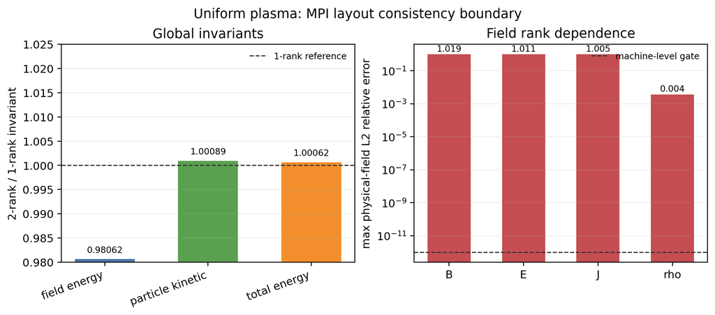

图 8-11 由 `scripts/plot_uniform_plasma_mpi_consistency.py` 从 `uniform-plasma-mpi-consistency.json` 重新生成；该图展示的是并行证据边界，不是新的强 physics benchmark。

## LWFA/PWFA

应用综合章的下一条主线不应再写成单独的 `plasma_acceleration`。当前本地 worktree 里，更准确的组织方式是把：

- `Examples/Physics_applications/laser_acceleration/`
- `Examples/Physics_applications/plasma_acceleration/`

并排视作同一类 wakefield acceleration runtime architecture 的两个分支：

1. `LWFA`
   - laser-driven
2. `PWFA`
   - beam-driven

它们共享的不是统一的 physics hard assert，而是非常相近的工程关注点：

- moving window
- boosted frame
- diagnostics
- mesh refinement
- PICMI/native front-end split

这一节现在还需要保留一条更早的文献边界：当前已经开始精读的 `Tajima-Dawson 1979` 并不是现代 `laser_acceleration` family 的 analysis blueprint，而是这条应用线最早期的 scaling baseline。它把 `laser pulse -> ponderomotive wake -> trapping -> acceleration` 这条最小物理闭环压得很硬，并给出

$$v_p = v_g^{EM} = c\sqrt{1-\frac{\omega_p^2}{\omega^2}},$$

$$L_t = \frac{\lambda_w}{2} = \frac{\pi c}{\omega_p},$$

$$eE_L \cong mc\omega_p,
\qquad
\gamma_{\max} \simeq 2\frac{\omega^2}{\omega_p^2},
\qquad
l_a \cong 2\frac{\omega^2 c}{\omega_p^3}.$$

这些式子最适合在本章里承担 `LWFA earliest scaling baseline` 的角色：它们解释为什么 wake phase velocity、dephasing、加速长度和 underdense-plasma driver 是同一条物理主线；但它们并不直接验证当代 WarpX 的 moving window、boosted frame、mesh refinement、openPMD 或 PICMI 前端实现。

同时，这篇文章也不是只有解析公式。当前精读已经确认它还给出了一个最小 relativistic electromagnetic PIC demonstration：`1 1/2-D`、one spatial dimension、three velocity/field dimensions、Gaussian finite-size particles、固定离子背景，并通过扫描 `\omega/\omega_p` 去对照最早期 scaling。文中数值结果至少压实了三件事：

1. wake longitudinal field 可达到
   $$E_L \sim 0.6\,\frac{mc\omega_p}{e},$$
   即冷等离子体 wave-breaking 级上限的大约 `60%`；
2. driver spectrum 会裂成多峰，作者明确解释为 successive / multiple forward Raman scattering，并把它和 photon deceleration、wake emission 联系起来；
3. simulation 中的最大电子能量随 `(\omega/\omega_p)^2` 的变化基本贴合解析式，只是在高端开始受有限系统大小和周期边界污染。

这进一步说明：`Tajima-Dawson 1979` 能作为 `LWFA` 的 earliest scaling 与 minimal EM-PIC demonstration 文献入口，但它仍不能替代现代 WarpX `laser_acceleration` family 的 runtime regression 合同。

文末还要再保留三条降级边界。第一，原文的 `feasible within present-day technology` 只是 1979 年语境下的工程可行性判断，后面立刻又承认 short-pulse shaping 仍需改进。第二，作者明确保留了 `\Delta\omega = \omega_p` 的 two-laser / beat-wave alternative，因此这篇文章更准确地支撑的是早期 wakefield family，而不是今天单一路径的单脉冲 `LWFA`。第三，pulsar atmosphere / cosmic-ray source 的段落只应当看作历史语境下的 speculative extrapolation，不能进入现代 WarpX 应用合同。

### LWFA：`laser_acceleration` 是 runtime matrix，不是统一 wake benchmark

`laser_acceleration/README.rst` 明确写的是 laser-wakefield acceleration，但 `Analyze` 章节仍是 `TODO`。配合 `CMakeLists.txt` 可以看出，当前这组目录更像是：

- 1D/2D/3D/RZ
- boosted frame
- moving window
- refined patch
- PICMI / Python callback
- openPMD diagnostics

这些路径的 `LWFA runtime matrix`。

当前只有三条局部强 analysis：

1. `analysis_1d_fluid_boosted.py`
   - 检查 boosted 1D 冷流体 `Ez/Jz/rho/Vz` 是否贴理论；
2. `analysis_refined_injection.py`
   - 检查 refined injection 的总粒子数和 refinement-edge 前方 `rho` 均匀性；
3. `analysis_openpmd_rz.py`
   - 检查 RZ openPMD diagnostics 的 mesh shape、species ordering 和 `rho_<species>` 物理中心。

其余大多数 active tests 都是 `analysis = OFF` 加 checksum baseline。因此，当前 `laser_acceleration` 目录更适合在本章承担：

- moving-window / boosted LWFA skeleton
- diagnostics / openPMD / MR / PICMI 路径覆盖

而不是完整的 wake amplitude、beam energy gain 或 laser diffraction 强 benchmark。

### PWFA：`plasma_acceleration` 是 workflow matrix，不是解析 wake benchmark

`plasma_acceleration/README.rst` 明确写的是 beam-driven wakefield acceleration，而不是 generic laser-plasma acceleration。这一点非常重要，因为它决定了这里的 driver 不是 laser antenna，而是 relativistic bunch。

当前目录的另一个硬边界是：

- `Analyze` 仍是 `TODO`
- `Visualize` 仍是 `TODO`
- 3D PICMI boosted-frame 等价性也被 `README.rst` 自己标成 `TODO`

同时，`CMakeLists.txt` 中所有 active tests 都是：

```
OFF  # analysis
"analysis_default_regression.py --path ..."
```

因此 `plasma_acceleration` 当前最准确的角色是：

- `PWFA workflow matrix`
- `beam-driven wakefield application baseline`

它覆盖了：

- moving window
- boosted frame
- rigid bunch
- density ramp / plasma channel
- `particles.use_fdtd_nci_corr = 1`
- mesh refinement
- hybrid grid
- PICMI front-end

但当前并没有目录内统一的 wakefield physics hard assert。尤其要保留一个源码树边界：3D PICMI 输入文件目前仍未像 native 输入那样真正使用 boosted frame，所以不能把它说成 native boosted PWFA 的等价前端。

### 当前 worktree 中这条应用主线真正成立的结论

把 `LWFA/PWFA` 重新收束之后，当前本地证据支持的最强结论是：

1. `laser_acceleration`
   - 是 `LWFA runtime matrix`
   - 强 analysis 只覆盖局部合同
2. `plasma_acceleration`
   - 是 `PWFA workflow matrix`
   - 当前 active tree 全部 checksum-only
3. 二者共享的主线不是统一 benchmark，而是：
   - moving window
   - boosted frame
   - diagnostics
   - MR
   - PICMI/native front-end split

这也意味着，后续书稿如果从应用角度组织 wakefield acceleration，最自然的章节结构不是简单按目录分，而是：

```
wakefield acceleration runtime architectures
-> laser-driven branch (LWFA)
-> beam-driven branch (PWFA)
```

## Laser ion / plasma mirror / RPA/TNSA

这一条应用主线必须写得比目录名更谨慎。当前本地 worktree 里真正可落到 application tree 的 laser-target 入口只有两个：

- `Examples/Physics_applications/laser_ion/`
- `Examples/Physics_applications/plasma_mirror/`

而 `RPA/TNSA` 当前并没有独立应用目录或回归树，只是：

- `laser_ion/README.rst` 背后的物理机制标签；
- `Docs/source/glossary.rst` 里的术语定义。

### `laser_ion`：最强的 laser-target application entry

`laser_ion` 的真实角色不是“已经证明某条 ion-acceleration scaling”，而是：

- Gaussian laser
- planar solid-density target
- full diagnostics
- time-averaged diagnostics
- reduced diagnostics
- PICMI front-end

这条组合工作流的本地入口。

当前它在 CI 里的最硬断言来自 `analysis_test_laser_ion.py`，检查的是：

- `diagInst` 最后 5 个瞬时 `Ez` snapshot 的时间平均
- 与 `diagTimeAvg` 的原位 time-averaged `Ez` 是否逐点一致

因此它当前最强的 regression 合同是：

- diagnostics time-average consistency

而不是：

- TNSA cutoff energy
- RPA threshold
- ion conversion efficiency

README 里的 `analysis_histogram_2D.py` 和 `plot_2d.py` 仍然很重要，但它们当前属于 user-facing post-processing helper，不是活跃 CI regression 本体。

还要再保留一个细边界：`laser_ion` 确实已经有 PICMI 版输入，但其 reduced diagnostics 能力和 native 版并不完全对齐，例如 PICMI 脚本里仍留有 `ParticleHistogram2D` 的 TODO。因此更准确的说法是：

- PICMI 已覆盖主工作流与 `analysis_test_laser_ion.py` 合同；
- 但前端能力还没有完全追平 native input。

### `plasma_mirror`：laser-solid surface-plasma workflow baseline

`plasma_mirror` 当前应用语义很明确：

- laser-solid interaction
- surface plasma
- planar overdense target

但验证层级明显更弱：

- 只有 `test_2d_plasma_mirror`
- `analysis = OFF`
- checksum helper
- 没有 PICMI
- `README.rst` 的 Analyze/Visualize 仍是 `TODO`

因此它更准确的角色是：

- laser-solid surface-plasma workflow baseline

而不是：

- reflectivity benchmark
- high-harmonic benchmark

### `RPA/TNSA`：当前属于物理解释层，不属于本地应用目录层

这条边界如果不写清，很容易把文献中的机制标签误写成当前 worktree 已有的独立本地 examples。当前最强、也最保守的结论只能是：

1. `laser_ion`
   - 是激光打固体平面靶的本地应用骨架；
2. `RPA/TNSA`
   - 是理解这类骨架时需要引入的机制标签；
3. 当前 `Examples/` 中
   - 没有独立 `rpa_*`
   - 也没有独立 `tnsa_*` application tree。

因此，这条应用综合章在当前 worktree 里更准确的组织方式是：

```
laser-target applications
-> laser_ion
-> plasma_mirror
-> RPA/TNSA as mechanism labels, not standalone local trees
```

## Capacitive discharge

这条应用线在当前 worktree 里不该再混成普通 `collision/*` 附属条目。它更准确的角色是：

- `PIC-MCC low-temperature plasma application tree`

因为它同时把以下对象接到同一应用骨架上：

- parallel-plate electrostatic discharge
- `background_mcc`
- 可选 DSMC ionization 分支
- PICMI front-end
- Python callback Poisson solver
- Turner benchmark profile 对照

### 1D PICMI 是当前最强的 Turner benchmark 入口

当前最强的两条 active tests 是：

- `test_1d_background_mcc_picmi`
- `test_1d_dsmc_picmi`

它们共用同一条脚本：

- `inputs_base_1d_picmi.py`

这不是普通薄输入卡，而是完整的 benchmark driver：

1. 选择 Turner case `N=1..4`
2. 组装 1D electrostatic grid
3. 可选安装 Python level Poisson solver callback
4. 打开 `background_mcc`
5. 可选把 ionization 切成 DSMC
6. 累积离子密度并写出 `ion_density_case_N.npy`

当前 CI `--test --pythonsolver` 模式下还会显式确认：

- callback solver 已经实际运行；
- `he_ions` 的 `z` 坐标访问链可用。

因此这条应用树在工程上也不只是低温等离子体 benchmark，同时还是本地最直接的：

- PICMI + Python callback Poisson solver

应用入口之一。

### 当前最硬断言是 case-1 ion-density profile

`analysis_1d.py` 和 `analysis_dsmc.py` 当前都直接读取：

- `ion_density_case_1.npy`

并与内置 Turner case-1 参考离子密度 profile 做 `allclose`。

因此当前 worktree 里最强的 physics contract 是：

- final averaged ion density profile
- against Turner benchmark case 1

而不是笼统的“有 MCC test”或“有 DSMC test”。

### DSMC 版不是孤立小 test，而是同一 benchmark scaffold 的分支

这两条 1D tests 共享同一应用骨架，区别只在于 collision realization：

1. `test_1d_background_mcc_picmi`
   - `background_mcc`
   - external Python Poisson solver callback
   - Turner case-1 profile 对照
2. `test_1d_dsmc_picmi`
   - 把 ionization 切到 DSMC 分支
   - 仍回到同一 Turner case-1 profile 对照

因此更准确的表述是：

- DSMC 分支已经在同一低温等离子体 benchmark scaffold 里被强对照覆盖

而不是只证明“DSMC can run”。

### 2D native / PICMI 当前仍主要是 workflow baseline

与 1D 强对照相比，当前 2D 分支只有：

- `test_2d_background_mcc`
- `test_2d_background_mcc_picmi`

并且两者都是：

- `analysis = OFF`
- checksum helper

因此它们当前只能诚实记成：

- `2D capacitive-discharge workflow baseline`

而不是 2D Turner 强 benchmark。另一个必须保留的边界是：

- `test_2d_background_mcc_dp_psp`

当前整条 `add_warpx_test(...)` 仍被注释掉，所以它只能作为遗留分支记录，不能再冒充活跃 test。

### 既有 `plasma_acceleration` 目录边界

入口：`../warpx/Examples/Physics_applications/plasma_acceleration/inputs_test_3d_plasma_acceleration_boosted`

这一组也需要避免被过度解读。当前本地 `plasma_acceleration` family 在 `CMakeLists.txt` 中所有活跃 tests 都是 `analysis = OFF`，只复用目录内的 `analysis_default_regression.py` 做 checksum。因此它们不是 “PWFA 解析 benchmark”，而是应用工作流基线。

但它们并不空泛。原生输入和 PICMI 输入合起来，已经覆盖了：

- moving window
- boosted frame
- rigid-injected `driver/beam`
- `particles.use_fdtd_nci_corr = 1`
- level-1 refined patch / `add_refined_region(...)`
- `momentum-conserving` gather 分支
- `grid_type = hybrid`
- field / particle diagnostics

因此这组例子当前真正承担的角色是：给 beam-driven wakefield acceleration 的 runtime matrix 保留稳定输出基线，而不是直接对 wake amplitude、dephasing 或 beam loading 做强物理断言。还有一个需要显式保留的源码树边界是：`README.rst` 目前明确写着 3D PICMI 版“应该像原生输入一样使用 boosted frame，但仍是 TODO”。所以 `inputs_test_3d_plasma_acceleration_picmi.py` 当前只能诚实记成 non-boosted PICMI scaffold，不能误写成原生 boosted PWFA 的等价前端。

## Magnetic reconnection

当前 worktree 里，磁重联这条应用线最准确的入口不是一般 `Fluids/`，而是：

- `Examples/Tests/ohm_solver_magnetic_reconnection/`

它依赖的是：

- `picmi.HybridPICSolver`
- `HybridPICModel`

也就是：

- kinetic ions
- electron-fluid Ohm closure
- Faraday + RK 子步推进 `B`

而不是 `WarpXFluidContainer` 那条额外 cold-fluid species runtime layer。这个边界必须写死，因为已有源码笔记已经明确：

- `Fluids/`
  - 自己维护 nodal `N/NU`
  - gather 主场
  - 再把 `rho/J` 沉积回普通场寄存器；
- `HybridPICModel`
  - 则是在 field solver 内部从总电流、离子电流和电子闭合关系反推出 `E`。

因此 `magnetic_reconnection` 在应用综合章里的正确角色是：

- `hybrid-PIC space-plasma application`

而不是：

- `fluid/PIC coupling demo`

### force-free sheet + reduced `FieldProbe`

`inputs_test_2d_ohm_solver_magnetic_reconnection_picmi.py` 当前不是薄输入卡，而是完整应用 driver。它同时定义了：

- 2D Cartesian 几何
- `x` 周期、`z` 方向 `dirichlet`/`reflecting`
- force-free-sheet 解析初始 `B_x/B_y/B_z`
- `plasma_resistivity`
- `substeps`
- kinetic ion loading
- reduced diagnostic `FieldProbe`

其中最重要的 diagnostics 不是 full plotfile，而是：

- `plane.dat`

它来自 X 点附近的 reduced `FieldProbe`，专门供 reader-side analysis 提取重联率。

### 当前 analysis 是 observable extraction，不是强 assert

`analysis.py` 当前直接从 `plane.dat` 读取 `E_y`，构造：

$$R(t)=\frac{\langle E_y\rangle}{v_A B_0}.$$

然后输出：

- `reconnection_rate.png`

在非 `--test` 模式下还会进一步生成：

- `mag_reconnection.mp4`

但这条脚本没有显式数值 `assert`。因此它当前只能被诚实归类为：

- `physics-informed visualization / observable extraction`

而不是：

- hard numerical benchmark

### checksum 仍是 active coverage 的另一半

`CMakeLists.txt` 里这条 test 还会同时跑：

- `analysis_default_regression.py --path diags/diag1000020`

所以当前 active coverage 的真实结构是：

1. `analysis.py`
   - 提取重联率并可视化；
2. checksum helper
   - 兜底历史输出稳定性。

这也解释了它和邻近 `ohm_solver_*` 条目的分工：

- `ohm_solver_em_modes`、`ion_beam_instability`
  - 更偏局部 solver correctness 的强 regression；
- `magnetic_reconnection`
  - 更偏 hybrid-PIC 代表性物理案例和输出回归。

因此，这条应用线在当前书稿里最准确的结论应写成：

```
magnetic_reconnection
= HybridPICModel application line
= force-free-sheet + reduced FieldProbe + reconnection-rate extraction
= physics-informed visualization + checksum
!= scalar hard-assert benchmark
```

## Beam-beam / luminosity / FEL / ion extraction

- `DifferentialLuminosity`
- `beam_beam_collision`
- `free_electron_laser`
- `ion_beam_extraction`
- `accelerator_lattice`

更准确的组织方式应是：

```
beam and accelerator applications
-> luminosity diagnostics benchmark
-> collider-QED workflow baseline
-> FEL boosted-frame radiation benchmark
-> electrostatic ion-source extraction
-> accelerator-lattice optics regression
```

### `DifferentialLuminosity`：reduced-diagnostic 强谱基准

`Examples/Tests/diff_lumi_diag/` 当前是这条应用线里最强的 diagnostics regression。它的 `analysis.py` 不是普通画图脚本，而是同时读取：

- 一维文本表 `DifferentialLuminosity_beam1_beam2.txt`
- 二维 openPMD 网格 `DifferentialLuminosity2d_beam1_beam2/`

然后直接构造两束 Gaussian beams 的解析 luminosity 谱：

- `dL/dE`
- `d^2L/dE_1 dE_2`

再与 diagnostics 做显式误差比较和 `assert`。因此它的角色必须写成：

- `reduced-diagnostic strong benchmark`

而不是一般的 beam application helper。

### `beam_beam_collision`：collider-QED 应用骨架

与 `DifferentialLuminosity` 相比，`Examples/Physics_applications/beam_beam_collision/` 当前证据层要弱得多：

- active regression 只有 checksum helper；
- 没有独立 `analysis.py`；
- `plot_fields.py` / `plot_reduced.py` 只是后处理可视化脚本。

但它并不空泛。它当前真正把这些路径绑在一起：

- `warpx.do_electrostatic = relativistic`
- 两束 `125 GeV` 电子/正电子 Gaussian bunch 对撞
- `initialize_self_fields = 1`
- Quantum Synchrotron
- Breit-Wheeler
- `ColliderRelevant`
- `ParticleNumber`
- openPMD full diagnostics

因此它最准确的定位是：

- `collider-QED application baseline`

而不是 luminosity 强谱基准。

### `free_electron_laser`：boosted rigid-beam + undulator + BTD 的强 benchmark

`free_electron_laser` 当前不是普通 laser example，因为它本质上没有 laser antenna。已有本地笔记已经压实：

- 核心是 `RigidInjectedParticleContainer`
- `particles.By_external_particle_function(...)` 提供 undulator 外加粒子磁场
- `BackTransformed` diagnostics 与 boosted-frame full diagnostics 的一致性

当前最强断言来自 `analysis_fel.py`：

1. 对 `log(E_x^2)` 的线性增长区做拟合，要求 gain length 接近 `0.22 m`；
2. 在 lab-frame 与 boosted-frame diagnostics 上做 FFT，要求 radiation wavelength 满足 undulator 理论值。

因此它当前最准确的角色是：

- `boosted rigid-beam radiation benchmark`

这条应用线也正好和 `Dawson 1983` 里的经典 FEL 例子接上。那篇综述把 free-electron laser 专门当作 relativistic electromagnetic particle model 的代表问题：lab frame 下给出

$$\lambda \simeq \frac{\lambda_0}{2\gamma^2},$$

而在 beam frame 下又把同一过程重写成 pump electromagnetic wave 衰变成 electromagnetic wave 加 plasma wave 的 Raman-like 参数不稳定，并要求满足

$$k_{\mathrm{pump}} = k_{\mathrm{EM}} + k_p,\qquad
\omega_{\mathrm{pump}} = \omega_{\mathrm{EM}} + \omega_p(k_p).$$

它的历史 simulation 结果还明确展示了 matching-condition 谱证据、约 `36%` 的 longitudinal current 下降、约 `30%` 的束流能量转成辐射，以及 `2\lambda_0` backward mode 的危险性。对本章来说，这组文献证据的作用不是替代当前 `analysis_fel.py`，而是把 WarpX 这条 `boosted rigid-beam + undulator + BTD` benchmark 放回更早的 relativistic EM-PIC 谱系里理解。

如果再把图像层次压得更明确，`Dawson 1983` 这条 FEL 历史线已经形成一个很完整的 diagnostics contract：

- `Fig.54`
  - 给最小装置和 lab-frame / beam-frame 两种物理图像；
- `Fig.55`
  - 用 EM / electrostatic spectra 检查 matching condition；
- `Fig.56`
  - 用 EM energy、electrostatic energy 和 longitudinal current 的同步演化检查 gain、beam degradation 与 saturation；
- `Fig.57`
  - 再把 trapping-based efficiency estimate
    $$\eta = \frac{\gamma_0-\gamma_{\mathrm{ph}}}{\gamma_0-1}$$
    及其大-$\gamma$ 近似
    $$\eta \simeq \omega_{po}(2k_0 c \gamma^{3/2})^{-1}$$
    与 simulation 对照。

也就是说，这组经典图像已经把 mechanism verification、nonlinear saturation 和 rough efficiency scaling 串成一条最小 reader-side 论证链。当前 WarpX `free_electron_laser` 的价值，则是把这条历史论证链重新落到 boosted-frame implementation、BTD 重建和 gain-length / wavelength regression 上。

### `ion_beam_extraction`：EB electrostatic extraction 的强应用入口

`Examples/Physics_applications/ion_beam_extraction/` 当前是这条应用线里最直接的 electrostatic + embedded-boundary beam-source application。

它把：

- plasma source
- `boundary.potential_*`
- `warpx.eb_potential(x,y,z,t)`
- electrostatic solver
- embedded-boundary electrode geometry
- 持续 boundary injection

接成了一条完整链。

当前 `analysis_ion_beam_extraction.py` 会直接检查抽出离子束尾部能量是否接近 `40 keV`，因此它不是 checksum baseline，而是：

- `electrostatic EB extraction strong application check`

### `accelerator_lattice`：beamline optics 的强回归层

如果只写 collider、FEL 和 extraction，这条总节还少了一层真正对应加速器模块本身的强验证。当前最自然的入口是：

- `Examples/Tests/accelerator_lattice/`

这里的 `analysis.py` 会重新读回：

- `lattice.elements`
- `line*`
- `drift*`
- `quad*`

然后按解析 hard-edged quadrupole optics 逐段积分，并要求最终粒子轨道和解析解足够接近。它同时覆盖：

- lab frame
- boosted frame
- moving window

所以它在这条总节里最准确的角色是：

- `beamline optics strong regression`

## 诊断在源码中的位置

`WarpX::Evolve` 中诊断不是附加脚本，而是时间步的一部分：

- 行 173：`multi_diags->NewIteration()`。
- 行 323-330：判断是否需要为诊断同步粒子速度。
- 行 337-344：reduced diagnostics 和 full diagnostics 的计算、打包、写出。
- 行 374-382：最终时间步或中断时 flush last timestep。

源码目录包括：

- `../warpx/Source/Diagnostics/`
- `../warpx/Regression/Checksum/`
- `../warpx/Examples/analysis_default_regression.py`

更底层地看，`Source/Diagnostics` 顶层其实分成四层角色：

1. `MultiDiagnostics` 负责读取 `diagnostics.diags_names`，按 `<diag>.diag_type` 把每个 diagnostics 实例化成 `FullDiagnostics`、`BTDiagnostics` 或 `BoundaryScrapingDiagnostics`，并在主循环里统一分派。
2. `Diagnostics` 提供统一模板骨架：`InitData()`、`FilterComputePackFlush()`、`ComputeAndPack()`、`Flush()`。也就是说，所有 diagnostics 都要经过“先决定是否 compute/pack，再决定是否 flush”的同一套阶段。
3. `FullDiagnostics` 负责把 `fields_to_plot`、`particle_fields_to_plot` 和 species 输出需求映射成具体 functors，再把结果堆叠进输出 `MultiFab`。
4. `ParticleDiag` 不是真正的粒子数据缓冲区，而是每个 species 的输出配置对象：它记录变量选择、`random_fraction` / `uniform_stride` / parser filter、附加粒子场请求，以及粒子来源容器指针。

一个关键实现边界是：普通 `FullDiagnostics` 的粒子输出，并不像 back-transformed diagnostics 那样先 pack 到独立粒子 buffer。它更多是把 `ParticleDiag` 作为 species 句柄和过滤配置传给 writer；真正的粒子变量裁剪和过滤发生在 `FlushFormatPlotfile.cpp` / `WarpXOpenPMD.cpp` 的写出阶段。只有 `BTDiagnostics` 这类带 snapshot buffering 的 diagnostics，才会真正分配 `m_particles_buffer` 和 `ComputeParticleDiagFunctor`。

这也是为什么 `Diagnostics::ComputeAndPack()` 虽然同时有 field-functor loop 和 particle-functor loop，但对普通 full diagnostics 来说，后者默认是空的。不要把“所有 diagnostics 都有独立粒子 pack 阶段”当成 WarpX 的统一事实。

继续往下拆，会看到 diagnostics 模块其实还有另一条容易混淆的边界。`ComputeDiagFunctors/` 是字段计算层：`JFunctor`、`RhoFunctor`、`PhiFunctor` 直接把 `j/rho/phi` 这类量写进 diagnostics `MultiFab`；`ParticleReductionFunctor` 虽然读取粒子，但它输出的仍然是 cell-centered `MultiFab`，因此也属于字段计算层，而不是粒子 writer。

真正的粒子过滤发生在 writer 阶段。无论是 `WarpXOpenPMD.cpp` 还是 `FlushFormatPlotfile.cpp`，都会先从 `ParticleDiag` 取出：

- `random_fraction`
- `uniform_stride`
- parser filter
- geometry filter

然后创建一个临时粒子容器 `tmp`，通过 `tmp.copyParticles(...)` 把通过过滤的粒子复制进去，再把 `tmp` 写出。因此 `ParticleDiag` 构造阶段只是记录过滤规则；真正应用过滤是在 flush 的时候。

`phi`、`Ex/Ey/Ez`、`Bx/By/Bz` on particles`也不属于 field functor 层，而是 writer 在过滤后的`tmp`上再做一次 gather。`ParticleIO.cpp`明确限制这些附加粒子场只允许`diag_type = Full`，因为对`BackTransformed`或`BoundaryScraping` 这类带粒子缓冲区的 diagnostics 来说，粒子被写出的时间并不等于粒子被收集的时间，此时再 gather 场会产生时间层错配。

`ReducedDiags/` 又是另一套平行体系。它不继承 `Diagnostics`，也不走 `MultiFab + ParticleDiag + FlushFormat` 这条主线，而是由 `MultiReducedDiags` 读 `warpx.reduced_diags_names` 后，按 `<reduced_diag_name>.type` 分派到 `FieldEnergy`、`ParticleEnergy`、`ParticleHistogram`、`FieldProbe`、`LoadBalanceCosts` 等具体类型。它们共享的核心抽象不是字段/粒子快照，而是一段 `m_data` 向量和统一的表格写出协议：第一列是 step，第二列是时间，后面各列是 reduced quantity。

这类 reduced diagnostics 里，很多类型是“到点现算即写”，例如 `FieldEnergy` 和 `ParticleEnergy`；但也有例外，例如 `FieldPoyntingFlux` 会维护跨时间步累积的积分量，因此还要实现 `WriteCheckpointData()` / `ReadCheckpointData()`，把内部状态写进 checkpoint 并在 restart 时恢复。也就是说，diagnostics 模块里并不是只有 `BTDiagnostics` 才有跨步状态，部分 reduced diagnostics 也有。

checkpoint format 本身也不能等同于普通 diagnostics 格式。`FlushFormatCheckpoint.cpp` 实际写出的是 WarpX 的 restart state：`E/B`、coarse/fine patch fields、同步后的 current、PML 数据、粒子状态，以及 reduced diagnostics 额外的 checkpoint 数据。它并不是把某个 diagnostics 的 `m_mf_output` 换一种文件格式落盘，而是直接序列化运行态。

`BTDiagnostics` 则是另一类“有状态机”的 diagnostics。它几乎每一步都可能执行 `DoComputeAndPack()`，把 cell-centered 后的场切成一片片 lab-frame slice，逐步填进 snapshot buffer；`DoDump()` 判断的也不是单纯的时间间隔，而是“当前 buffer 是否已满”“最后一个有效 z-slice 是否已经填到”以及“结束时是否需要强制冲刷剩余 buffer”。因此 BTD 不能被理解成另一种普通 full diagnostics，它本质上是一套 slice / buffer 的累积和 flush 机制。

再往 reduced diagnostics 的具体类型里看，会发现它们虽然共用 `ReducedDiags` 骨架，但实现形态并不统一。`FieldProbe` 内部维护的不是一个标量数组，而是一套专门的 `FieldProbeParticleContainer`：point/line/plane 三种几何最终都会在 `InitData()` 中转成一批 probe particles，再在 `ComputeDiags()` 里对 `Efield_aux/Bfield_aux` 做 gather。因此它测到的不是推进器主寄存器的原始 `fp` 场，而是粒子侧真正会看到的 `aux` 场；`do_moving_window_FP` 也不是事后回推场，而是直接平移这批 probe particles。若 `integrate = 1`，它还会在每一步把采样值乘 `dt` 累加到 probe-particle SoA 中，到输出步才写出累计量。

`ParticleHistogram` 和 `ParticleHistogram2D` 又是另一种 reduced diagnostics。前者是 parser 驱动的一维 weighted histogram：对每个粒子先算 `histogram_function(t,x,y,z,ux,uy,uz)`，再按 `floor((f-bin_min)/bin_size)` 落 bin，默认累加粒子权重 `w`，最后在 MPI 归约之后再做 `max_to_unity` 或 `area_to_unity` 归一化。后者虽然还挂在 `ReducedDiags/` 下，但 writer 已完全变成 openPMD mesh 输出：`histogram_function_abs`、`histogram_function_ord` 决定二维坐标，`value_function` 决定每个粒子向该 bin 累加什么值，并且 writer 会连同轴标签、bin spacing、global offset 和 parser 字符串一起写进 openPMD 元数据。因此二维 histogram 不是“多一列文本表”，而是真正的带坐标二维诊断场。

`LoadBalanceCosts` 和 `LoadBalanceEfficiency` 则属于性能/并行态 diagnostics。前者输出粒度是 box，而不是 rank：每个 box 会写 `cost`、`proc`、`lev`、`i_low/j_low/k_low`、`num_cells`、`num_macro_particles`，GPU 运行时还会附带 `gpu_ID`，再通过额外的 `MPI_Gatherv` 收集 hostname。`Heuristic` 模式下它会先调用 `ComputeCostsHeuristic()` 重建 heuristic cost；`Timers` 模式下则直接导出当前 timers 成本。因此它真正暴露的是 WarpX load-balance 决策所依据的 box-level 负载分布，而不只是一个抽象效率数字。`LoadBalanceEfficiency` 相比之下非常薄，它只是把 `warpx.getLoadBalanceEfficiency(lev)` 的结果按 level 写出来，用于快速检查某次重分配前后是否更均衡。

对应的 regression 也不是同一种口径。`analysis_reduced_diags_impl.py` 会从 full plotfile 重新计算 `FieldEnergy`、`ParticleEnergy`、`FieldReduction` 等 compact observable，再与 reduced diagnostics 文本结果比较，所以它主要验证 reduced diagnostics 与 full-state reference 是否一致。`analysis_reduced_diags_load_balance_costs.py` 则完全不读 plotfile，而是直接从 `LBC.txt` 重建每个 rank 的总成本，并只断言 load-balance 之后

$$\text{efficiency}_\text{before} < \text{efficiency}_\text{after}.$$

这说明 reduced diagnostics 在 WarpX 里既有“物理量压缩输出”的一面，也有“把并行运行态暴露给后处理”的一面，不能把它们都当成同一种小型文本统计表。

如果把 diagnostics 再按 writer 分成一层，会看到 `diag_type` 和 `format` 是两套独立分派。`MultiDiagnostics` 先按 `diag_type` 把对象构造成 `FullDiagnostics`、`BackTransformed` 或 `BoundaryScrapingDiagnostics`；之后 `Diagnostics::InitDataBeforeRestart()` 再按 `format` 选择：

- `FlushFormatPlotfile`
- `FlushFormatOpenPMD`
- `FlushFormatCheckpoint`

这三条 writer 路径虽然共用 flush 调度时机，但服务目标已经不同。`plotfile` 路径会把 diagnostics 已经 pack 好的 cell-centered `MultiFab` 通过 `WriteMultiLevelPlotfile(...)` 写出；若打开 `plot_raw_fields = 1`，还会额外把原始 staggered/raw fields 写进 `raw_fields/` 子目录，因此它既能给普通分析用，也能给底层网格调试用。`openPMD` 路径在 fields 侧同样写 diagnostics 视图，但在粒子侧比 plotfile 更强：它可以在 writer 中对过滤后的临时粒子容器再次 gather `phi`、`Ex/Ey/Ez`、`Bx/By/Bz`。不过这项能力只允许 `diag_type = Full`，因为 `ParticleIO.cpp` 明确禁止对 `BackTransformed` 或 `BoundaryScraping` 这类“收集时刻和写出时刻不一致”的缓冲型 diagnostics 再去 gather 场。

`checkpoint` 路径则完全不是“另一种 diagnostics 文件格式”。`FlushFormatCheckpoint::WriteToFile()` 基本不消费 `m_mf_output`，而是直接从 `warpx.m_fields` 序列化真实运行态：

- `Efield_fp/Bfield_fp`
- `E_old`
- synchronized `current_fp/current_cp`
- coarse patch fields
- time-averaged fields
- PML 数据
- 完整 species 与 lasers 粒子状态
- distribution mapping
- reduced diagnostics 的 checkpoint state

因此 checkpoint 的真正对象是 restart persistence，而不是用户筛选后的诊断视图。也正因为如此，`FullDiagnostics::ReadParameters()` 对 `format = checkpoint` 做了比文档更强的源码约束：不能自定义 `fields_to_plot`、不能裁剪 `diag_lo/diag_hi`、不能做 `coarsening_ratio`、不能指定 species 子集，也不能开 raw fields。它要求的是“全量可恢复状态”，不是“最小可读输出”。

从现有本地例子看，这三类 writer 的最小输入骨架也已经比较稳定：

- 普通 `plotfile`：只写 `diag1.diag_type = Full` 和一组 `fields_to_plot` 即可，`format` 缺省就是 plotfile。
- `openPMD`：在 full diagnostics 上再加 `diag1.format = openpmd` 和 `diag1.openpmd_backend = h5/bp*`，`laser_ion` 已经给出了带 field filtering 的最小可复用骨架。
- `checkpoint`：通常并行放一个 `diag1` 和一个 `chk`，后者写 `chk.diag_type = Full`、`chk.format = checkpoint`；重启则用 `amr.restart = "../.../chk000XXX"` 接回。

对本章当前最相关的 reduced diagnostics，也已经能直接从本地 examples 抽出最小运行入口：

- `FieldProbe`：`Examples/Tests/reduced_diags/inputs_test_3d_reduced_diags` 和 `laser_ion` 都给了 point/line 的最小参数骨架。
- `ParticleHistogram2D`：`laser_ion` 已经给了 `histogram_function_abs/ord` 与 `value_function = "w"` 的二维相空间例子。
- `LoadBalanceCosts`：`Docs/source/usage/workflows/plot_distribution_mapping.rst` 与 `Examples/Tests/reduced_diags/analysis_reduced_diags_load_balance_costs.py` 已经构成最小“生成 + 画图/验效”工作流。

如果要看 `FieldProbe` 的强 analysis regression，本地还有一组比这些“最小骨架”更直接的条目：`Examples/Tests/field_probe/`。它不是只检查文件格式，而是把 line `FieldProbe` 接到单缝衍射 benchmark 上。analysis 会从 `FP_line.txt` 读出 step 500 的积分电磁通量，再与解析 `sinc^2` 衍射包络比较，并要求平均相对误差小于 `2.5%`。按当前 checkout 的官方输入真实运行后，这条线暂时不能作为“已通过”的例子：1-rank 和官方 2-rank MPI 配置产生完全一致的 `FP_line.txt`，但 `analysis.py` 的平均误差都是 `3.6703%`，最大选点误差为 `10.0843%`。项目内的 `scripts/analyze_field_probe_diffraction.py` 已复现同一选点范围和分母，并将结果归档到 `runs/stage-c-validation/field_probe_2d/` 与 `field_probe_2d_mpi2b/`。

这里的失败本身是诊断章节需要保留的证据。它说明 reduced diagnostic 的 writer 合同已经接通：201 个 probe 点、step 500 的积分通量和 1/2-rank 一致性都成立；但这还不足以证明 `FieldProbe` 的物理量与解析衍射包络一致。随后将网格从官方的 `lambda/16` 加密到 `lambda/32`，并在相同物理时间的 step 1000 取样，官方同口径误差降为 `0.3533%`，最大选点误差为 `1.0414%`，通过 `2.5%` gate。对照报告位于 `runs/stage-c-validation/field_probe_resolution_comparison.md`。

因此当前最稳妥的成书结论是：原始 coarse case 的“输出链通过、解析 physics gate 未通过”是真实结果；网格加密后的通过结果支持 coarse-grid 离散误差是主因，但不能把 refined case 的结果反写成原始官方输入已通过。关闭 filter 只能把误差略降至 `3.5910%`，而 `interp_order=0` 在当前分支产生零通量，后者应作为另一个需要单独审计的 raw-field gather 边界，而不是有效的物理改进方案。

图 8-3 将这条边界画成两个并排面板：左图是官方 analysis 使用的平均误差和 `2.5%` gate，右图是 40 个选点中的最大误差。颜色只表示当前报告的 pass/fail 状态；refined 的通过来自 `lambda/32`、相同物理时间的 step 1000 对照，不是对 coarse 输入的重写。

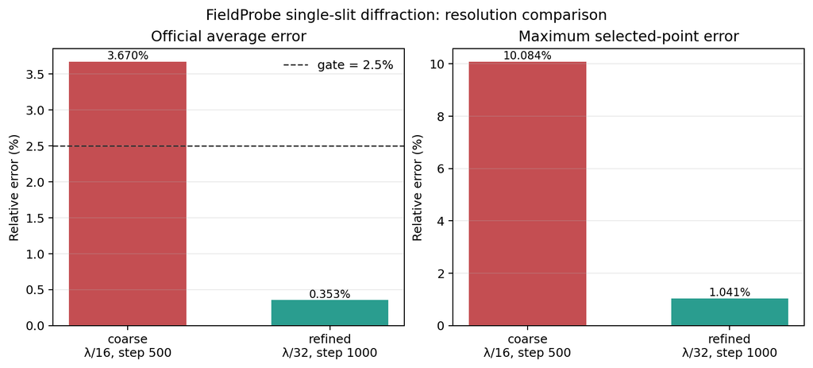

图 8-3 由 `scripts/plot_field_probe_resolution.py` 从 `runs/stage-c-validation/field_probe_resolution_comparison.json` 重新生成。

同一层里，本地还有两组更偏束流诊断的强 regression。`Examples/Tests/collider_relevant_diags/` 不是普通 reduced-output 烟雾测试，而是把 `ColliderRelevant` 与 `ParticleExtrema` 并排打开，然后用解析粒子样本逐项核对 `chi_min/max/ave`、`theta_x/theta_y` 的 min/ave/max/std，再从 full openPMD 的 `rho_beam_e/rho_beam_p` 重建 `dL/dt` 与 reduced output 交叉验证。也就是说，这组例子验证的不是“表格写出来了”，而是 collider-oriented reduced quantities 的定义和聚合合同本身。

`Examples/Tests/diff_lumi_diag/` 则把 reduced diagnostics 进一步推进到带解析谱对照的束流物理量：一维 `DifferentialLuminosity` 文本表和二维 `DifferentialLuminosity2D` openPMD 网格同时输出，analysis 直接构造两束高斯束流对撞的解析 `dL/dE` 与 `d^2L/dE_1dE_2`，再分别比较 1D/2D diagnostics。对本章来说，这组例子非常有价值，因为它把“reduced diagnostics 可以是纯文本列，也可以是 openPMD 网格”这件事，用同一个物理 benchmark 明确落地了。

与之相邻、但等级更弱的一组是 `Examples/Physics_applications/beam_beam_collision/`。这组例子同样使用 collider 场景、Quantum Synchrotron、Breit-Wheeler、`ColliderRelevant` 与 `ParticleNumber` reduced diagnostics，但当前活跃 regression 只有 `analysis_default_regression.py` 提供 checksum，没有独立 `analysis.py`。因此它更准确地是一个 collider-QED application baseline：验证 relativistic electrostatic self-field、beamstrahlung、coherent pair generation 和 reduced diagnostics 的联合工作流能否稳定接通，而不是对 luminosity 谱或 Yakimenko 2019 结果做强物理断言。目录里的 `plot_fields.py` 和 `plot_reduced.py` 也只是说明用户应如何可视化 `|E|/|B|`、次级对密度、每个 beam particle 的 photon 数与 NLBW pair 数；它们不应被当成 regression analysis。

`Examples/Tests/reduced_diags/` 本体当前则应再拆成两棵验证树。`test_3d_reduced_diags` 走 `analysis_reduced_diags_impl.py`：它不是只看 reduced text 文件能不能写出来，而是从 full plotfile 重新计算 `FieldEnergy`、`ParticleEnergy`、`FieldMomentum`、`ParticleMomentum`、`FieldMaximum`、`RhoMaximum` 和 parser 驱动的 `FieldReduction`，再与 `EF/EP/PF/PP/MF/MR/NP/FR_*/Edotj.txt` 逐项对照。除 field energy 因 staggered-vs-cell-centered 差异放宽到 `0.3` 之外，其余量默认要求 `1e-12`。因此这条 regression 真正验证的是 compact observable 的物理定义和 full-state reference 一致性。

与之并列的 `test_3d_reduced_diags_load_balance_costs_*` 则完全不是物理场解对照。`analysis_reduced_diags_load_balance_costs.py` 根本不读 plotfile，而是直接从 `LBC.txt` 重建每个 rank 的总成本，再只断言 load balance 前后的效率满足 `efficiency_before < efficiency_after`。因此这组 tests 真正验证的是 `LoadBalanceCosts` 是否把并行运行态忠实暴露给 reduced output，而不是某个固定电磁场或粒子分布是否被精确重现。

这里还要特别写清两个当前边界。第一，`test_3d_reduced_diags_load_balance_costs_timers_psatd` 这个名字在当前本地 checkout 里并没有真的把 solver 切到 `psatd`；它的 input 仍然只是 `inputs_base_3d + algo.load_balance_costs_update = Timers`。第二，`test_3d_reduced_diags_single_precision` 当前也只看到 `analysis_reduced_diags_impl.py` 里预留了 `single_precision=True` 的放宽容差代码路径，但没有看到 active CMake test/input。因此这两条都不能被夸大成当前活跃的强 regression。

这一层补上以后，第 8 章里 diagnostics 的主线已经不只是“有哪些类”，而是能同时回答：

1. 这个 diagnostics 对象属于哪条计算主线；
2. flush 时走哪种 writer；
3. 最终落盘的是 diagnostics 视图、标准化交换格式，还是 restart 运行态。

如果进一步按“落盘后怎么读”来分，这三类 writer 也已经形成稳定分工。`plotfile` 典型目录是：

```
diag1NNNNNN/
  Header
  Level_*/
  <species>/
  warpx_job_info
  WarpXHeader
  raw_fields/   # optional
```

主读取工具是 `yt`，WarpX 文档里的标准入口就是：

```python
import yt
ds = yt.load('./diags/plotfiles/plt00000/')
```

如果只是要常规 field/particle 分析、AMR-aware 后处理，plotfile + yt 仍然是最顺手的默认组合。只有当打开 `plot_raw_fields = 1` 想看原始 staggered 网格时，才需要额外走 `Tools/PostProcessing/read_raw_data.py` 这条 raw reader。

`openPMD` 的目录则更扁平，典型是：

```
diag1/
  paraview.pmd
  openpmd_%06T.h5|bp5|bp4|json
```

fields/particles 的层级主要在文件内部，而不是目录树展开。读者侧主工具是：

- `openPMD-viewer`
- `openPMD-api`

前者适合快速浏览和 Jupyter 交互，后者适合保留完整 metadata、做并行/chunk 读取以及与外部数据生态对接。文档还专门提醒：`yt` 也能读一部分 openPMD HDF5，但没有 mesh refinement 支持，因此不能把它当成 plotfile 读法的完全替代。

`checkpoint` 则根本不是“分析目录”，而是 WarpX 自己的 restart contract。其目录会更像：

```
chkNNNNNN/
  WarpXHeader
  warpx_job_info
  Level_*/
  <species>/
  <lasers>/
```

里面包含的是 `E/B` 主寄存器、`current`、coarse patch、PML、完整 species 和 lasers，以及 distribution mapping 和 reduced diagnostics checkpoint state。它的首要读取者不是 Python 数据分析工具，而是：

```
amr.restart = "../.../chk000XXX"
```

也就是说，checkpoint 的主用途是“接着跑”和“恢复”，不是“直接分析”。这一点和 plotfile/openPMD 必须明确分开。

因此，对输出格式的选择可以直接收敛成三条经验：

1. 想做常规物理分析，优先 `plotfile`。
2. 想做标准化交换、粒子上附加场、RZ mode 或 richer metadata，优先 `openPMD`。
3. 想保留完整运行态并支持 restart，只能用 `checkpoint`。

当前本地 `restart/` 目录里还有两条很窄但很有代表性的 PICMI regression，把这三条经验压到了更细的接口层。`inputs_test_2d_id_cpu_read_picmi.py` 虽然也挂了 checkpoint 组件，但当前强断言其实是脚本内直接读取 `pti["idcpu"]` 并用 `unpack_ids/unpack_cpus` 验证粒子标识解包合同；`inputs_test_2d_runtime_components_picmi.py` 则把 `picmi.Checkpoint(...)`、`amr.restart=...` 参数解析和动态 `newPid` runtime component 放在一起，证明 checkpoint front-end 接线与 runtime-attribute 写入合同可以共存，但对应的 `test_2d_runtime_components_picmi_restart` 仍是 `FIXME` scaffold。这说明 checkpoint/PICMI 这条线已经有最小 regression 证明“前端能接上”，但还没有把“restart 后动态 runtime attrs 仍完全一致”升级成活跃强断言。

`BackTransformed` diagnostics 还有一条当前本地很值得保留的 RZ 强基准：`Examples/Tests/btd_rz/`。它不是只检查 RZ BTD 目录结构，而是从 `back_rz` openPMD 文件读取 back-transformed 轴上场剖面，直接拟合 boosted-frame Gaussian laser 还原到 lab frame 后的振幅、波长、包络持续时间和相位中心。因此这组例子说明：RZ `BackTransformed` diagnostics 已经不仅有 writer 合同，还有明确的物理重建合同。

checkpoint/restart 这条线也有两类当前本地很值得区分的最小基准。`test_3d_acceleration` / `test_3d_acceleration_restart` 是最严格的一类：analysis 逐字段比较 restart 与非 restart plotfile，要求最大相对误差低于 `1e-12`，因此它真正验证的是 acceleration 基线上的 restart 可重复性，而不是某个独立“加速物理”现象。`test_3d_eb_picmi` 则更像一条前端 scaffold：它把 PICMI、embedded boundary、checkpoint 与 `amr.restart=...` 放进同一个最小脚本中，但当前活跃 test 仍主要依赖 checksum，显式 restart 变体还停在 `FIXME`。因此这条线目前证明的是“EB + PICMI + checkpoint 配线能接上”，而不是“EB restart 后所有状态都已有独立强断言覆盖”。

这条 `restart_eb` 边界还需要再强调一层：目录里虽然已经放着 `analysis_default_restart.py`，而且注释掉的 `test_3d_eb_picmi_restart` 也明确准备好了

```
amr.restart = "../test_3d_eb_picmi/diags/chk000030"
```

与逐字段 restart 对照的调用方式，但当前活跃注册仍只有 `test_3d_eb_picmi` 本体，且 `analysis = OFF`。因此在正文里更准确的说法应是：

1. `restart_eb` 已经有完整的“未来强 restart regression”脚手架；
2. 当前活跃 CI 仍只证明 EB + PICMI + checkpoint 输出链稳定；
3. 还不能把这条线表述成“EB restart 已完成 field-level reproducibility 验证”。

同一个 `restart/` 目录里还有一条更细、但很容易被误归到“纯 PSATD benchmark”的分支：`test_3d_acceleration_psatd*`。这些输入并不是单独拿出来验证谱色散关系，而是把同一条 3D boosted acceleration workflow 切到：

- `algo.maxwell_solver = psatd`
- `psatd.use_default_v_galilean = 1`

并在另一支里再额外打开：

- `psatd.do_time_averaging = 1`

然后继续复用同一个 `analysis_default_restart.py` 做逐字段 restart 对照。也就是说，这几条回归真正证明的是：

1. PSATD + Galilean acceleration workflow 的 checkpoint/restart 可重复性；
2. time-averaged PSATD update 打开后，同一 workflow 的 restart 可重复性。

它们不是新的色散理论强基准，而是“更复杂 solver path 仍能完整写盘并无漂移恢复”的 diagnostics/restart 合同。

## `BoundaryScrapingDiagnostics` 与 Python scraped-particle buffer

边界诊断是这一章里一个容易误解的特殊分支。它不是普通 full diagnostics 的“少画几列字段”，而是单独的 `diag_type=BoundaryScraping`。

`MultiDiagnostics.cpp` 读到这个 `diag_type` 时，会直接构造：

```cpp
alldiags[i] = std::make_unique<BoundaryScrapingDiagnostics>(i, diags_names[i], diags_types[i]);
```

而 `BoundaryScrapingDiagnostics::ReadParameters()` 又立刻把默认 field 输出关掉：

```cpp
m_varnames_fields = {};
m_varnames = {};
m_num_buffers = AMREX_SPACEDIM*2;
if (eb_enabled) { m_num_buffers += 1; }
```

这说明它的输出对象不是普通场变量，而是每个边界各自那份 `ParticleBoundaryBuffer`。

进一步看 `InitializeParticleBuffer()`，它对每个 species、每个 boundary 都直接取：

```cpp
WarpXParticleContainer::Base* bnd_buffer =
    particle_buffer.getParticleBufferPointer(species_name, i_buffer);
m_output_species[i_buffer].push_back(ParticleDiag(m_diag_name, species_name, pc, bnd_buffer));
```

所以 `BoundaryScrapingDiagnostics` 不是重新扫主粒子容器，而是直接消费前面边界处理阶段已经收集好的 scraped event。

这个 diagnostics 目前还有两个硬边界：

- 必须编译 openPMD；
- `<diag>.format` 必须是 `openpmd`。

写出时，`Flush(i_buffer)` 会把每个边界单独写到：

```cpp
const std::string file_prefix =
    m_file_prefix + "/particles_at_" + particle_buffer.boundaryName(i_buffer);
```

因此目录天然会分成 `particles_at_xlo`、`particles_at_zhi`、`particles_at_eb` 等子目录。更关键的是，写完后它立即：

```cpp
particle_buffer.clearParticles(i_buffer);
```

也就是说，`BoundaryScrapingDiagnostics` 对 `ParticleBoundaryBuffer` 是“写出并消费”的语义，而不是只读观察。

Python 接口走的是同一份底层状态。`Source/Python/WarpX.cpp` 只是把 WarpX 单例里的：

```cpp
wx.GetParticleBoundaryBuffer()
```

直接暴露给 `sim.extension.get_particle_boundary_buffer()`。高层 `ParticleBoundaryBufferWrapper` 再把它封成：

- `get_particle_boundary_buffer_size(...)`
- `get_particle_boundary_buffer(...)`
- `get_particle_scraped_this_step(...)`
- `clear_buffer()`

其中 `get_particle_scraped_this_step()` 并不是单独的“本步队列”，它只是用 `stepScraped == getistep(level)` 对累计 buffer 做一次筛选。官方 Python 文档也明确要求用户手动 `clear_buffer()`，否则内存会持续增长。

因此，边界 scraped particle 的消费侧必须记住三个事实：

1. `BoundaryScrapingDiagnostics` 只写粒子，不写场，而且当前只支持 openPMD。
2. Python wrapper 和 diagnostics 共用同一个 `ParticleBoundaryBuffer`，不是两份独立副本。
3. diagnostics flush 后会自动清空对应 boundary buffer；Python 路径则需要用户自己清空。

这一点对二次发射、探测器统计和边界通量诊断尤其关键，因为它决定了“什么时候读到哪些粒子”，本质上取决于 buffer 的消费时机，而不只是取决于边界物理本身。

## 固定模板案例页

为了避免 diagnostics 章节一直停留在“原理说明”，现在把四类最常用输出都压成同一模板：

1. 最小输入片段。
2. 典型目录树。
3. 读取入口。
4. 适用场景。

### 模板 A：`plotfile`

最小输入片段：

```
diagnostics.diags_names = diag1

diag1.diag_type = Full
diag1.intervals = 10
diag1.fields_to_plot = Ex Ey Ez Bx By Bz rho
diag1.write_species = 1
```

典型目录树：

```
diags/diag1/
  diag1000000/
    Header
    Level_0/
    <species>/
    warpx_job_info
    WarpXHeader
    raw_fields/   # optional
```

读取入口：

```python
import yt
ds = yt.load("./diags/diag1/diag1000000/")
```

适用场景：

- 常规 field/particle 分析。
- 需要 `yt` 的 AMR-aware 工作流。
- 需要额外读取 `raw_fields/` 做 staggered-grid 调试。

### 模板 B：`openPMD`

最小输入片段：

```
diagnostics.diags_names = diag1

diag1.diag_type = Full
diag1.format = openpmd
diag1.openpmd_backend = h5
diag1.intervals = 10
diag1.fields_to_plot = Ex Ey Ez Bx By Bz rho
diag1.write_species = 1
```

如果需要 writer 阶段再把场 gather 到粒子：

```
diag1.plot_phi = 1
diag1.plot_E = 1
diag1.plot_B = 1
```

典型目录树：

```
diags/diag1/
  paraview.pmd
  openpmd_000000.h5
  openpmd_000010.h5
```

读取入口：

```python
from openpmd_viewer import OpenPMDTimeSeries
ts = OpenPMDTimeSeries("./diags/diag1/")
```

适用场景：

- 标准化数据交换。
- richer metadata 或 openPMD 生态工具链。
- full diagnostics 下的 `phi` / `E` / `B` on particles。

### 模板 C：`checkpoint`

最小输入片段：

```
diagnostics.diags_names = chk

chk.diag_type = Full
chk.format = checkpoint
chk.intervals = 100
```

重启入口：

```
amr.restart = ./diags/chk/chk000100
```

典型目录树：

```
diags/chk/
  chk000100/
    WarpXHeader
    warpx_job_info
    Level_0/
    <species>/
    <lasers>/
```

读取入口：

首要读取者不是 Python，而是 WarpX 本体的 restart。

适用场景：

- 中断后续跑。
- 完整运行态持久化。
- reduced diagnostics 的 checkpoint state 恢复。

### 模板 D：`BoundaryScraping/openPMD`

本地最清楚的真实骨架来自 `thomson_parabola_spectrometer`：

```
diagnostics.diags_names = screen

screen.diag_type = BoundaryScraping
screen.format = openpmd
screen.intervals = 1

hydrogen1_1.save_particles_at_zhi = 1
carbon12_6.save_particles_at_zhi = 1
carbon12_4.save_particles_at_zhi = 1
```

典型目录树：

```
diags/screen/
  particles_at_zhi/
    paraview.pmd
    openpmd_000001.h5
    openpmd_000002.h5
    ...
```

如果是 embedded boundary scraping，则目录会变成 `particles_at_eb/`。

读取入口：

```python
from openpmd_viewer import OpenPMDTimeSeries
series = OpenPMDTimeSeries("./diags/screen/particles_at_zhi/")
```

`point_of_contact_eb/analysis.py` 也用同一路径读取：

```python
ts_scraping = OpenPMDTimeSeries("./diags/diag2/particles_at_eb/")
```

适用场景：

- 探测器或屏幕 hit 记录。
- 吸收边界通量统计。
- EB 接触点位置和法向验证。
- 需要把 scraped particles 落成持久文件而不是只在 Python callback 里临时消费。

和前三类相比，这一类还要额外记住：

1. 只支持 `openPMD`。
2. 只写粒子，不写场。
3. species 必须先开 `save_particles_at_xlo/.../eb`。
4. writer filter 在 flush 时生效，因此 `plot_filter_function` 里的 `t` 是写出时间，不是撞边界时间。

`thomson_parabola_spectrometer` 还需要再往前走一步理解。它不只是 `BoundaryScraping/openPMD` 的模板例子，也是 active 强 analysis：`CMakeLists.txt` 同时运行 `analysis.py` 和 checksum helper。`analysis.py` 会从 `screen/particles_at_zhi/` 读取 detector hits，再从 `diag0` 的初始 full diagnostic 读取 `uz/id/mass`，按粒子 `id` 回连出每个 detector hit 对应的初始能量，最终在 screen 平面上重建按 species 和入射能量着色的离子分离图。因此这组例子真正验证的是：

1. `BoundaryScraping` 在 `zhi` 屏面的 detector-hit 持久化
2. openPMD 读取链
3. `id` 跨 diagnostics 回连
4. 解析 `E_x/B_x` 场驱动下的 test-particle TPS optics

所以它不应再被归到笼统的 `PEC / conducting boundary` 桶里。

这样整理后，第 8 章里关于 writer 的内容已经不再只是抽象分类，而是能直接给出“要什么输出，就怎么写输入、怎么找目录、怎么读文件”。

## Python 边界 buffer 的最小消费模板

如果不想先把 scraped particles 写成 openPMD，而是直接在 Python 里消费 `ParticleBoundaryBuffer`，本地 examples 说明这条路也已经很稳定，而且至少有两种典型模式。

### 模式 A：运行结束后统一检查

`particle_boundary_scrape` 给的是最小自检骨架。species 只要打开：

```python
electrons = picmi.Species(
    ...,
    warpx_save_particles_at_xhi=1,
    warpx_save_particles_at_eb=1,
)
```

模拟结束后直接：

```python
from pywarpx import particle_containers

particle_buffer = particle_containers.ParticleBoundaryBufferWrapper()
n = particle_buffer.get_particle_boundary_buffer_size("electrons", "eb")
weights = particle_buffer.get_particle_boundary_buffer("electrons", "eb", "w", 0)
total_weight = sum(w.sum() for w in weights)
particle_buffer.clear_buffer()
```

这里有三个实现细节必须记住：

1. `get_particle_boundary_buffer_size()` 给的是累计到当前时刻的 scraped 数，不是本步增量。
2. `get_particle_boundary_buffer()` 返回的是“每个 tile 一条数组”的列表，不会自动拼平成一块大数组。
3. Python 路径不会自动清空 buffer，必须自己 `clear_buffer()`。

### 模式 B：callback 或在线控制里的即时事件流

`spacecraft_charging` 给的是“文件化 writer 和 Python 在线消费并存”的例子。它一边开：

```python
part_scraping_boundary_diag = picmi.ParticleBoundaryScrapingDiagnostic(
    name="diag2",
    period=-1,
    species=[electrons, protons],
    warpx_format="openpmd",
)
```

一边又在 Python 里直接读同一个 EB buffer：

```python
particle_buffer = ParticleBoundaryBufferWrapper()
weights = particle_buffer.get_particle_boundary_buffer(species, "eb", "w", 0)
sum_weights_over_tiles = sum([w.sum() for w in weights])
ntot = float(mpi.COMM_WORLD.allreduce(sum_weights_over_tiles, op=mpi.SUM))
```

这里它把 `period=-1` 设成只在末尾 flush 一次，目的就是在模拟中途保留完整 in-memory buffer，供 Python 侧累计计算 spacecraft 收集到的净电荷。

它的 analysis 还会继续从 full diagnostics 里抽取每个输出步的最小势值，拟合

$$\phi(t)=v_0\left(1-e^{-t/\tau}\right),$$

并要求拟合得到的 `v0` 和 `tau` 分别落在 `4%` 与 `20%` 的容差内。于是这组例子在第 8 章里最准确的定位就不是“演示 Python 能访问 buffer”，而是：

- boundary buffer 在线消费
- Python 动态改写 EB potential
- 以及 electrostatic diagnostics 最终能否给出正确的 charging 时间尺度

三者联动的应用级 regression。

如果逻辑只想处理“本步刚撞边界的粒子”，更直接的高层接口是：

```python
weights_this_step = particle_buffer.get_particle_scraped_this_step(
    "electrons", "eb", "w", 0
)
```

它本质上只是按 `stepScraped == current_step` 对累计 buffer 做过滤，但这已经足够支撑：

- secondary emission；
- 每步边界通量统计；
- callback 驱动的边界反应模型。

### 这和 `BoundaryScrapingDiagnostics` 的分工

现在 diagnostics 和 Python 两条路径的边界已经可以写得很清楚：

1. `BoundaryScrapingDiagnostics` 负责文件化持久输出，flush 后自动清空对应 boundary buffer。
2. `ParticleBoundaryBufferWrapper` 负责 Python 即时访问，默认不会自动清空。
3. 两者共用同一份 `ParticleBoundaryBuffer`，不是两份副本。

因此，如果 diagnostics 设成频繁 flush，Python 侧看到的累计事件就会被 writer 周期性截断；如果 diagnostics 只在末尾 flush，甚至根本不开 writer，Python 才能把它当成长时间累积的事件池来用。

## Python field wrapper 的最小强回归

`python_wrappers/inputs_test_2d_python_wrappers_picmi.py` 覆盖的是另一条 Python 接口线。它既不是粒子 callback，也不是单纯 writer smoke test，而是直接验证：

- `sim.fields.get(...)`
- `MultiFabRegister`
- valid-domain 字段
- PML split fields
- divergence-cleaning 标量

能否在 Python 侧被稳定访问。

这条 regression 在 `CMakeLists.txt` 里没有独立 `analysis.py`：

```
add_warpx_test(
    test_2d_python_wrappers_picmi
    ...
    OFF
    "analysis_default_regression.py --path diags/diag1000100"
    OFF
)
```

所以如果只看 CMake，会误以为它只是 checksum-only。实际上强断言全部写在 input 脚本内部。脚本在

```python
sim.initialize_inputs()
sim.initialize_warpx()
```

之后，直接抓出：

```python
Ex = sim.fields.get("Efield_fp", dir="x", level=0)
...
Expml = sim.fields.get("pml_E_fp", dir="x", level=0)
...
Fpml = sim.fields.get("pml_F_fp", level=0)
Gpml = sim.fields.get("pml_G_fp", level=0)
```

然后给 valid domain 里的 `E/B/F/G` 填一个平滑 unit pulse，推进 `100` 步，最后不是看图片，而是逐分量检查 benchmark：

```python
def check_values(benchmark, data, comp, rtol, atol):
    passed = np.allclose(
        benchmark, np.sum(np.abs(data[(), (), comp])), rtol=rtol, atol=atol
    )
    assert passed
```

这里 `data[(), (), comp]` 的意思也很关键：

- `()` 取 valid + ghost 全范围；
- `comp` 用来访问 PML split-field 的不同 component。

脚本会依次断言：

- `Ex/Ey/Ez`
- `Bx/By/Bz`
- `F/G`
- `pml_E_fp`
- `pml_B_fp`
- `pml_F_fp`
- `pml_G_fp`

的每个相关 component 都与固定 benchmark 一致，而且若干应为零的 component 也显式要求保持为零。于是这条 test 的真实定位应当是：

- Python field wrapper / PML split-field access

而不是过粗的 `Python API / callbacks`。它验证的是 `pywarpx` 经由 `MultiFabRegister` 暴露出来的非 owning `MultiFab` 视图，在 valid domain、ghost cell、PML 和 cleaning 字段这几层上都没有被包装错。

## 本地运行注意

本机过去运行短 WarpX 案例时，MPI/OFI 路径可能受网络接口影响；小规模复现实验可优先设置：

```bash
FI_PROVIDER=tcp
```

这不是物理参数，只是本机 MPI transport 的稳定性处理。正式实验记录必须把环境变量、binary 路径、输入文件、输出目录和分析脚本写入对应章节。

## 2026-07-11 reader-side 验证增量

本轮把本章末尾的两个后续任务推进到真实运行产物：

1. `runs/stage-c-validation/langmuir_frequency_fit/` 使用同一份 Langmuir 官方输入，只把 `diag1/openpmd.intervals` 从 `40` 改为 `1`，重新运行 80 步，得到 81 个逐步快照；
2. `scripts/analyze_langmuir_frequency_fit.py` 对 `Ez` 的目标空间模做投影，并用两正交分量拟合时间频率，同时逐快照计算 `divE-rho/epsilon_0`；
3. `scripts/analyze_uniform_plasma_conservation.py` 用 `yt` 读取 uniform-plasma 初末 plotfile，统计粒子数、粒子总权重、场能、粒子动能和总能量。

Langmuir 结果记录在 `runs/stage-c-validation/langmuir_frequency_fit/langmuir-frequency-fit.md`：

- `81` 个快照；
- 解析 `omega_p=1.128292045086e14`，拟合值为 `1.128697661742e14`；
- 相对频率误差 `3.595e-4`；
- 官方 `analysis_1d.py` 在同一族运行上给出场最大相对误差 `1.70e-3`、最终 `divE-rho/epsilon_0` 误差 `8.35e-12`，均通过原始阈值；
- 逐步 reader-side 扫描的最大守恒误差为 `3.149e-10`，发生在中间快照，因此不能把“每一步都满足官方 `1e-11` 阈值”写成已验证事实。

Uniform-plasma 结果记录在 `runs/stage-c-validation/uniform_plasma_2d/uniform-plasma-conservation.md`：

- 初末粒子数均为 `65536`；
- 粒子总权重相对变化为 `0`；
- 初始场能量为零，所以场能相对变化率有意标记为 `undefined (zero baseline)`；
- 粒子动能变化约 `7.06%`，总能量变化约 `1.97%`。

随后又把同一输入副本延长到 `100` 步，并每 `10` 步写出一个 plotfile；长时间序列报告位于 `runs/stage-c-validation/uniform_plasma_2d_long/uniform-plasma-conservation.md`。粒子总权重在全部 `11` 个快照中保持不变，末态总能量相对初态变化 `1.387e-2`，时间序列中的最大绝对相对偏差为 `2.518e-2`。这比单看 10 步终点更能说明当前 workflow 的短时热背景统计范围，但仍不足以构成热平衡能量守恒 gate；后者应与 `energy_conserving_thermal_plasma` 的专门 analysis 合同绑定。

这条专门合同已经在本轮真实运行中闭合。`runs/stage-c-validation/energy_conserving_thermal_plasma_2d/` 使用官方 2D 输入运行 500 步，产生 `EF.txt` 和 `EP.txt` 六个 reduced-energy 样本；官方 `Examples/Tests/energy_conserving_thermal_plasma/analysis.py` 通过，新增的 `scripts/analyze_energy_conserving_thermal_plasma.py` 也复现同一 `EF+EP` 计算，得到最大总能量相对漂移 `1.031e-4`，低于官方 `3.000e-3` 阈值。由此可以把两类证据明确分开：uniform-plasma 负责粒子数、I/O 和热背景 workflow 统计，energy-conserving-thermal-plasma 才负责 energy-conserving gather 的强能量漂移 gate。

同一官方 family 的 1D sibling 也完成了复现：`runs/stage-c-validation/energy_conserving_thermal_plasma_1d/` 的 500 步运行和官方 analysis 均通过，最大漂移为 `3.009e-4`。`scripts/compare_energy_conserving_thermal_plasma_family.py` 将 1D/2D 两份报告汇总为 `runs/stage-c-validation/energy_conserving_thermal_plasma_family.md`，两者共享 `EF+EP`、`0.003` 阈值和 6 个采样点的验证合同，但不把两种几何的物理轨迹误写成数值等价。

图 8-2 把这两份 JSON 报告中的 `EF+EP` 和归一化漂移放在同一张图里。左图保留不同几何的能量尺度差异，右图直接与共同的 `0.003` gate 对照；因此读者可以同时看到“能量在场能与粒子能之间交换”和“总能量误差仍被 gate 约束”这两个不同层次。图表由 `scripts/plot_energy_conserving_thermal_plasma.py` 从 case-local JSON 重新生成。

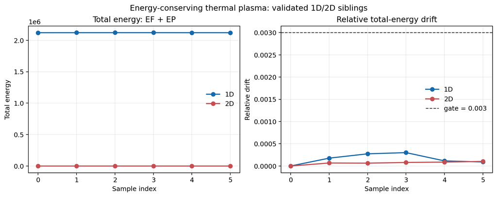

### 2026-07-12：reduced diagnostics 与 full-state reference 对照

本轮按官方 2-rank 配置真实运行 `Examples/Tests/reduced_diags/inputs_test_3d_reduced_diags`，末态为 `diags/diag1000200`。官方 `analysis_reduced_diags.py` 从该 plotfile 重新计算粒子能量/动量、场能/动量、场最大值、rho 最大值、粒子数以及 `FR_Max/FR_Min/FR_Integral/Edotj` 等 parser-driven `FieldReduction`，再逐项与 `EP/EF/PP/PF/MF/MR/NP/FR_*/Edotj.txt` 对照。

共比较 60 个 reduced observable，官方 analysis 通过。除 field energy 外，最大相对误差为 `4.125e-13`；field energy 的相对误差为 `2.483e-1`，仍低于官方为 staggered Yee reduced energy 与 cell-centered plotfile reference 设置的专用 `0.3` 容差。项目内 `scripts/analyze_reduced_diags_contract.py` 保存了官方 analysis 的逐项摘要，报告位于 `runs/stage-c-validation/reduced_diags_3d_mpi2/reduced-diags-contract.md`。

这条证据的准确含义是“compact reduced observable 与 full-state reference 的定义和 writer 输出一致”，不是说 60 个量都构成独立物理守恒定律。尤其 field energy 的 `24.8%` 误差必须保留其 staggered/cell-centered 离散表示边界，不能被误读成普通量的数值精度。

图 8-4 将这两个误差层分开画出：左图在对数尺度下显示 59 个非 field-energy observable 的排序误差，右图单独显示 staggered field-energy 的 `0.2483` 误差与 `0.3` 专用 gate。这样图表本身就保留了“普通量接近机器精度、field energy 仍有离散表示差异”的证据结构，而不是只给出一个混合最大值。

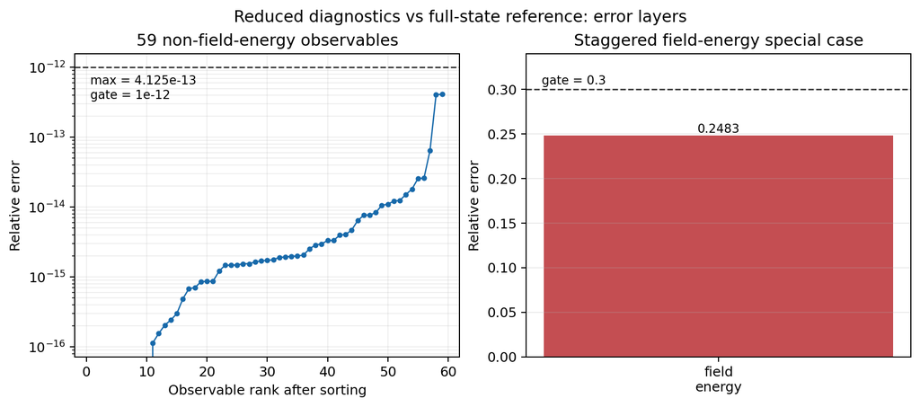

图 8-4 由 `scripts/plot_reduced_diags_error_layers.py` 从 `runs/stage-c-validation/reduced_diags_3d_mpi2/reduced-diags-contract.json` 重新生成。

### LoadBalanceCosts：性能诊断的 efficiency gate

同一 `reduced_diags` family 还包含一条不读取 plotfile 的性能诊断分支：`inputs_base_3d` 使用 `128 x 32 x 128` 网格、16 个 box、`algo.load_balance_intervals = 2`，并由 `LoadBalanceCosts` 将每个 box 的 cost、rank、level、几何位置和粒子数写入 `LBC.txt`。官方 analysis 按 rank 汇总 box cost，再计算

$$\eta = \frac{1}{N_\mathrm{rank}}
\sum_r \frac{C_r}{\max_{r'} C_{r'}}.$$

它比较第 1 行（load balance 前）与第 2 行（load balance 后），要求 `eta_after > eta_before`。本地按官方 2-rank 配置分别运行 `Heuristic` 与 `Timers` 两个 sibling：

| cost source | before | after | result |
| --- | --- | --- | --- |
| `Heuristic` | `0.625252` | `1.000000` | `PASS` |
| `Timers` | `0.744780` | `0.996162` | `PASS` |

报告位于 `runs/stage-c-validation/load_balance_costs_heuristic_mpi2/load-balance-costs.md` 和 `runs/stage-c-validation/load_balance_costs_timers_mpi2/load-balance-costs.md`。因此 `LoadBalanceCosts` 的强合同不是“有一个 LBC 文本文件”，而是它能把 box-level cost 通过 MPI 汇总成 rank-level efficiency，并观察到重分配后的效率改善；这属于性能/并行态验证，不应与 `reduced_diags` 的 compact physical observable 对照混成同一类 gate。

图 8-6 将两条 cost source 的 rank-level efficiency 直接画成 before/after 对照。Heuristic 从 `0.625252` 提升到 `1.0`，Timers 从 `0.744780` 提升到 `0.996162`；图表表达的是负载重分配后的性能改善，不是场或粒子物理精度。

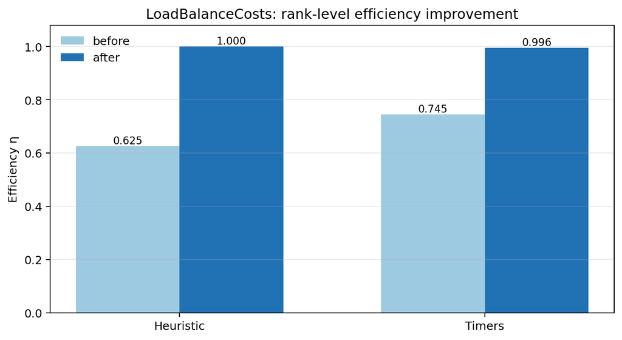

图 8-6 由 `scripts/plot_load_balance_efficiency.py` 从两份 `load-balance-costs.json` 重新生成。

### `ColliderRelevant`：束流统计与 luminosity-rate 聚合合同

`Examples/Tests/collider_relevant_diags/` 提供了另一条强 reduced-diagnostics regression。它在同一 3D、2-rank 输入中同时输出 `ColliderRelevant_beam_e_beam_p`、`ParticleExtrema_beam_e/beam_p` 和 openPMD full state。官方 `analysis.py` 使用输入中的三个解析宏粒子样本，逐项检查每个 beam 的 `chi_min/max/ave`、位置均值/标准差和 `theta_x/theta_y` 的 min/ave/max/std，并把 `ParticleExtrema` 与 `ColliderRelevant` 交叉核对；随后从 `rho_beam_e`、`rho_beam_p` 和粒子电荷重建

$$\frac{dL}{dt}=2c\,\Delta V\sum_i
\frac{\rho_{e,i}}{q_e}\frac{\rho_{p,i}}{q_p}.$$

本地运行归档于 `runs/stage-c-validation/collider_relevant_diags_3d_mpi2/`：两个 openPMD iteration 都得到 `dL/dt = 4.42662301265625e8`，与 reduced text 的对应两行完全一致；`ColliderRelevant` 为 2 行/33 列，两个 `ParticleExtrema` 文件各为 2 行，官方 analysis 与项目内 `scripts/analyze_collider_relevant_contract.py` 均通过。该结果验证的是 collider-oriented quantity 的定义、统计和聚合 writer 合同，不等于已经完成 `diff_lumi_diag` 的解析谱 benchmark，也不等于 `beam_beam_collision` 的 QED 应用级物理复现。

图 8-7 将两个 openPMD iteration 的 `dL/dt` 交叉结果叠加显示。两个 reader-side reconstruction 点与 `ColliderRelevant` reduced 点完全重合，且 JSON 报告给出的相对误差均为 `0`；这张图验证的是聚合定义和 writer/reader 对齐，不是 luminosity 随束流演化的独立动力学 benchmark。

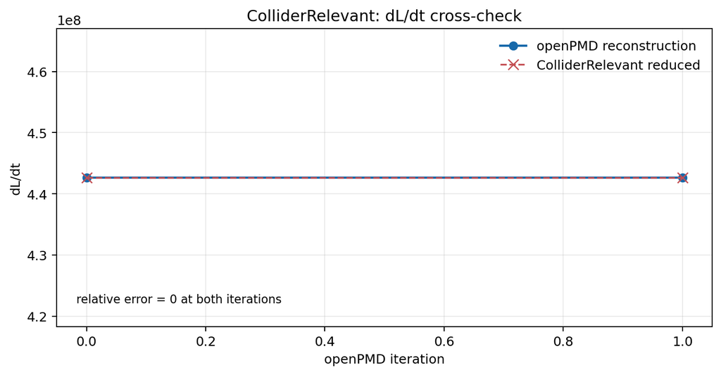

图 8-7 由 `scripts/plot_collider_luminosity_consistency.py` 从 `collider-relevant-contract.json` 重新生成。

### `DifferentialLuminosity`：1D/2D 解析谱与 AMR 对照

`Examples/Tests/diff_lumi_diag/` 把 reduced diagnostics 推进到能量微分 luminosity 的解析 benchmark。共享的 `inputs_base_3d` 设定两束相向高斯束，1D `DifferentialLuminosity` 输出总能量谱，2D `DifferentialLuminosity2D` 输出两个入射束能量的二维网格；官方 `analysis.py` 分别用高斯束解析式比较末态 1D 与 2D 结果。这个分析依赖 `openpmd_viewer` 读取 2D openPMD series，而不是把二维数据误当作普通文本列。

本地按官方 2-rank 配置完成三组 sibling，三组都在 step 80 输出 128 个 1D 能量 bin 和 `128 x 128` 的 2D 网格：

| case | AMR max level | 1D error / tolerance | 2D error / tolerance | result |
| --- | --- | --- | --- | --- |
| leptons | 0 | `0.8903% / 2.0%` | `2.6890% / 4.0%` | `PASS` |
| leptons + AMR | 1 | `0.9796% / 2.0%` | `3.0042% / 4.0%` | `PASS` |
| photons | 0 | `2.0119% / 2.1%` | `4.9327% / 6.0%` | `PASS` |

报告位于 `runs/stage-c-validation/diff_lumi_diag_leptons_mpi2/diff-lumi-contract.md`、`diff_lumi_diag_leptons_mr_mpi2/diff-lumi-contract.md` 和 `diff_lumi_diag_photons_mpi2/diff-lumi-contract.md`，项目脚本为 `scripts/analyze_diff_lumi_contract.py`。这组结果补上了当前束流诊断链中此前缺少的解析谱 physics gate；AMR sibling 的意义是验证中心细化区域仍能保持相同的 reduced luminosity 定义，而不是宣称 AMR 与 uniform-grid 轨迹逐点相同。

图 8-5 将三组 sibling 的 1D/2D 相对误差和各自 gate 并列展示。photons 使用报告中独立的 `2.1%/6.0%` 容差，不能直接套用 leptons 的阈值；三组柱状值均低于对应虚线 gate，图表只表达解析谱误差合同，不把 reduced writer 的文件形状误写成额外物理结论。

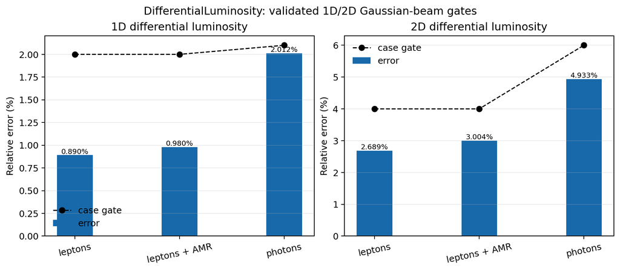

图 8-5 由 `scripts/plot_diff_lumi_errors.py` 从三份 `diff-lumi-contract.json` 重新生成。

### `ParticleHistogram2D`：二维 openPMD writer 合同

当前 checkout 没有单独的 `ParticleHistogram2D` CMake regression；本地采用 `Examples/Physics_applications/laser_ion/` 的官方 2-rank application 作为完整 producer。输入同时配置 `PhaseSpaceIons` 和 `PhaseSpaceElectrons` 两个二维 histogram：两者都使用 `z` 作为 abscissa、`uz` 作为 ordinate、`1000 x 1000` bins、`value_function = w`，而 electrons 还增加 `sqrt(x*x+y*y) < 1e-6` filter。官方 CMake analysis 只负责 time-averaged field 与 instantaneous field 的一致性，因此不能单独被写成 histogram physics gate；项目脚本 `scripts/analyze_particle_histogram2d_contract.py` 对 histogram series 做独立 writer 检查。

本地运行归档于 `runs/stage-c-validation/laser_ion_histogram2d_mpi2/`。两个 series 都写出 `0` 和 `100` 两个 BP5 iteration，数据形状均为 `1000 x 1000`，axis labels 为 `uz/z`，所有数据有限且存在非零 bin；官方 time-average analysis 通过。`PhaseSpaceIons.txt` 与 `PhaseSpaceElectrons.txt` 的大小均为 `0`，这是预期结果：`ParticleHistogram2D::WriteToFile()` 绕过基类逐行文本 writer，直接创建 `reducedfiles/<name>/openpmd_%T.<backend>` series，因此空 `.txt` companion 不能被误判成 histogram 丢失。

这条证据的边界也需要保留：它证明二维 histogram 的配置、openPMD layout、轴元数据和 writer 输出链成立，不等于已经用独立解析分布证明 laser-ion phase-space 的物理收敛性；后者仍需要更高分辨率/粒子数以及针对相空间分布的物理参考结果。

在不改变这条边界的前提下，项目又用 `scripts/analyze_particle_histogram2d_moments.py` 对 BP5 数组做了 reader-side 加权统计。`PhaseSpaceIons` 的总权重从 iteration 0 的 `3.9975794429219594e18` 到 iteration 100 的 `3.997579442921919e18`，相对变化约 `1.0e-14`；`std(z)` 保持在 `1.47204e-6 m`，而 `std(uz)` 从数值零增长到 `4.78558e-4`。受径向 filter 影响的 `PhaseSpaceElectrons` 总权重从 `5.30929e17` 变为 `5.32861e17`，`std(uz)` 从 `0.196998` 变为 `0.199300`。这些统计量把“相空间图发生了什么变化”从视觉判断推进成了可复现的 weighted-moment 摘要，但仍不能替代更高分辨率/粒子数的 convergence study。报告位于 `runs/stage-c-validation/laser_ion_histogram2d_mpi2/particle-histogram2d-moments.{json,md}`。

随后又做了一个匹配物理时间的 producer 对照：baseline 使用 `384x512` 网格、`dt=1.083064693e-16 s`、100 步，refined 使用 `768x1024` 网格、`dt=5.415323467e-17 s`、200 步；两者最终时间差只有 `3.31e-29 s`。`scripts/analyze_particle_histogram2d_resolution.py` 对两个 BP5 series 的总权重、`std(z)` 和 `std(uz)` 设置了 `1e-3/1e-2/5e-2` 的局部稳定性阈值，ions/electrons 均通过：`std(z)` 相对差为 `5.51e-4/2.02e-4`，`std(uz)` 相对差为 `2.04e-3/4.47e-2`。这是“网格加密后 reader-side 加权宽度仍稳定”的项目级证据，不是严格的物理收敛阶证明；两套 producer 都是单进程，运行结束时的 OFI `MPI_Finalize` 环境尾噪声不影响已写出的 BP5 数据读取。

同一脚本还记录了 `1x1` particles-per-cell 的负对照。它的 ions 宽度仍接近 baseline，但 electrons 总权重相对差为 `1.9471e-3`，超过 `1e-3` 阈值，因此 `weighted_width_stability` 被拒绝。这个负结果保留了当前最重要的边界：网格分辨率敏感性已经有局部通过项，粒子数统计收敛仍未完成。完整 JSON/Markdown 产物位于 `runs/stage-c-validation/laser_ion_histogram2d_resolution/`。

为判断该负结果是否只是单个低采样点，又补做了 `1x1/2x2/4x4/8x8` 四档 particles-per-cell 序列，并用 `scripts/analyze_particle_histogram2d_particle_count.py` 做相邻档位比较。`1x1 -> 2x2` 时 electrons 总权重差为 `1.9471e-3`，稳定性 gate 失败；`2x2 -> 4x4` 时降至 `4.2685e-4`，`4x4 -> 8x8` 时进一步降至 `3.6534e-4`，ions/electrons 的总权重、`std(z)`、`std(uz)` 均通过局部阈值。这支持“增加粒子数后该 reader-side 统计总体更稳定”的方向性判断，但它仍是单进程、单一激光离子 case 的局部矩合同，不足以给出正式收敛阶或上游 regression gate。8x8 producer 的 MPI 收尾仍出现本机 OFI `MPI_Finalize` 尾噪声，但 BP5 输出和独立读取均完整；趋势报告位于 `runs/stage-c-validation/laser_ion_histogram2d_resolution/particle-count-trend-8x8.{json,md}`。

图 8-8 直接从 BP5 series 读取 `PhaseSpaceIons` 与 `PhaseSpaceElectrons` 的 iteration 0/100 数据，并按每个面板的非零 bin 裁剪显示范围。它展示的是 writer 实际落盘的 `uz-z` 相空间结构和随 iteration 的变化；由于每个面板使用独立对数颜色归一化，颜色不能用于跨 species 或跨 iteration 的绝对产额比较。完整数组仍为 `1000 x 1000`，空 `.txt` sidecar 也仍是预期的 writer 路径边界。

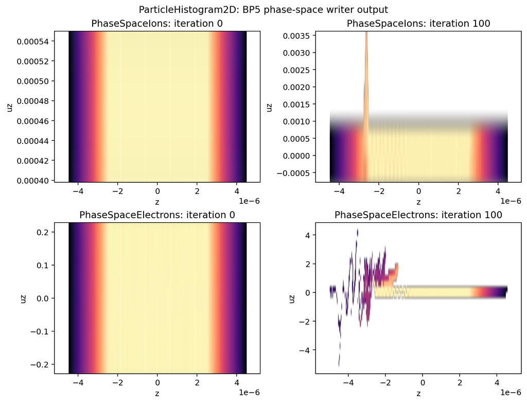

图 8-12 用同一份四档 pairwise contract 把粒子数敏感性归一化到各自局部 gate：虚线是 gate 边界，纵轴小于 1 表示通过。`1x1 -> 2x2` 的电子总权重仍越过边界，`2x2 -> 4x4` 和 `4x4 -> 8x8` 则落在边界以内；因此图支持“采样增加后局部统计趋稳”，但不把单一 case 的 reader-side 矩合同写成正式收敛阶。

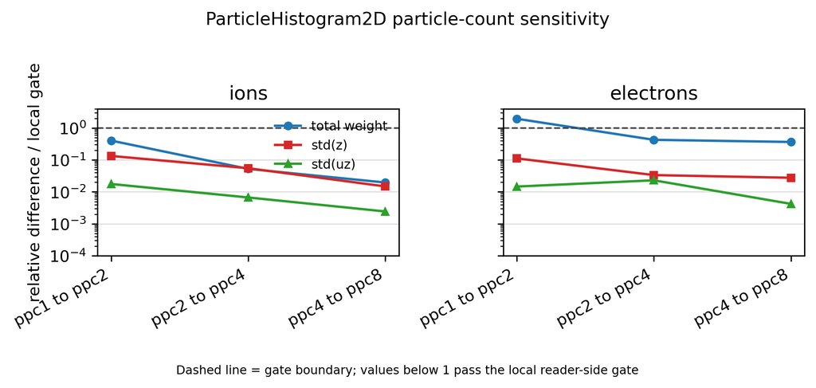

图 8-8 由 `scripts/plot_particle_histogram2d.py` 从 `runs/stage-c-validation/laser_ion_histogram2d_mpi2/` 的 BP5 series 重新生成。

### `BeamRelevant`：束流矩与截断高斯束合同

`BeamRelevant` 是文本型束流诊断，和 `ColliderRelevant` 的逐粒子 `chi/theta` 统计不同。3D 路径固定输出 22 个物理量：位置与动量均值、`gamma` 均值、位置/动量/`gamma` rms、三方向 emittance、Twiss `alpha/beta` 以及总 charge；连同步列和时间列共 24 列。其实现先按粒子权重做并行归约，再从二阶矩构造 rms、emittance 和 Twiss 量，因此最小验证应同时检查 schema、权重聚合和几何分布，而不是只检查文件存在。

本地保留官方 `initial_distribution` 中 `beam` 的参数，构造了只包含该 beam 与 `bmmntr = BeamRelevant` 的 3D、1-rank、`max_step=0` sibling。`scripts/analyze_beam_relevant_contract.py` 对 `bmmntr.txt` 做独立解析：输出为 1 行/24 列；`z_cut=2` 的截断高斯束 charge 期望值为 `-9.544997e-21 C`，实测为 `-9.544980e-21 C`，相对误差 `1.77e-6`；横向 rms 为 `0.249884/0.249765 m`，纵向 rms 为 `0.220356 m`，均通过 `2%` gate；均值、emittance、Twiss 相关输出均有限且满足正值边界。

图 8-9 将这个初始化-only contract 的两个主要物理量画出来：左图是实际总 charge 相对于截断高斯期望值的比值，右图是三个位置 rms 与解析目标的对照。图中没有把单行输出扩展成虚假的时间演化；gamma、emittance 和 Twiss 量仍按报告中的 finite/positive checks 处理。

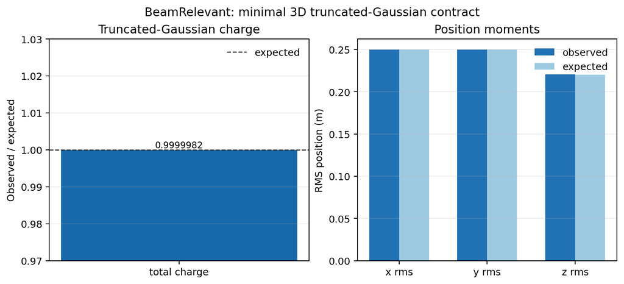

图 8-9 由 `scripts/plot_beam_relevant_contract.py` 从 `beam-relevant-contract.json` 重新生成。

### Native external-file Gaussian beam：输入文件路径与束斑物理合同

`gaussian_beam/CMakeLists.txt` 中的 native `test_3d_focusing_gaussian_beam_from_openpmd` 当前仍引用目录内不存在的 `analysis.py`。项目因此保留官方 registration 缺口，同时直接运行其 prepare 脚本和 native input，使用 1 rank producer 生成 plotfile 与 BP5 openPMD 输出，再用 `scripts/analyze_gaussian_beam_focus_contract.py` 独立读取 iteration 0 的 `x/y/z/w`。

运行结果为 `1,999,966` 个宏粒子、总权重 `1.999966e10`、81 个有效 z slice；按 focal-distance 理论包络计算的最大相对误差为 `sigma_x = 3.0515e-2 < 0.051`、`sigma_y = 3.6214e-2 < 0.038`。官方 `analysis_focusing_beam.py` 也对同一输出正常结束。这个结果补足的是 native external-file 的项目级 physics gate，不应被表述为 WarpX upstream CMake 的 `analysis.py` 已经恢复；其证据目录为 `runs/stage-c-validation/gaussian_beam_native_openpmd/run/`。

图 8-10 直接从同一 BP5 iteration 0 重建每个 z slice 的加权 `sigma_x`、`sigma_y`，并与 focal-distance 理论包络叠加。它展示的是 native external-file producer 的真实粒子输出与理论束斑合同，不是对缺失的 upstream `analysis.py` 的替代提交。

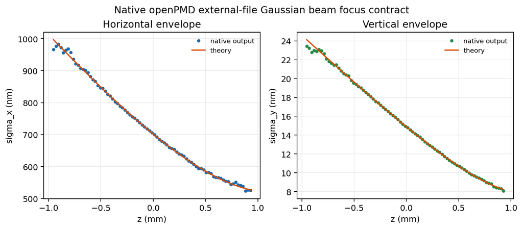

图 8-10 由 `scripts/plot_gaussian_beam_focus_contract.py` 从 `runs/stage-c-validation/gaussian_beam_native_openpmd/run/` 重新生成。

完整官方 `Examples/Tests/initial_distribution/` input 现已用当前 `../warpx` checkout 重建后的 binary 复现。producer 和官方 `analysis.py` 均以 exit code `0` 结束，10 类分布的最大相对差为 `1.8931e-2 < 0.02`。仓库 checksum 默认 `rtol=1e-9` 观察到最大相对差 `3.18e-3`，反映随机采样而非初始化失败；在显式记录的 `rtol=5e-3` sampling tolerance 下通过。因此本项可以从“binary/source mismatch 未完成”升级为“官方分布 analysis 通过、随机 checksum 有条件通过”，但不宣称确定性 `1e-9` checksum 相等。证据目录为 `runs/stage-c-validation/initial_distribution_full_current/`。

### 第 8 章验证矩阵：命令、产物与 gate

本章的运行证据统一遵循同一目录约定：WarpX 原始输入只读复制到 `runs/stage-c-validation/<case>/inputs_test`，运行目录保存完整输出，项目脚本只读取该目录并生成 JSON/Markdown 摘要。下面的 `MPIEXEC`、`WARPX` 和 `PYTHON` 取决于本机环境；本轮实际使用的是 MPICH launcher、`warpx.3d/2d.MPI.OMP.DP.PDP.OPMD.FFT.EB.QED.GENQEDTABLES` 和 Python 环境中的 `yt/openpmd_api/openpmd_viewer`。

| 验证线 | producer / MPI | 项目级复现命令 | 主要 gate | 证据目录 |
| --- | --- | --- | --- | --- |
| Langmuir | 官方 1D，1 rank | `python scripts/analyze_langmuir_frequency_fit.py ...` | 场误差 `1.70e-3`、最终守恒 `8.35e-12`、频率相对误差 `3.595e-4` | `runs/stage-c-validation/langmuir_frequency_fit/` |
| Uniform plasma restart | 官方 3D，2 ranks | `python scripts/analyze_uniform_plasma_restart.py ...` | 37 个 field；最大相对误差 `2.8631e-16 < 1e-12`；checksum 参考另有 rank-specific 差异 | `runs/stage-c-validation/uniform_plasma_3d_mpi2/` |
| Uniform plasma MPI consistency | 官方 3D，1/2 ranks | `python scripts/analyze_uniform_plasma_mpi_consistency.py ...` | 粒子总权重一致；field/particle/total energy 相对差分别为 `1.9379e-2/8.9170e-4/6.2269e-4`；不通过 rank-invariant field gate | `runs/stage-c-validation/uniform_plasma_3d_mpi2/uniform-plasma-mpi-consistency.{json,md}` |
| Energy-conserving thermal plasma | 官方 1D/2D，1 rank | `python scripts/compare_energy_conserving_thermal_plasma_family.py ...` | 共同 `EF+EP` 漂移 `< 0.003` | `runs/stage-c-validation/energy_conserving_thermal_plasma_*` |
| FieldProbe | 官方 coarse/refined，1/2 rank | `python scripts/compare_field_probe_resolution.py ...` | coarse `3.6703%` 失败；matched-time refined `0.3533%` 通过 | `runs/stage-c-validation/field_probe_*` |
| Reduced observables | 官方 3D，2 rank | `python scripts/analyze_reduced_diags_contract.py ...` | 60 项；非 field-energy `<1e-12`，field-energy `<0.3` | `runs/stage-c-validation/reduced_diags_3d_mpi2/` |
| LoadBalanceCosts | Heuristic/Timers，2 rank | `python scripts/analyze_load_balance_costs_contract.py ...` | `eta_after > eta_before` | `runs/stage-c-validation/load_balance_costs_*` |
| ColliderRelevant | 官方 3D，2 rank | `python scripts/analyze_collider_relevant_contract.py ...` | chi/theta/ParticleExtrema 与 `dL/dt` 交叉一致 | `runs/stage-c-validation/collider_relevant_diags_3d_mpi2/` |
| DifferentialLuminosity | leptons/AMR/photons，2 rank | `python scripts/analyze_diff_lumi_contract.py ...` | 1D/2D 高斯束解析谱 gate | `runs/stage-c-validation/diff_lumi_diag_*_mpi2/` |
| ParticleHistogram2D | laser-ion，2 rank | `python scripts/analyze_particle_histogram2d_contract.py ...` | BP5 `0/100`、`1000x1000`、`uz-z`、有限非零数据 | `runs/stage-c-validation/laser_ion_histogram2d_mpi2/` |
| BeamRelevant | 最小 3D，1 rank | `python scripts/analyze_beam_relevant_contract.py ...` | 24 列、截断 Gaussian charge/rms gate | `runs/stage-c-validation/beam_relevant_minimal_mpi1/` |
| Full initial distribution | 官方 3D，1 rank | `PYTHONPATH=.../Tools/PostProcessing python .../initial_distribution/analysis.py` | 10 类分布；最大分析误差 `1.8931e-2 < 0.02`；checksum `rtol=5e-3` 通过 | `runs/stage-c-validation/initial_distribution_full_current/` |
| Native Gaussian external file | gaussian_beam native，1 rank | `python scripts/analyze_gaussian_beam_focus_contract.py ...` | 81 z slices；sigma-x `< 5.1%`、sigma-y `< 3.8%` | `runs/stage-c-validation/gaussian_beam_native_openpmd/run/` |
| RZ electrostatic sphere | 官方 RZ，1 rank | `python scripts/analyze_rz_charge_volume_contract.py ...` | 官方轴向场 L2 gate；全域 rho-volume/particle-charge mismatch `< 1%` | `runs/stage-c-validation/rz_electrostatic_sphere/` |
| RZ Langmuir multimode | case-local RZ sibling，1 rank，3 modes | `python scripts/analyze_rz_langmuir_multimode_contract.py ...` | `m=1/2` 实虚分量非零；theta=0 native-field/writeback reconstruction `< 3.1e-16` | `runs/stage-c-validation/rz_langmuir_multimode/` |

这张表中的“通过”只表示对应列出的 gate 通过。例如 FieldProbe 的 coarse 输入仍然是失败证据，完整 initial-distribution 的随机 checksum 也不等价于确定性 `1e-9` 回归；这样读者可以从同一张表直接区分强 physics analysis、writer/schema contract、性能 gate 和采样统计边界。

当前证据等级应写成：Langmuir 已有运行级解析频率、场误差和最终守恒证据；uniform plasma 已有粒子数、能量统计和 checkpoint/restart 逐字段证据，但短时运行的总能量变化不能直接升级成热平衡守恒通过；FieldProbe 已确认 1/2-rank 输出一致，并通过 `lambda/32` 的 matched-time 解析 gate，但官方 `lambda/16` coarse case 仍失败；`reduced_diags` 已有 60 项 compact observable 与 full-state reference 的 2-rank 逐项通过证据，并有 Heuristic/Timers 两条 `LoadBalanceCosts` efficiency improvement 证据；`ColliderRelevant` 已有 2-rank 的 chi/角度/ParticleExtrema/dL/dt 聚合合同证据；`DifferentialLuminosity` 已有 leptons、AMR 和 photons 三组 1D/2D 解析谱通过证据；laser-ion 已有 `ParticleHistogram2D` 的 2-rank openPMD writer 合同证据；`BeamRelevant` 已有最小 3D 的 schema/截断高斯束统计合同证据；完整 initial-distribution family 已有当前 checkout 的官方分布 analysis 通过证据，并在显式 `5e-3` sampling tolerance 下通过 checksum，但不宣称 `1e-9` 确定性相等；native Gaussian external-file 变体已有 1-rank 项目级束斑物理合同，但官方 CMake analysis 缺失仍保留为 upstream registration 缺口；RZ electrostatic sphere 又补充了官方场/能量 gate 与独立 rho-volume charge closure；RZ 三模 Langmuir sibling 又补充了 `m>0` diagnostics writeback 和 theta=0 重建合同，但它是 project-level case-local evidence，不能替代官方单模 CMake analysis。JSON/Markdown 报告和脚本都保存在项目内，运行产物仍按 case-local 目录归档。

## 8.15 练习与复现实验

1. **证据分层题**：从验证矩阵中各选一个 physics gate、writer/schema contract 和 performance gate，说明它们的 producer、analysis 量和“不能支持的结论”。
2. **reader-side 复现题**：使用 `scripts/analyze_collider_relevant_contract.py` 或 `scripts/analyze_particle_histogram2d_contract.py` 读取一个 case-local 产物，列出输入字段、输出文件和独立检查项。
3. **失败边界题**：解释为什么 FieldProbe coarse failure、uniform-plasma reader-side 能量漂移和 initial-distribution binary mismatch 都应保留在书中，而不能简单从验证矩阵中删除。

## 本章后续扩写

- 加入第 8 章统一验证矩阵，列出 producer/MPI、项目级复现脚本、主要 gate 和 case-local 证据目录。
- 继续把 `ComputeDiagFunctors/`、`ParticleIO`、`WarpXOpenPMD` 和 `FlushFormats/` 的字段计算与 writer 细节拆开。
- 继续把 `FieldProbe`、`ParticleHistogram(2D)`、`LoadBalanceCosts` 这类 reduced diagnostics 的最小输入文件和后处理示例补成可直接运行的小节。
- 延长 uniform plasma 运行窗口，并结合 `energy_conserving_thermal_plasma` 的强 analysis 设计可解释的总能量 gate。
- 为 Langmuir reader-side 拟合补充多模式/不同时间窗的敏感性检查，避免把单一窗口拟合误读为完整色散验证。

# 9. 文献路线与后续扩写计划

本书的文献不是装饰，也不是章节末尾统一贴一串 BibTeX。它真正承担三类职责：

1. 给物理结论提供一手来源。
2. 给数值算法和代码实现提供历史与方法边界。
3. 给 reader-side analysis、benchmark 和 regression 判据提供外部对照。

因此本章不再把文献简单列成“推荐阅读书单”，而是把当前项目里已经 materialize 的论文资产、仍未闭环的 acquisition 缺口，以及它们与各章的绑定关系写成一张可执行路线图。

## 9.1 当前项目的文献证据分层

当前本地文献证据有四层，强度不能混写：

| 层级 | 当前项目中的典型形态 | 可支持的写法 | 当前限制 |
| --- | --- | --- | --- |
| A. 已 materialize 的正文资产 | 本地 PDF + MinerU Markdown + `images/` + 中文讲解 + `reading-log.md` | 可直接作为正文一手证据 | 仍需作者自己对照具体公式、图和段落，而不是只看中文摘要 |
| B. 已取得 PDF 但未完成精读 | 本地 PDF 存在，但还没有完整中文讲解或章节回填 | 可作为“已获取、待精读”的明确线索 | 不能把具体公式或图表当成已核实正文 |
| C. metadata / abstract 级线索 | DOI、题名、摘要、访问审计、下载日志 | 可作为 acquisition 边界、章节缺口或后续计划 | 不能把摘要内容冒充成论文正文结论 |
| D. 旁证或相关文献 | 主题相关但不是当前章的主引用，或并非同一 bibliographic item | 可作背景、旁证、术语线索 | 不能替代主引用本身 |

当前项目的规则应保持为：

- 只有 A 层资产，才允许在正文里写成“已核实的一手证据”。
- B 层资产只能写成“已获取但尚待逐段讲解”。
- C 层和 D 层只能写成 acquisition / 背景边界，不能抬成正文论证。

这条规则尤其影响当前仍未闭环的 `Hockney-Eastwood`、`Yee 1966`、`Esirkepov 2001`、`Villasenor-Buneman 1992` 和 `LeeCPC2015`。

## 9.2 当前已 materialize 的核心文献树

按当前 `references/` 目录，已经完成 materialization 的核心文献主要集中在三条主线。

### 9.2.1 PIC foundations

当前已 materialize：

- `references/02_books_lecture_notes/1985_BirdsallLangdon_Plasma_physics_via_computer_simulation/`
- `references/03_pic_foundations/1979_TajimaDawson_Laser_Electron_Accelerator/`
- `references/03_pic_foundations/1983_Dawson_Particle_simulation_of_plasmas/`

这三条线已经足以支撑：

- 第 1 章的 superparticle、weighted particles、finite-size particles、quiet start、噪声与 heating 讨论；
- 第 2 章的最小 PIC loop、electrostatic / EM / Darwin 模型边界；
- 第 8 章中 diagnostics、spectrum、correlation time、weak instability dynamic range 的讨论；
- LWFA 最早 scaling baseline 的历史入口。

其中 `Birdsall 1985` 因原书过长，当前项目采用分卷 PDF + 分卷 MinerU 的方式处理；这意味着它已经是 A 层资产，但仍不是“整本都已完全精读”。

### 9.2.2 Particle pusher

当前已 materialize：

- `references/04_particle_pushers_deposition_shapes/2008_VayPOP2008_Simulation_of_beams_or_plasmas_crossing_at_relativistic_velocity/`
- `references/04_particle_pushers_deposition_shapes/2017_HigueraPOP2017_Structure-preserving_second-order_integration_of_relativistic_charged_particle_trajectories_in_electromagnetic_fields/`

这两条线当前已经足以支撑：

- 第 4 章对 Vay pusher 与 Higuera-Cary pusher 的源码讲解；
- `Source/Particles/Pusher/UpdateMomentumVay.H` 与 `UpdateMomentumHigueraCary.H` 的公式对表；
- “相对论精度”和“结构保持”两条不同的算法卖点。

但这条模块还没有完成 `Boris` 原始文献闭环，因此第 4 章仍不是“推进器历史谱系全闭环”。

### 9.2.3 PSATD / Galilean / boosted-frame / NCI

当前已 materialize：

- `references/06_stability_filtering_nci/2014_GodfreyJCP2014_Numerical_stability_analysis_of_the_PSATD_PIC_algorithm/`
- `references/06_stability_filtering_nci/2016_KirchenPOP2016_Stable_discrete_representation_of_relativistically_drifting_plasmas/`
- `references/06_stability_filtering_nci/2016_LehePRE2016_Elimination_of_NCI_by_Galilean_coordinates/`

这三条线已经构成第 6 章目前最完整的一组 paper-backed 主干：

- Godfrey 2014：fixed-grid PSATD 的 NCI 策略分类；
- Lehe 2016：Galilean coordinates 消除 NCI 的核心离散论证；
- Kirchen 2016：boosted-frame workflow 与稳定离散表示之间的应用层连接。

因此第 6 章当前虽然仍有 runtime validation 和 upstream handoff 的工程缺口，但在文献层已经不再是空心章节。

## 9.3 当前最突出的未闭环文献缺口

如果按“哪一章会因为缺它而不够出版级”排序，当前最重要的缺口不是更多新论文，而是以下几条老而关键的 primary sources。

| 缺口 | 当前状态 | 主要影响章节 | 当前可替代程度 |
| --- | --- | --- | --- |
| `Hockney-Eastwood` 原书 | 仅有 BibTeX 与 fallback article 线索；无本地合法 PDF | 第 1、2、5、6 章 | 只能部分由 `Birdsall 1985` 与 `Dawson 1983` 顶住 |
| `Yee 1966` | metadata/DOI 已清楚；无本地 PDF/MinerU | 第 2、6 章 | 可暂由源码与后继 FDTD 文献支撑，但缺原始历史入口 |
| `Esirkepov 2001` | 已建立 paper-specific 目录、access audit，并已 materialize 作者 arXiv 预印本 + MinerU + 中文讲解；仍缺出版商 CPC PDF 对照 | 第 5 章 | 已从纯源码缺口推进到 preprint-backed，但还未完成 CPC 定稿核对 |
| `Villasenor-Buneman 1992` | 已建立 paper-specific 目录、access audit，并已 materialize 本机现成 PDF + MinerU + 中文讲解 | 第 5 章 | 已从纯源码缺口推进到 paper-backed，但中文讲解仍是第一轮结构精读 |
| `LeeCPC2015` | 已有 access audit、公式映射准备和核对清单；仍无授权 PDF/MinerU 正文 | 第 7 章 | 源码侧 `C1-C25` 和 regression 可继续推进，但论文闭环仍缺主文 |

这五条缺口里，`LeeCPC2015` 最特殊。它不是完全没工作，而是已经推进到：

- `access-audit.md`
- `公式映射准备.md`
- `公式核对清单.md`

也就是说，当前不是“不知道该怎么读”，而是“知道该对什么，但还拿不到可合法精读的正文 PDF”。

## 9.4 各章当前的文献成熟度

把全书按章节看，当前文献成熟度并不均匀。

| 章节 | 当前文献成熟度 | 主要已闭环来源 | 主要缺口 |
| --- | --- | --- | --- |
| 第 1 章 动理学模型 | 中等 | `Birdsall 1985`、`Dawson 1983` | `Hockney-Eastwood`、更细的 particle-mesh heating 原始文献 |
| 第 2 章 PIC 总循环 | 中等 | `Birdsall 1985`、`Dawson 1983` | `Yee 1966` 原始入口 |
| 第 3/3A 章 主循环与初始化 | 中低 | 以源码为主 | 需要把基础文献和工程论文绑定得更明确 |
| 第 4 章 粒子推进器 | 中高 | `Vay 2008`、`Higuera-Cary 2017` | `Boris` 历史源头仍缺 |
| 第 5 章 沉积与形函数 | 中等 | Esirkepov 与 Villasenor 两条 charge-conserving 主线都已有第一轮 paper-backed 资产 | 仍需把两篇论文系统回写正文；Esirkepov 还缺 CPC 定稿对照 |
| 第 6 章 场求解器 | 高 | `Godfrey 2014`、`Lehe 2016`、`Kirchen 2016` | 更多 validation/engineering 线，而不是 paper 主干 |
| 第 7 章 边界、PML 与 AMR | 中等偏低 | `Berenger 1994/1996` 有 bibliographic anchor，源码和 regression 很强 | `LeeCPC2015` 正文仍缺 |
| 第 8 章 诊断、验证与案例 | 中等 | `Dawson 1983` diagnostics 思路已可直接服务正文 | 还缺更多 case-specific benchmark papers |
| 第 9 章 文献路线 | 本章即路线图 | 当前 `references/` 树和 `docs/literature-map.md` | 需要持续同步，而不是一次性写完 |

## 9.5 acquisition 优先级的重新排序

基于当前项目状态，后续 acquisition 不应再泛泛地“多找一些相关论文”，而应按成书影响排序：

1. `Esirkepov 2001` 的 CPC 定稿 PDF
   - 当前已有作者预印本，可支持第一轮论证；下一步是把预印本与 2001 CPC 发表版逐项对齐。
2. `Yee 1966`
   - 直接补第 2 / 6 章里的原始 FDTD 入口。
3. `LeeCPC2015` 正文 PDF
   - 直接补第 7 章的 PML paper closure。
4. `Hockney-Eastwood` 或其 article-level fallback
   - 继续补第 1 / 2 章的 particle-mesh foundations。
5. `Boris` 原始文献
   - 继续补第 4 章的 pusher 历史链。

这个顺序和早期版本相比已经变了。原因很简单：第 6 章现在已有较强 paper 主干，而第 5 / 7 章的 paper closure 反而更薄。

## 9.6 对 `docs/literature-map.md` 的使用边界

当前 `docs/literature-map.md` 已经不只是“列一下 BibTeX key”，而是承担三种作用：

1. 统计当前本地 PDF / topic 分布；
2. 记录哪些核心文献已经 materialize；
3. 记录哪些缺口当前只有 metadata / audit / fallback。

但它仍然是总索引，不适合直接拿来替代章节级写作清单。章节写作时更合理的做法是：

- 第 1 / 2 章先看 `docs/foundations-literature-list.md`
- 第 6 / 7 章结合 `references/06_stability_filtering_nci/` 与 `references/08_boundaries_pml_geometry/`
- acquisition 计划再回到 `docs/literature-map.md` 和 `references/00_index/books_to_locate.md`

也就是说，`literature-map` 是总表，不是每章的最终操作手册。